# ‘Plastic responses to metal contamination in a multistress context: a field experiment in fish’

### 5.6.8 Refining the model

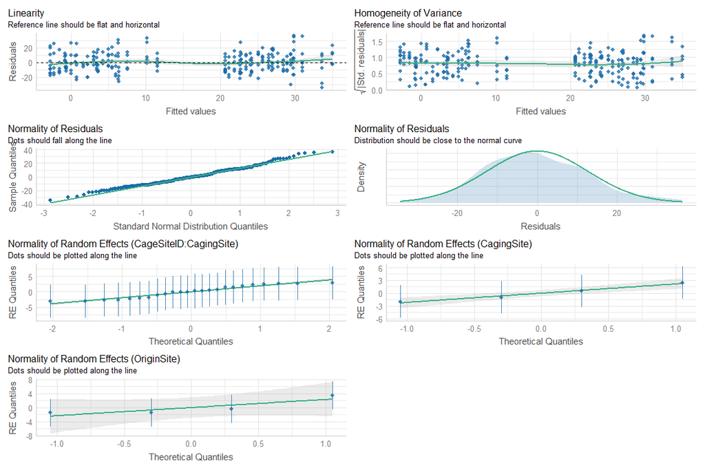

```r
mod6 <-
 lme4::lmer(
    IR ~  Injection +
      (1 | CagingSite /  CageSiteID) + (1| OriginSite),
    data = dat2,
    na.action = na.exclude
  )
performance::check_model(mod6)
```

```r
car::Anova(mod6, type = "3")
```

```
## Analysis of Deviance Table (Type III Wald chisquare tests)
##
## Response: IR
##              Chisq Df Pr(>Chisq)
## (Intercept) 116.67  1  < 2.2e-16 ***
## Injection   198.82  1  < 2.2e-16 ***
## ---
## Signif. codes:  0 '***' 0.001 '**' 0.01 '*' 0.05 '.' 0.1 ' ' 1
```

```r
summary(mod6)
```

```
## Linear mixed model fit by REML ['lmerMod']
## Formula: IR ~ Injection + (1 | CagingSite/CageSiteID) + (1 | OriginSite)
##    Data: dat2
##
## REML criterion at convergence: 1998.1
##
## Scaled residuals:
##     Min      1Q  Median      3Q     Max
## -2.6216 -0.6995 -0.0447  0.6676  2.7812
##
## Random effects:
##  Groups                Name        Variance Std.Dev.
##  CageSiteID:CagingSite (Intercept)  11.357   3.370
##  CagingSite            (Intercept)   7.254   2.693
##  OriginSite            (Intercept)   9.178   3.030
##  Residual                          170.910  13.073
## Number of obs: 249, groups:
## CageSiteID:CagingSite, 24; CagingSite, 4; OriginSite, 4
##
## Fixed effects:
##              Estimate Std. Error t value
## (Intercept)    26.195      2.425    10.8
## InjectionPBS  -23.448      1.663   -14.1
##
## Correlation of Fixed Effects:
##             (Intr)
## InjectinPBS -0.322
```

```r
modIR <- mod6
RmodIR <- MuMIn::r.squaredGLMM(modIR)
```

The immune challenge led to a significant skin swelling, and hence triggered the local immune response.

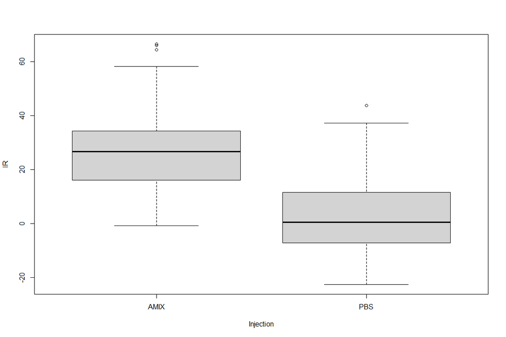

```r
boxplot(IR ~ Injection, data = dat2)
```

```r
# compute mean and Se for LC and HC groups (on raw antioxidant capacity data - not transformed)
meanVal <-
  data.frame(
    mean = c(mean(dat2$IR[which(dat2$Injection == "PBS")]),
             mean(dat2$IR[which(dat2$Injection == "AMIX")])),
    Se = c(
      sd(dat2$IR[which(dat2$Injection == "PBS")]) / sqrt(length(dat2$IR[which(dat2$Injection == "PBS")])),
      sd(dat2$IR[which(dat2$Injection == "AMIX")]) / sqrt(length(dat2$IR[which(dat2$Injection == "AMIX")]))
    ),
    row.names = c("PBS", "AMIX")
  )
kableExtra::kable_classic(
  kableExtra::kbl(meanVal),
  bootstrap_options = c("striped", "hover", "condensed", "responsive"),
  full_width = F,
  html_font = "arial",
  font_size = 10
)
```

|  | mean | Se |
| --- | --- | --- |
| PBS | 2.806122 | 1.288356 |
| AMIX | 26.255052 | 1.214435 |

Now that we have identified the best model, add sex as covariate to check whether results are sensitive NB: sample size is reduced when adding sex variable within the model, for this reason the sex effect on results is checked on the final model

### 5.6.9 Test for the sex effect

```r
dat2 = dat2[is.na(dat2$Sex) == F, ]
modSex <-
 lme4::lmer(
    IR ~ Injection + Sex +
      (1 | CagingSite /  CageSiteID) + (1| OriginSite),
    data = dat2,
    na.action = na.exclude
  )
car::Anova(modSex, type = "3")
```

```
## Analysis of Deviance Table (Type III Wald chisquare tests)
##
## Response: IR
##                Chisq Df Pr(>Chisq)
## (Intercept) 109.9042  1     <2e-16 ***
## Injection   195.5905  1     <2e-16 ***
## Sex           0.0782  1     0.7798
## ---
## Signif. codes:  0 '***' 0.001 '**' 0.01 '*' 0.05 '.' 0.1 ' ' 1
```

```r
summary(modSex)
```

```
## Linear mixed model fit by REML ['lmerMod']
## Formula: IR ~ Injection + Sex + (1 | CagingSite/CageSiteID) + (1 | OriginSite)
##    Data: dat2
##
## REML criterion at convergence: 1979.6
##
## Scaled residuals:
##      Min       1Q   Median       3Q      Max
## -2.62888 -0.68051 -0.04432  0.66882  2.78725
##
## Random effects:
##  Groups                Name        Variance Std.Dev.
##  CageSiteID:CagingSite (Intercept)  12.217   3.495
##  CagingSite            (Intercept)   6.526   2.555
##  OriginSite            (Intercept)   9.260   3.043
##  Residual                          171.764  13.106
## Number of obs: 247, groups:
## CageSiteID:CagingSite, 24; CagingSite, 4; OriginSite, 4
##
## Fixed effects:
##              Estimate Std. Error t value
## (Intercept)   26.3880     2.5171   10.48
## InjectionPBS -23.4780     1.6788  -13.98
## SexM          -0.4957     1.7726   -0.28
##
## Correlation of Fixed Effects:
##             (Intr) InjPBS
## InjectinPBS -0.337
## SexM        -0.295  0.081
```

The sex effect is non-significant. The mod6 is thus the best model. Here, there is no interaction, and hence no posthoc test nor parallelism test to conduct

## 5.7 NL inflammatory Response

### 5.7.1 compute NL ratio

```r
# compute NL ratio
dat2 = dat1[is.na(dat1$Lymphocytes) == F, ]
dat2 = dat2[is.na(dat2$Neutrophils) == F, ]
dat2$NLRatio = dat2$Neutrophils / dat2$Lymphocytes
# transform variable to approx. normality
dat2$NLRatio.p <-
  bimixt::boxcox(dat2$NLRatio + 1, car::powerTransform(dat2$NLRatio + 1)$lambda)
```

### 5.7.2 Visualize

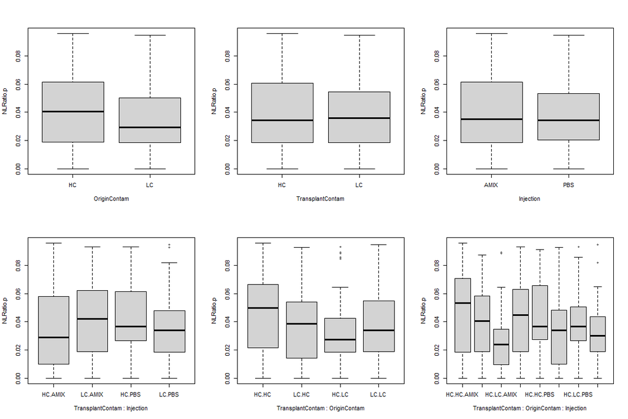

```r
par(mfrow=c(2,3))
boxplot(NLRatio.p ~ OriginContam, data = dat2)
boxplot(NLRatio.p ~ TransplantContam, data = dat2)
boxplot(NLRatio.p ~ Injection, data = dat2)
boxplot(NLRatio.p ~ TransplantContam * Injection, data = dat2)
boxplot(NLRatio.p ~ TransplantContam * OriginContam, data = dat2)
boxplot(NLRatio.p ~ TransplantContam * OriginContam * Injection, data = dat2)
```

### 5.7.3 Build the full model

```r
modfull <-
 lme4::lmer(
    NLRatio.p ~ (TransplantContam + OriginContam + Injection) ^ 3 +  SizeEnd +
      (1 | CagingSite /  CageSiteID) + (1| OriginSite),
    data = dat2,
    na.action = na.exclude
  )
car::Anova(modfull, type = "3")
```

```
## Analysis of Deviance Table (Type III Wald chisquare tests)
##
## Response: NLRatio.p
##                                          Chisq Df Pr(>Chisq)
## (Intercept)                             0.3430  1   0.558086
## TransplantContam                        0.7926  1   0.373303
## OriginContam                            2.7926  1   0.094703 .
## Injection                               0.0309  1   0.860455
## SizeEnd                                 7.0077  1   0.008116 **
## TransplantContam:OriginContam           6.5866  1   0.010275 *
## TransplantContam:Injection              0.1674  1   0.682424
## OriginContam:Injection                  2.1609  1   0.141565
## TransplantContam:OriginContam:Injection 2.0030  1   0.156987
## ---
## Signif. codes:  0 '***' 0.001 '**' 0.01 '*' 0.05 '.' 0.1 ' ' 1
```

```r
summary(modfull)
```

```
## Linear mixed model fit by REML ['lmerMod']
## Formula: NLRatio.p ~ (TransplantContam + OriginContam + Injection)^3 +
##     SizeEnd + (1 | CagingSite/CageSiteID) + (1 | OriginSite)
##    Data: dat2
##
## REML criterion at convergence: -977.9
##
## Scaled residuals:
##      Min       1Q   Median       3Q      Max
## -2.37113 -0.70032 -0.04037  0.62365  2.54298
##
## Random effects:
##  Groups                Name        Variance  Std.Dev.
##  CageSiteID:CagingSite (Intercept) 1.114e-05 3.337e-03
##  CagingSite            (Intercept) 1.699e-12 1.304e-06
##  OriginSite            (Intercept) 5.993e-05 7.742e-03
##  Residual                          5.743e-04 2.396e-02
## Number of obs: 229, groups:
## CageSiteID:CagingSite, 24; CagingSite, 4; OriginSite, 4
##
## Fixed effects:
##                                                 Estimate Std. Error t value
## (Intercept)                                     0.008906   0.015206   0.586
## TransplantContamLC                             -0.005651   0.006348  -0.890
## OriginContamLC                                 -0.016786   0.010045  -1.671
## InjectionPBS                                   -0.001071   0.006094  -0.176
## SizeEnd                                         0.003564   0.001346   2.647
## TransplantContamLC:OriginContamLC               0.023390   0.009114   2.566
## TransplantContamLC:InjectionPBS                -0.003557   0.008693  -0.409
## OriginContamLC:InjectionPBS                     0.013173   0.008961   1.470
## TransplantContamLC:OriginContamLC:InjectionPBS -0.018051   0.012754  -1.415
##
## Correlation of Fixed Effects:
##             (Intr) TrnCLC OrgCLC InjPBS SizEnd TrCLC:OCLC TCLC:I OCLC:I
## TrnsplntCLC -0.227
## OrignCntmLC -0.343  0.312
## InjectinPBS -0.195  0.464  0.294
## SizeEnd     -0.886  0.024  0.018  0.001
## TrnCLC:OCLC  0.121 -0.695 -0.446 -0.323  0.026
## TrnCLC:IPBS  0.131 -0.662 -0.205 -0.701  0.005  0.461
## OrgCLC:IPBS  0.135 -0.316 -0.412 -0.680 -0.003  0.454      0.476
## TCLC:OCLC:I -0.097  0.451  0.289  0.477  0.005 -0.650     -0.682 -0.702
## optimizer (nloptwrap) convergence code: 0 (OK)
## boundary (singular) fit: see ?isSingular
```

### 5.7.4 Refining the model

```r
mod2 <-
 lme4::lmer(
    NLRatio.p ~ (TransplantContam + OriginContam + Injection) ^ 2  +  SizeEnd +
      (1 | CagingSite /  CageSiteID) + (1| OriginSite),
    data = dat2,
    na.action = na.exclude
  )
car::Anova(mod2, type = "3")
```

```
## Analysis of Deviance Table (Type III Wald chisquare tests)
##
## Response: NLRatio.p
##                                Chisq Df Pr(>Chisq)
## (Intercept)                   0.1801  1   0.671308
## TransplantContam              0.0842  1   0.771721
## OriginContam                  1.8013  1   0.179559
## Injection                     0.3106  1   0.577334
## SizeEnd                       7.2018  1   0.007283 **
## TransplantContam:OriginContam 4.9634  1   0.025889 *
## TransplantContam:Injection    3.4759  1   0.062269 .
## OriginContam:Injection        0.4586  1   0.498268
## ---
## Signif. codes:  0 '***' 0.001 '**' 0.01 '*' 0.05 '.' 0.1 ' ' 1
```

```r
summary(mod2)
```

```
## Linear mixed model fit by REML ['lmerMod']
## Formula: NLRatio.p ~ (TransplantContam + OriginContam + Injection)^2 +
##     SizeEnd + (1 | CagingSite/CageSiteID) + (1 | OriginSite)
##    Data: dat2
##
## REML criterion at convergence: -982.8
##
## Scaled residuals:
##      Min       1Q   Median       3Q      Max
## -2.44899 -0.72905 -0.04652  0.62828  2.62195
##
## Random effects:
##  Groups                Name        Variance  Std.Dev.
##  CageSiteID:CagingSite (Intercept) 7.200e-06 0.002683
##  CagingSite            (Intercept) 0.000e+00 0.000000
##  OriginSite            (Intercept) 5.874e-05 0.007664
##  Residual                          5.797e-04 0.024077
## Number of obs: 229, groups:
## CageSiteID:CagingSite, 24; CagingSite, 4; OriginSite, 4
##
## Fixed effects:
##                                    Estimate Std. Error t value
## (Intercept)                        0.006413   0.015112   0.424
## TransplantContamLC                -0.001616   0.005570  -0.290
## OriginContamLC                    -0.012745   0.009497  -1.342
## InjectionPBS                       0.002997   0.005378   0.557
## SizeEnd                            0.003617   0.001348   2.684
## TransplantContamLC:OriginContamLC  0.015062   0.006761   2.228
## TransplantContamLC:InjectionPBS   -0.011911   0.006389  -1.864
## OriginContamLC:InjectionPBS        0.004340   0.006409   0.677
##
## Correlation of Fixed Effects:
##             (Intr) TrnCLC OrgCLC InjPBS SizEnd TCLC:O TCLC:I
## TrnsplntCLC -0.204
## OrignCntmLC -0.327  0.207
## InjectinPBS -0.171  0.324  0.188
## SizeEnd     -0.892  0.025  0.018 -0.001
## TrnCLC:OCLC  0.073 -0.588 -0.350 -0.020  0.039
## TrnCLC:IPBS  0.089 -0.554 -0.011 -0.583  0.012  0.033
## OrgCLC:IPBS  0.095  0.002 -0.312 -0.551  0.000 -0.004 -0.004
## optimizer (nloptwrap) convergence code: 0 (OK)
## boundary (singular) fit: see ?isSingular
```

### 5.7.5 Refining the model

```r
mod3 <-
 lme4::lmer(
    NLRatio.p ~ (TransplantContam + OriginContam) ^ 2 + (TransplantContam + Injection) ^ 2 + SizeEnd +
      (1 | CagingSite /  CageSiteID) + (1| OriginSite),
    data = dat2,
    na.action = na.exclude
  )
car::Anova(mod3, type = "3")
```

```
## Analysis of Deviance Table (Type III Wald chisquare tests)
##
## Response: NLRatio.p
##                                Chisq Df Pr(>Chisq)
## (Intercept)                   0.1401  1   0.708140
## TransplantContam              0.0832  1   0.772984
## OriginContam                  1.3888  1   0.238601
## Injection                     1.2517  1   0.263235
## SizeEnd                       7.1261  1   0.007597 **
## TransplantContam:OriginContam 4.8805  1   0.027162 *
## TransplantContam:Injection    3.4859  1   0.061893 .
## ---
## Signif. codes:  0 '***' 0.001 '**' 0.01 '*' 0.05 '.' 0.1 ' ' 1
```

```r
summary(mod3)
```

```
## Linear mixed model fit by REML ['lmerMod']
## Formula: NLRatio.p ~ (TransplantContam + OriginContam)^2 + (TransplantContam +
##     Injection)^2 + SizeEnd + (1 | CagingSite/CageSiteID) + (1 |
##     OriginSite)
##    Data: dat2
##
## REML criterion at convergence: -990.6
##
## Scaled residuals:
##      Min       1Q   Median       3Q      Max
## -2.49767 -0.71902 -0.08241  0.62687  2.58596
##
## Random effects:
##  Groups                Name        Variance  Std.Dev.
##  CageSiteID:CagingSite (Intercept) 8.585e-06 0.002930
##  CagingSite            (Intercept) 0.000e+00 0.000000
##  OriginSite            (Intercept) 5.974e-05 0.007729
##  Residual                          5.772e-04 0.024026
## Number of obs: 229, groups:
## CageSiteID:CagingSite, 24; CagingSite, 4; OriginSite, 4
##
## Fixed effects:
##                                    Estimate Std. Error t value
## (Intercept)                        0.005638   0.015062   0.374
## TransplantContamLC                -0.001616   0.005601  -0.288
## OriginContamLC                    -0.010722   0.009098  -1.178
## InjectionPBS                       0.005011   0.004479   1.119
## SizeEnd                            0.003597   0.001347   2.669
## TransplantContamLC:OriginContamLC  0.015060   0.006817   2.209
## TransplantContamLC:InjectionPBS   -0.011904   0.006376  -1.867
##
## Correlation of Fixed Effects:
##             (Intr) TrnCLC OrgCLC InjPBS SizEnd TCLC:O
## TrnsplntCLC -0.206
## OrignCntmLC -0.317  0.220
## InjectinPBS -0.143  0.387  0.020
## SizeEnd     -0.894  0.025  0.019 -0.001
## TrnCLC:OCLC  0.074 -0.590 -0.370 -0.026  0.039
## TrnCLC:IPBS  0.090 -0.550 -0.013 -0.702  0.012  0.033
## optimizer (nloptwrap) convergence code: 0 (OK)
## boundary (singular) fit: see ?isSingular
```

### 5.7.6 Refining the model

```r
mod4 <-
 lme4::lmer(
    NLRatio.p ~ (TransplantContam + OriginContam) ^ 2 + Injection + SizeEnd +
      (1 | CagingSite /  CageSiteID) + (1| OriginSite),
    data = dat2,
    na.action = na.exclude
  )
car::Anova(mod4, type = "3")
```

```
## Analysis of Deviance Table (Type III Wald chisquare tests)
##
## Response: NLRatio.p
##                                Chisq Df Pr(>Chisq)
## (Intercept)                   0.2773  1   0.598502
## TransplantContam              2.5359  1   0.111286
## OriginContam                  1.4604  1   0.226867
## Injection                     0.0717  1   0.788917
## SizeEnd                       7.2706  1   0.007009 **
## TransplantContam:OriginContam 5.2920  1   0.021424 *
## ---
## Signif. codes:  0 '***' 0.001 '**' 0.01 '*' 0.05 '.' 0.1 ' ' 1
```

```r
summary(mod4)
```

```
## Linear mixed model fit by REML ['lmerMod']
## Formula: NLRatio.p ~ (TransplantContam + OriginContam)^2 + Injection +
##     SizeEnd + (1 | CagingSite/CageSiteID) + (1 | OriginSite)
##    Data: dat2
##
## REML criterion at convergence: -995.4
##
## Scaled residuals:
##      Min       1Q   Median       3Q      Max
## -2.36244 -0.75384 -0.03035  0.63291  2.44956
##
## Random effects:
##  Groups                Name        Variance  Std.Dev.
##  CageSiteID:CagingSite (Intercept) 6.332e-06 0.002516
##  CagingSite            (Intercept) 0.000e+00 0.000000
##  OriginSite            (Intercept) 5.984e-05 0.007736
##  Residual                          5.853e-04 0.024194
## Number of obs: 229, groups:
## CageSiteID:CagingSite, 24; CagingSite, 4; OriginSite, 4
##
## Fixed effects:
##                                     Estimate Std. Error t value
## (Intercept)                        0.0079284  0.0150571   0.527
## TransplantContamLC                -0.0073654  0.0046252  -1.592
## OriginContamLC                    -0.0109687  0.0090765  -1.208
## InjectionPBS                      -0.0008599  0.0032118  -0.268
## SizeEnd                            0.0036515  0.0013542   2.696
## TransplantContamLC:OriginContamLC  0.0155111  0.0067427   2.300
##
## Correlation of Fixed Effects:
##             (Intr) TrnCLC OrgCLC InjPBS SizEnd
## TrnsplntCLC -0.186
## OrignCntmLC -0.315  0.252
## InjectinPBS -0.113  0.001  0.015
## SizeEnd     -0.900  0.038  0.020  0.010
## TrnCLC:OCLC  0.070 -0.683 -0.367 -0.004  0.039
## optimizer (nloptwrap) convergence code: 0 (OK)
## boundary (singular) fit: see ?isSingular
```

### 5.7.7 Refining the model

```r
mod5 <-
 lme4::lmer(
    NLRatio.p ~ (TransplantContam + OriginContam) ^ 2  + SizeEnd +
      (1 | CagingSite /  CageSiteID) + (1| OriginSite),
    data = dat2,
    na.action = na.exclude
  )
car::Anova(mod5, type = "3")
```

```
## Analysis of Deviance Table (Type III Wald chisquare tests)
##
## Response: NLRatio.p
##                                Chisq Df Pr(>Chisq)
## (Intercept)                   0.2548  1   0.613743
## TransplantContam              2.5332  1   0.111473
## OriginContam                  1.4435  1   0.229574
## SizeEnd                       7.2813  1   0.006967 **
## TransplantContam:OriginContam 5.2818  1   0.021550 *
## ---
## Signif. codes:  0 '***' 0.001 '**' 0.01 '*' 0.05 '.' 0.1 ' ' 1
```

```r
summary(mod5)
```

```
## Linear mixed model fit by REML ['lmerMod']
## Formula: NLRatio.p ~ (TransplantContam + OriginContam)^2 + SizeEnd + (1 |
##     CagingSite/CageSiteID) + (1 | OriginSite)
##    Data: dat2
##
## REML criterion at convergence: -1005
##
## Scaled residuals:
##      Min       1Q   Median       3Q      Max
## -2.38697 -0.74246 -0.04835  0.65242  2.43644
##
## Random effects:
##  Groups                Name        Variance  Std.Dev.
##  CageSiteID:CagingSite (Intercept) 6.626e-06 0.002574
##  CagingSite            (Intercept) 0.000e+00 0.000000
##  OriginSite            (Intercept) 6.021e-05 0.007760
##  Residual                          5.826e-04 0.024138
## Number of obs: 229, groups:
## CageSiteID:CagingSite, 24; CagingSite, 4; OriginSite, 4
##
## Fixed effects:
##                                    Estimate Std. Error t value
## (Intercept)                        0.007545   0.014947   0.505
## TransplantContamLC                -0.007363   0.004626  -1.592
## OriginContamLC                    -0.010929   0.009096  -1.201
## SizeEnd                            0.003648   0.001352   2.698
## TransplantContamLC:OriginContamLC  0.015498   0.006743   2.298
##
## Correlation of Fixed Effects:
##             (Intr) TrnCLC OrgCLC SizEnd
## TrnsplntCLC -0.187
## OrignCntmLC -0.317  0.251
## SizeEnd     -0.904  0.038  0.019
## TrnCLC:OCLC  0.070 -0.684 -0.366  0.039
## optimizer (nloptwrap) convergence code: 0 (OK)
## boundary (singular) fit: see ?isSingular
```

```r
modNLRatio.p <- mod5
RmodNLRatio.p  <- MuMIn::r.squaredGLMM(modNLRatio.p )
```

Here, the interactions between fish origin and the transplant site are significant. Also, the bigger the fish, the higher the NL ratio and hence the immune inflammatory response.

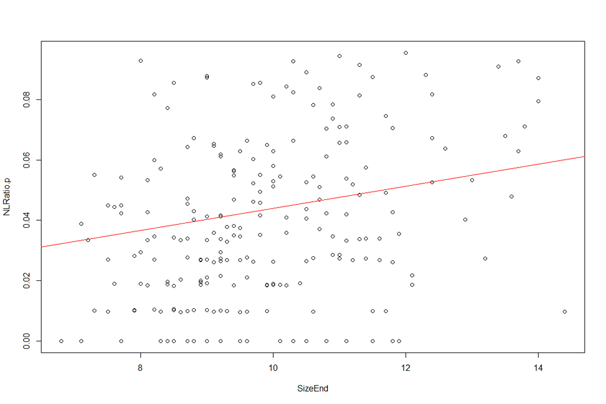

```r
# check the relationships between th NlRatio and fish size
plot(NLRatio.p ~  SizeEnd, data = dat2)
abline(a = 0.007545 , b =  0.003648 , col = "red")
```

Now that we have identified the best model, add sex as covariate to check whether results are sensitive NB: sample size is reduced when adding sex variable within the model, for this reason the sex effect on results is checked on the final model

### 5.7.8 Test for the sex effect

```r
dat2 = dat2[is.na(dat2$Sex) == F, ]
 modSex <-
 lme4::lmer(
    NLRatio.p ~ (TransplantContam + OriginContam) ^ 2  + SizeEnd + Sex +
      (1 | CagingSite /  CageSiteID) + (1| OriginSite),
    data = dat2,
    na.action = na.exclude
  )
car::Anova(modSex, type = "3")
```

```
## Analysis of Deviance Table (Type III Wald chisquare tests)
##
## Response: NLRatio.p
##                                Chisq Df Pr(>Chisq)
## (Intercept)                   0.2193  1   0.639579
## TransplantContam              2.3167  1   0.127989
## OriginContam                  1.4037  1   0.236111
## SizeEnd                       7.7020  1   0.005516 **
## Sex                           0.4454  1   0.504542
## TransplantContam:OriginContam 4.9488  1   0.026109 *
## ---
## Signif. codes:  0 '***' 0.001 '**' 0.01 '*' 0.05 '.' 0.1 ' ' 1
```

```r
summary(modSex)
```

```
## Linear mixed model fit by REML ['lmerMod']
## Formula: NLRatio.p ~ (TransplantContam + OriginContam)^2 + SizeEnd + Sex +
##     (1 | CagingSite/CageSiteID) + (1 | OriginSite)
##    Data: dat2
##
## REML criterion at convergence: -990.4
##
## Scaled residuals:
##      Min       1Q   Median       3Q      Max
## -2.33274 -0.75679 -0.06933  0.65173  2.47006
##
## Random effects:
##  Groups                Name        Variance  Std.Dev.
##  CageSiteID:CagingSite (Intercept) 5.147e-06 0.002269
##  CagingSite            (Intercept) 0.000e+00 0.000000
##  OriginSite            (Intercept) 5.835e-05 0.007639
##  Residual                          5.877e-04 0.024242
## Number of obs: 228, groups:
## CageSiteID:CagingSite, 24; CagingSite, 4; OriginSite, 4
##
## Fixed effects:
##                                    Estimate Std. Error t value
## (Intercept)                        0.006994   0.014934   0.468
## TransplantContamLC                -0.007028   0.004617  -1.522
## OriginContamLC                    -0.010650   0.008989  -1.185
## SizeEnd                            0.003779   0.001362   2.775
## SexM                              -0.002234   0.003347  -0.667
## TransplantContamLC:OriginContamLC  0.014984   0.006735   2.225
##
## Correlation of Fixed Effects:
##             (Intr) TrnCLC OrgCLC SizEnd SexM
## TrnsplntCLC -0.187
## OrignCntmLC -0.314  0.253
## SizeEnd     -0.904  0.050  0.023
## SexM         0.020 -0.109 -0.024 -0.105
## TrnCLC:OCLC  0.071 -0.684 -0.371  0.028  0.086
## optimizer (nloptwrap) convergence code: 0 (OK)
## boundary (singular) fit: see ?isSingular
```

Adding the sex as covariate does no change the significance of the interactions, also sex effect is non-significant. The mod5 is thus the best model.

### 5.7.9 Posthoc test (pairwise t-test)

The interactions between fish origin and the transplant site are significant. Hence, perform posthoc test (pairwise t-test) according to significant interactions.

```r
pairwise.t.test(dat2$NLRatio.p, dat2$CxO2, p.adjust.method = "fdr")
```

```
##
##  Pairwise comparisons using t tests with pooled SD
##
## data:  dat2$NLRatio.p and dat2$CxO2
##
##       HC_HC HC_LC LC_HC
## HC_LC 0.074 -     -
## LC_HC 0.219 0.529 -
## LC_LC 0.402 0.351 0.531
##
## P value adjustment method: fdr
```

Here fish from LC sites, have a marginally lower NL ratio than fish from HC site when transplanted in HC site. However, the posthoc are mostly non-significant.

Also,because interaction between the contamination in origin and transplant site of fish is significant We test for parallel response between replicate populations.

### 5.7.10 Test for parallel responses between replicate populations (from the same origin)

#### 5.7.10.1 For Populations from High contamination sites (AUSCOR and RIOU)

```r
dat3 <- dat2[which(dat2$OriginSite %in% c("AUSCOR", "RIOU")),]
## build the null model
mod.null <-
  glm(NLRatio.p ~ TransplantContam + OriginSite,
      data = dat3)
## build the model with the site of origin in interaction with the level of contam in transplant sites
mod.par <-
  glm(NLRatio.p ~ TransplantContam * OriginSite,
      data = dat3)

anova(mod.null, mod.par, test = "LRT")
```

```
## Analysis of Deviance Table
##
## Model 1: NLRatio.p ~ TransplantContam + OriginSite
## Model 2: NLRatio.p ~ TransplantContam * OriginSite
##   Resid. Df Resid. Dev Df   Deviance Pr(>Chi)
## 1       119   0.065380
## 2       118   0.065355  1 2.5656e-05   0.8296
```

```r
coef(mod.par)
```

```
##                       (Intercept)                TransplantContamLC
##                       0.032098642                      -0.008723136
##                    OriginSiteRIOU TransplantContamLC:OriginSiteRIOU
##                       0.023609057                       0.001839351
```

```r
summary(mod.par)
```

```
##
## Call:
## glm(formula = NLRatio.p ~ TransplantContam * OriginSite, data = dat3)
##
## Deviance Residuals:
##       Min         1Q     Median         3Q        Max
## -0.055708  -0.021626   0.000688   0.017677   0.058384
##
## Coefficients:
##                                    Estimate Std. Error t value Pr(>|t|)
## (Intercept)                        0.032099   0.004448   7.217 5.57e-11 ***
## TransplantContamLC                -0.008723   0.006235  -1.399 0.164438
## OriginSiteRIOU                     0.023609   0.006006   3.931 0.000143 ***
## TransplantContamLC:OriginSiteRIOU  0.001839   0.008546   0.215 0.829961
## ---
## Signif. codes:  0 '***' 0.001 '**' 0.01 '*' 0.05 '.' 0.1 ' ' 1
##
## (Dispersion parameter for gaussian family taken to be 0.0005538531)
##
##     Null deviance: 0.085831  on 121  degrees of freedom
## Residual deviance: 0.065355  on 118  degrees of freedom
## AIC: -562.68
##
## Number of Fisher Scoring iterations: 2
```

The null model and the model including the site of origin in interaction with the level of contaminant in transplant sites are not significantly different, we hence cannot reject the null hypothesis: the slopes of HC populations are parallel.

#### 5.7.10.2 For Populations from Low contamination sites (ARIMAS and CELFIG)

```r
# We test for parallel response between replicate LC populations (ARIMAS and CELFIG)
dat4 <- dat2[which(dat2$OriginSite %in% c("ARIMAS", "CELFIG")),]
## build the null model
mod.null <-
  glm(NLRatio.p ~ TransplantContam + OriginSite,
      data = dat4)
## build the model with the site of origin in interaction with the level of contam in transplant sites
mod.par <-
  glm(NLRatio.p ~ TransplantContam * OriginSite,
      data = dat4)

anova(mod.null, mod.par, test = "LRT")
```

```
## Analysis of Deviance Table
##
## Model 1: NLRatio.p ~ TransplantContam + OriginSite
## Model 2: NLRatio.p ~ TransplantContam * OriginSite
##   Resid. Df Resid. Dev Df   Deviance Pr(>Chi)
## 1       103   0.067919
## 2       102   0.067880  1 3.8896e-05    0.809
```

```r
coef(mod.par)
```

```
##                         (Intercept)                  TransplantContamLC
##                         0.035659899                         0.008085113
##                    OriginSiteCELFIG TransplantContamLC:OriginSiteCELFIG
##                        -0.005996004                        -0.002423457
```

```r
summary(mod.par)
```

```
##
## Call:
## glm(formula = NLRatio.p ~ TransplantContam * OriginSite, data = dat4)
##
## Deviance Residuals:
##       Min         1Q     Median         3Q        Max
## -0.043745  -0.017240  -0.002768   0.012915   0.057600
##
## Coefficients:
##                                      Estimate Std. Error t value Pr(>|t|)
## (Intercept)                          0.035660   0.004965   7.183 1.15e-10 ***
## TransplantContamLC                   0.008085   0.007021   1.152    0.252
## OriginSiteCELFIG                    -0.005996   0.007088  -0.846    0.400
## TransplantContamLC:OriginSiteCELFIG -0.002423   0.010024  -0.242    0.809
## ---
## Signif. codes:  0 '***' 0.001 '**' 0.01 '*' 0.05 '.' 0.1 ' ' 1
##
## (Dispersion parameter for gaussian family taken to be 0.0006654894)
##
##     Null deviance: 0.070555  on 105  degrees of freedom
## Residual deviance: 0.067880  on 102  degrees of freedom
## AIC: -468.65
##
## Number of Fisher Scoring iterations: 2
```

The null model and the model including the site of origin in interaction with the level of contaminant in transplant sites are not significantly different, we hence cannot reject the null hypothesis: the slopes of LC populations are parallel.

### 5.7.11 Visualize

The plot reported below correspond to the figure 2C from the manuscript

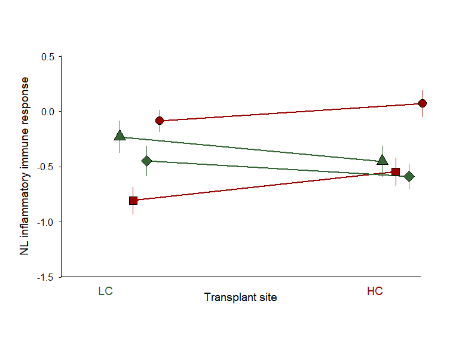

```r
NLratioPlot1()
```

## 5.8 Available energy - Index (sum of lipids, proteins and carbohydrates)

### 5.8.1 Check the data

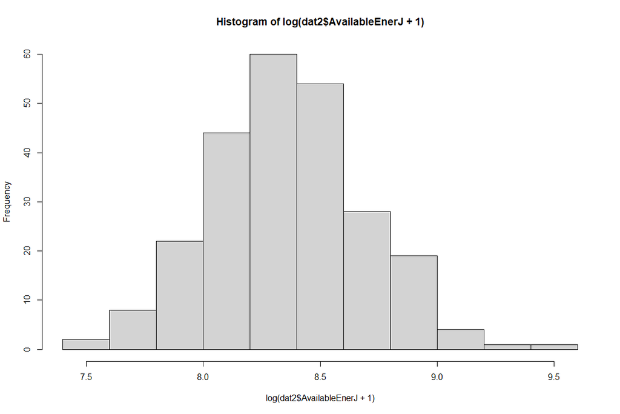

```r
dat2 = dat1[is.na(dat1$AvailableEnerJ) == F, ]
hist(log(dat2$AvailableEnerJ + 1))
```

### 5.8.2 Visualize

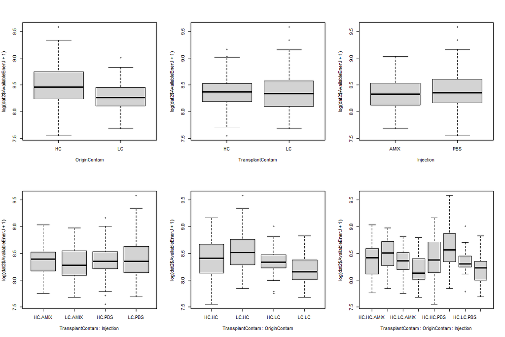

```r
par(mfrow=c(2,3))
boxplot(log(dat2$AvailableEnerJ + 1) ~ OriginContam, data = dat2)
boxplot(log(dat2$AvailableEnerJ + 1) ~ TransplantContam, data = dat2)
boxplot(log(dat2$AvailableEnerJ + 1) ~ Injection, data = dat2)
boxplot(log(dat2$AvailableEnerJ + 1) ~ TransplantContam * Injection, data = dat2)
boxplot(log(dat2$AvailableEnerJ + 1) ~ TransplantContam * OriginContam, data = dat2)
boxplot(log(dat2$AvailableEnerJ + 1) ~ TransplantContam * OriginContam * Injection, data = dat2)
```

### 5.8.3 Build the full model

```r
modfull <-
 lme4::lmer(
    log(dat2$AvailableEnerJ + 1) ~ (TransplantContam + OriginContam + Injection) ^ 3 +  SizeEnd +
      (1 | CagingSite /  CageSiteID) + (1| OriginSite),
    data = dat2,
    na.action = na.exclude
  )
car::Anova(modfull, type = "3")
```

```
## Analysis of Deviance Table (Type III Wald chisquare tests)
##
## Response: log(dat2$AvailableEnerJ + 1)
##                                             Chisq Df Pr(>Chisq)
## (Intercept)                             1877.0660  1    < 2e-16 ***
## TransplantContam                           0.8135  1    0.36709
## OriginContam                               0.1111  1    0.73890
## Injection                                  0.0048  1    0.94484
## SizeEnd                                    0.2945  1    0.58737
## TransplantContam:OriginContam              5.6046  1    0.01791 *
## TransplantContam:Injection                 1.2846  1    0.25705
## OriginContam:Injection                     0.0026  1    0.95910
## TransplantContam:OriginContam:Injection    0.3734  1    0.54115
## ---
## Signif. codes:  0 '***' 0.001 '**' 0.01 '*' 0.05 '.' 0.1 ' ' 1
```

```r
summary(modfull)
```

```
## Linear mixed model fit by REML ['lmerMod']
## Formula: log(dat2$AvailableEnerJ + 1) ~ (TransplantContam + OriginContam +
##     Injection)^3 + SizeEnd + (1 | CagingSite/CageSiteID) + (1 |
##     OriginSite)
##    Data: dat2
##
## REML criterion at convergence: 140.9
##
## Scaled residuals:
##     Min      1Q  Median      3Q     Max
## -3.1265 -0.5752 -0.0303  0.7151  3.1968
##
## Random effects:
##  Groups                Name        Variance  Std.Dev.
##  CageSiteID:CagingSite (Intercept) 6.604e-11 8.127e-06
##  CagingSite            (Intercept) 4.647e-03 6.817e-02
##  OriginSite            (Intercept) 8.682e-03 9.318e-02
##  Residual                          9.059e-02 3.010e-01
## Number of obs: 243, groups:
## CageSiteID:CagingSite, 24; CagingSite, 4; OriginSite, 4
##
## Fixed effects:
##                                                 Estimate Std. Error t value
## (Intercept)                                     8.294203   0.191441  43.325
## TransplantContamLC                              0.092137   0.102154   0.902
## OriginContamLC                                 -0.040483   0.121459  -0.333
## InjectionPBS                                   -0.005424   0.078395  -0.069
## SizeEnd                                         0.008824   0.016261   0.543
## TransplantContamLC:OriginContamLC              -0.253471   0.107067  -2.367
## TransplantContamLC:InjectionPBS                 0.122759   0.108310   1.133
## OriginContamLC:InjectionPBS                     0.005768   0.112469   0.051
## TransplantContamLC:OriginContamLC:InjectionPBS -0.094713   0.154994  -0.611
##
## Correlation of Fixed Effects:
##             (Intr) TrnCLC OrgCLC InjPBS SizEnd TrCLC:OCLC TCLC:I OCLC:I
## TrnsplntCLC -0.311
## OrignCntmLC -0.348  0.245
## InjectinPBS -0.213  0.377  0.317
## SizeEnd     -0.858  0.044  0.036  0.013
## TrnCLC:OCLC  0.135 -0.527 -0.465 -0.359  0.015
## TrnCLC:IPBS  0.143 -0.521 -0.229 -0.724  0.003  0.497
## OrgCLC:IPBS  0.145 -0.263 -0.442 -0.697 -0.006  0.501      0.504
## TCLC:OCLC:I -0.097  0.364  0.320  0.506 -0.005 -0.690     -0.699 -0.726
## optimizer (nloptwrap) convergence code: 0 (OK)
## boundary (singular) fit: see ?isSingular
```

### 5.8.4 Refining the model

```r
mod2 <-
 lme4::lmer(
    log(dat2$AvailableEnerJ + 1) ~ (TransplantContam + OriginContam + Injection) ^ 2  +  SizeEnd +
      (1 | CagingSite /  CageSiteID) + (1| OriginSite),
    data = dat2,
    na.action = na.exclude
  )
car::Anova(mod2, type = "3")
```

```
## Analysis of Deviance Table (Type III Wald chisquare tests)
##
## Response: log(dat2$AvailableEnerJ + 1)
##                                   Chisq Df Pr(>Chisq)
## (Intercept)                   1895.3183  1  < 2.2e-16 ***
## TransplantContam                 1.4584  1  0.2271831
## OriginContam                     0.0212  1  0.8843552
## Injection                        0.0775  1  0.7806793
## SizeEnd                          0.2929  1  0.5883630
## TransplantContam:OriginContam   14.8819  1  0.0001145 ***
## TransplantContam:Injection       0.9777  1  0.3227703
## OriginContam:Injection           0.3257  1  0.5682284
## ---
## Signif. codes:  0 '***' 0.001 '**' 0.01 '*' 0.05 '.' 0.1 ' ' 1
```

```r
summary(mod2)
```

```
## Linear mixed model fit by REML ['lmerMod']
## Formula: log(dat2$AvailableEnerJ + 1) ~ (TransplantContam + OriginContam +
##     Injection)^2 + SizeEnd + (1 | CagingSite/CageSiteID) + (1 |
##     OriginSite)
##    Data: dat2
##
## REML criterion at convergence: 139.4
##
## Scaled residuals:
##     Min      1Q  Median      3Q     Max
## -3.1704 -0.5721 -0.0226  0.7025  3.2394
##
## Random effects:
##  Groups                Name        Variance Std.Dev.
##  CageSiteID:CagingSite (Intercept) 0.000000 0.00000
##  CagingSite            (Intercept) 0.004647 0.06817
##  OriginSite            (Intercept) 0.008634 0.09292
##  Residual                          0.090348 0.30058
## Number of obs: 243, groups:
## CageSiteID:CagingSite, 24; CagingSite, 4; OriginSite, 4
##
## Fixed effects:
##                                    Estimate Std. Error t value
## (Intercept)                        8.282686   0.190252  43.535
## TransplantContamLC                 0.114845   0.095098   1.208
## OriginContamLC                    -0.016697   0.114795  -0.145
## InjectionPBS                       0.018805   0.067539   0.278
## SizeEnd                            0.008788   0.016237   0.541
## TransplantContamLC:OriginContamLC -0.298608   0.077406  -3.858
## TransplantContamLC:InjectionPBS    0.076508   0.077376   0.989
## OriginContamLC:InjectionPBS       -0.044103   0.077283  -0.571
##
## Correlation of Fixed Effects:
##             (Intr) TrnCLC OrgCLC InjPBS SizEnd TCLC:O TCLC:I
## TrnsplntCLC -0.298
## OrignCntmLC -0.336  0.146
## InjectinPBS -0.191  0.241  0.190
## SizeEnd     -0.862  0.050  0.040  0.019
## TrnCLC:OCLC  0.094 -0.409 -0.356 -0.017  0.016
## TrnCLC:IPBS  0.105 -0.400 -0.008 -0.600 -0.001  0.029
## OrgCLC:IPBS  0.109  0.002 -0.322 -0.556 -0.014  0.001 -0.005
## optimizer (nloptwrap) convergence code: 0 (OK)
## boundary (singular) fit: see ?isSingular
```

### 5.8.5 Refining the model

```r
mod3 <-
 lme4::lmer(
    log(dat2$AvailableEnerJ + 1) ~ (TransplantContam + OriginContam) ^ 2 + Injection + SizeEnd +
      (1 | CagingSite /  CageSiteID) + (1| OriginSite),
    data = dat2,
    na.action = na.exclude
  )
car::Anova(mod3, type = "3")
```

```
## Analysis of Deviance Table (Type III Wald chisquare tests)
##
## Response: log(dat2$AvailableEnerJ + 1)
##                                   Chisq Df Pr(>Chisq)
## (Intercept)                   1941.0315  1  < 2.2e-16 ***
## TransplantContam                 3.0309  1    0.08169 .
## OriginContam                     0.1145  1    0.73503
## Injection                        0.9462  1    0.33070
## SizeEnd                          0.2887  1    0.59106
## TransplantContam:OriginContam   15.1597  1  9.879e-05 ***
## ---
## Signif. codes:  0 '***' 0.001 '**' 0.01 '*' 0.05 '.' 0.1 ' ' 1
```

```r
summary(mod3)
```

```
## Linear mixed model fit by REML ['lmerMod']
## Formula: log(dat2$AvailableEnerJ + 1) ~ (TransplantContam + OriginContam)^2 +
##     Injection + SizeEnd + (1 | CagingSite/CageSiteID) + (1 |      OriginSite)
##    Data: dat2
##
## REML criterion at convergence: 134.1
##
## Scaled residuals:
##     Min      1Q  Median      3Q     Max
## -3.2055 -0.6493 -0.0609  0.6893  3.3458
##
## Random effects:
##  Groups                Name        Variance  Std.Dev.
##  CageSiteID:CagingSite (Intercept) 1.076e-08 0.0001037
##  CagingSite            (Intercept) 4.724e-03 0.0687319
##  OriginSite            (Intercept) 8.570e-03 0.0925770
##  Residual                          9.007e-02 0.3001240
## Number of obs: 243, groups:
## CageSiteID:CagingSite, 24; CagingSite, 4; OriginSite, 4
##
## Fixed effects:
##                                    Estimate Std. Error t value
## (Intercept)                        8.274302   0.187808  44.057
## TransplantContamLC                 0.152433   0.087558   1.741
## OriginContamLC                    -0.036669   0.108346  -0.338
## InjectionPBS                       0.037525   0.038578   0.973
## SizeEnd                            0.008708   0.016208   0.537
## TransplantContamLC:OriginContamLC -0.300800   0.077256  -3.894
##
## Correlation of Fixed Effects:
##             (Intr) TrnCLC OrgCLC InjPBS SizEnd
## TrnsplntCLC -0.283
## OrignCntmLC -0.320  0.164
## InjectinPBS -0.117  0.001  0.010
## SizeEnd     -0.871  0.053  0.037  0.019
## TrnCLC:OCLC  0.092 -0.431 -0.376  0.003  0.016
```

### 5.8.6 Refining the model

```r
mod4 <-
 lme4::lmer(
    log(dat2$AvailableEnerJ + 1) ~ (TransplantContam + OriginContam) ^ 2 +
      (1 | CagingSite /  CageSiteID) + (1| OriginSite),
    data = dat2,
    na.action = na.exclude
  )
car::Anova(mod4, type = "3")
```

```
## Analysis of Deviance Table (Type III Wald chisquare tests)
##
## Response: log(dat2$AvailableEnerJ + 1)
##                                   Chisq Df Pr(>Chisq)
## (Intercept)                   7672.7861  1  < 2.2e-16 ***
## TransplantContam                 2.9297  1    0.08697 .
## OriginContam                     0.1164  1    0.73292
## TransplantContam:OriginContam   15.3300  1  9.027e-05 ***
## ---
## Signif. codes:  0 '***' 0.001 '**' 0.01 '*' 0.05 '.' 0.1 ' ' 1
```

```r
summary(mod4)
```

```
## Linear mixed model fit by REML ['lmerMod']
## Formula: log(dat2$AvailableEnerJ + 1) ~ (TransplantContam + OriginContam)^2 +
##     (1 | CagingSite/CageSiteID) + (1 | OriginSite)
##    Data: dat2
##
## REML criterion at convergence: 124.2
##
## Scaled residuals:
##     Min      1Q  Median      3Q     Max
## -3.0982 -0.6056 -0.0182  0.6854  3.3961
##
## Random effects:
##  Groups                Name        Variance  Std.Dev.
##  CageSiteID:CagingSite (Intercept) 1.186e-09 3.444e-05
##  CagingSite            (Intercept) 4.786e-03 6.918e-02
##  OriginSite            (Intercept) 1.047e-02 1.023e-01
##  Residual                          8.965e-02 2.994e-01
## Number of obs: 243, groups:
## CageSiteID:CagingSite, 24; CagingSite, 4; OriginSite, 4
##
## Fixed effects:
##                                   Estimate Std. Error t value
## (Intercept)                        8.38025    0.09567  87.594
## TransplantContamLC                 0.15013    0.08771   1.712
## OriginContamLC                    -0.03980    0.11663  -0.341
## TransplantContamLC:OriginContamLC -0.30173    0.07706  -3.915
##
## Correlation of Fixed Effects:
##             (Intr) TrnCLC OrgCLC
## TrnsplntCLC -0.467
## OrignCntmLC -0.606  0.149
## TrnCLC:OCLC  0.207 -0.430 -0.349
```

```r
modAvailableEnerJ <- mod4
RmodAvailableEnerJ  <- MuMIn::r.squaredGLMM(modAvailableEnerJ)
```

Here, the interactions between fish origin and the transplant site are significant.

Now that we have identified the best model, add sex as covariate to check whether results are sensitive NB: sample size is reduced when adding sex variable within the model, for this reason the sex effect on results is checked on the final model

### 5.8.7 Test for the sex effect

```r
dat2 = dat2[is.na(dat2$Sex) == F, ]
 modSex <-
 lme4::lmer(
    log(dat2$AvailableEnerJ + 1) ~ (TransplantContam + OriginContam) ^ 2  + Sex +
      (1 | CagingSite /  CageSiteID) + (1| OriginSite),
    data = dat2,
    na.action = na.exclude
  )
car::Anova(modSex, type = "3")
```

```
## Analysis of Deviance Table (Type III Wald chisquare tests)
##
## Response: log(dat2$AvailableEnerJ + 1)
##                                   Chisq Df Pr(>Chisq)
## (Intercept)                   7513.2256  1  < 2.2e-16 ***
## TransplantContam                 2.8305  1  0.0924909 .
## OriginContam                     0.1612  1  0.6880167
## Sex                              0.2442  1  0.6211753
## TransplantContam:OriginContam   14.7641  1  0.0001218 ***
## ---
## Signif. codes:  0 '***' 0.001 '**' 0.01 '*' 0.05 '.' 0.1 ' ' 1
```

```r
summary(modSex)
```

```
## Linear mixed model fit by REML ['lmerMod']
## Formula: log(dat2$AvailableEnerJ + 1) ~ (TransplantContam + OriginContam)^2 +
##     Sex + (1 | CagingSite/CageSiteID) + (1 | OriginSite)
##    Data: dat2
##
## REML criterion at convergence: 126.8
##
## Scaled residuals:
##     Min      1Q  Median      3Q     Max
## -3.1252 -0.5996 -0.0031  0.6878  3.3782
##
## Random effects:
##  Groups                Name        Variance  Std.Dev.
##  CageSiteID:CagingSite (Intercept) 5.742e-11 7.577e-06
##  CagingSite            (Intercept) 5.320e-03 7.294e-02
##  OriginSite            (Intercept) 9.999e-03 1.000e-01
##  Residual                          8.942e-02 2.990e-01
## Number of obs: 242, groups:
## CageSiteID:CagingSite, 24; CagingSite, 4; OriginSite, 4
##
## Fixed effects:
##                                   Estimate Std. Error t value
## (Intercept)                        8.38668    0.09676  86.679
## TransplantContamLC                 0.15276    0.09080   1.682
## OriginContamLC                    -0.04607    0.11472  -0.402
## SexM                              -0.01974    0.03994  -0.494
## TransplantContamLC:OriginContamLC -0.29793    0.07754  -3.842
##
## Correlation of Fixed Effects:
##             (Intr) TrnCLC OrgCLC SexM
## TrnsplntCLC -0.468
## OrignCntmLC -0.584  0.148
## SexM        -0.138 -0.055 -0.024
## TrnCLC:OCLC  0.189 -0.418 -0.357  0.101
## optimizer (nloptwrap) convergence code: 0 (OK)
## boundary (singular) fit: see ?isSingular
```

### 5.8.8 Posthoc test (pairwise t-test)

The interactions between fish origin and the transplant site are significant. Hence, perform posthoc test (pairwise t-test) according to significant interactions.

```r
pairwise.t.test(log(dat2$AvailableEnerJ + 1), dat2$CxO2, p.adjust.method = "fdr")
```

```
##
##  Pairwise comparisons using t tests with pooled SD
##
## data:  log(dat2$AvailableEnerJ + 1) and dat2$CxO2
##
##       HC_HC  HC_LC  LC_HC
## HC_LC 0.3430 -      -
## LC_HC 0.0150 0.0012 -
## LC_LC 0.0012 0.0150 1.3e-08
##
## P value adjustment method: fdr
```

Here the available energy increases in LC fish when transplanted in HC sites. Similarly, the available energy increases in HC fish when transplanted in LC sites, suggesting that local condition within each study site could have driven the plastic responses rather than the level of contamination.

Also,because interaction between the contamination in origin and transplant site of fish is significant We test for parallel response between replicate populations.

### 5.8.9 Test for parallel responses between replicate populations (from the same origin)

#### 5.8.9.1 For Populations from High contamination sites (AUSCOR and RIOU)

```r
dat3 <- dat2[which(dat2$OriginSite %in% c("AUSCOR", "RIOU")),]
## build the null model
mod.null <-
  glm(log(dat3$AvailableEnerJ + 1) ~ TransplantContam + OriginSite,
      data = dat3)
## build the model with the site of origin in interaction with the level of contam in transplant sites
mod.par <-
  glm(log(dat3$AvailableEnerJ + 1) ~ TransplantContam * OriginSite,
      data = dat3)

anova(mod.null, mod.par, test = "LRT")
```

```
## Analysis of Deviance Table
##
## Model 1: log(dat3$AvailableEnerJ + 1) ~ TransplantContam + OriginSite
## Model 2: log(dat3$AvailableEnerJ + 1) ~ TransplantContam * OriginSite
##   Resid. Df Resid. Dev Df Deviance Pr(>Chi)
## 1       121     14.959
## 2       120     14.684  1  0.27469   0.1341
```

```r
coef(mod.par)
```

```
##                       (Intercept)                TransplantContamLC
##                         8.2574774                         0.2463168
##                    OriginSiteRIOU TransplantContamLC:OriginSiteRIOU
##                         0.2419375                        -0.1888528
```

```r
summary(mod.par)
```

```
##
## Call:
## glm(formula = log(dat3$AvailableEnerJ + 1) ~ TransplantContam *
##     OriginSite, data = dat3)
##
## Deviance Residuals:
##      Min        1Q    Median        3Q       Max
## -0.94707  -0.21939   0.00947   0.22058   1.01919
##
## Coefficients:
##                                   Estimate Std. Error t value Pr(>|t|)
## (Intercept)                        8.25748    0.06732 122.657  < 2e-16 ***
## TransplantContamLC                 0.24632    0.09078   2.713  0.00764 **
## OriginSiteRIOU                     0.24194    0.09141   2.647  0.00922 **
## TransplantContamLC:OriginSiteRIOU -0.18885    0.12605  -1.498  0.13670
## ---
## Signif. codes:  0 '***' 0.001 '**' 0.01 '*' 0.05 '.' 0.1 ' ' 1
##
## (Dispersion parameter for gaussian family taken to be 0.1223704)
##
##     Null deviance: 16.204  on 123  degrees of freedom
## Residual deviance: 14.684  on 120  degrees of freedom
## AIC: 97.344
##
## Number of Fisher Scoring iterations: 2
```

The null model and the model including the site of origin in interaction with the level of contaminant in transplant sites are not significantly different, we hence cannot reject the null hypothesis: the slopes of HC populations are parallel.

#### 5.8.9.2 For Populations from Low contamination sites (ARIMAS and CELFIG)

```r
# We test for parallel response between replicate LC populations (ARIMAS and CELFIG)
dat4 <- dat2[which(dat2$OriginSite %in% c("ARIMAS", "CELFIG")),]
## build the null model
mod.null <-
  glm(log(dat4$AvailableEnerJ + 1) ~ TransplantContam + OriginSite,
      data = dat4)
## build the model with the site of origin in interaction with the level of contam in transplant sites
mod.par <-
  glm(log(dat4$AvailableEnerJ + 1) ~ TransplantContam * OriginSite,
      data = dat4)

anova(mod.null, mod.par, test = "LRT")
```

```
## Analysis of Deviance Table
##
## Model 1: log(dat4$AvailableEnerJ + 1) ~ TransplantContam + OriginSite
## Model 2: log(dat4$AvailableEnerJ + 1) ~ TransplantContam * OriginSite
##   Resid. Df Resid. Dev Df Deviance Pr(>Chi)
## 1       115     6.5419
## 2       114     6.2558  1  0.28616   0.0224 *
## ---
## Signif. codes:  0 '***' 0.001 '**' 0.01 '*' 0.05 '.' 0.1 ' ' 1
```

```r
coef(mod.par)
```

```
##                         (Intercept)                  TransplantContamLC
##                          8.34886418                         -0.04548398
##                    OriginSiteCELFIG TransplantContamLC:OriginSiteCELFIG
##                         -0.03205983                         -0.19760377
```

```r
summary(mod.par)
```

```
##
## Call:
## glm(formula = log(dat4$AvailableEnerJ + 1) ~ TransplantContam *
##     OriginSite, data = dat4)
##
## Deviance Residuals:
##      Min        1Q    Median        3Q       Max
## -0.61943  -0.13182  -0.00938   0.16106   0.66008
##
## Coefficients:
##                                     Estimate Std. Error t value Pr(>|t|)
## (Intercept)                          8.34886    0.04350 191.928   <2e-16 ***
## TransplantContamLC                  -0.04548    0.06006  -0.757   0.4504
## OriginSiteCELFIG                    -0.03206    0.06327  -0.507   0.6133
## TransplantContamLC:OriginSiteCELFIG -0.19760    0.08653  -2.284   0.0242 *
## ---
## Signif. codes:  0 '***' 0.001 '**' 0.01 '*' 0.05 '.' 0.1 ' ' 1
##
## (Dispersion parameter for gaussian family taken to be 0.05487516)
##
##     Null deviance: 7.7037  on 117  degrees of freedom
## Residual deviance: 6.2558  on 114  degrees of freedom
## AIC: -1.7178
##
## Number of Fisher Scoring iterations: 2
```

The null model and the model including the site of origin in interaction with the level of contaminant in transplant sites are significantly different, we hence reject the null hypothesis. here, the slopes of LC populations are not parallel.

### 5.8.10 Visualize

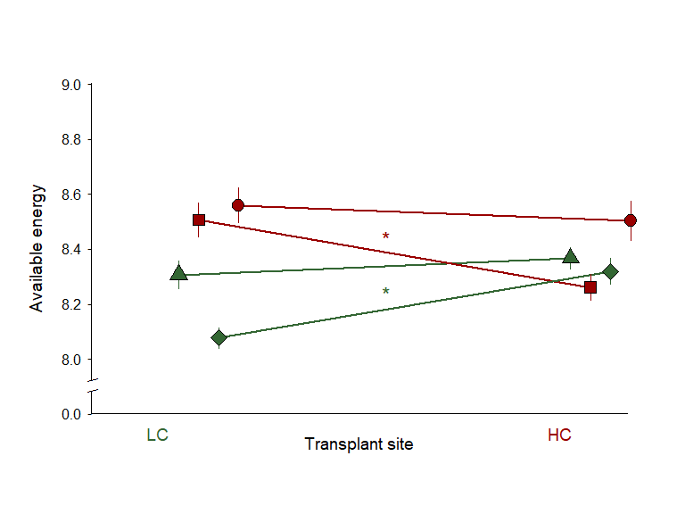

```r
AvailEnerPlot1()
```

## 5.9 Available energy - Lipids

### 5.9.1 Check the data

```r
dat2 = dat1[is.na(dat1$AvailableEnerJ) == F, ]
# transform variable to approx. normality
dat2$MuscleLipid.p <-
  bimixt::boxcox(dat2$MuscleLipid, car::powerTransform(dat2$MuscleLipid)$lambda)
```

### 5.9.2 Visualize

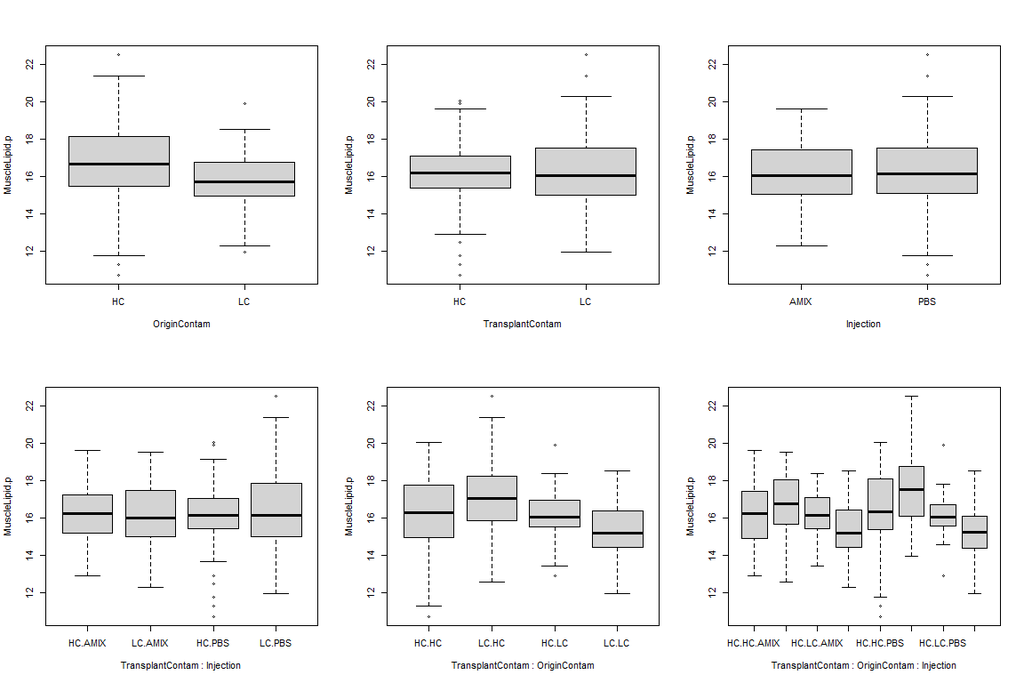

```r
par(mfrow=c(2,3))
boxplot(MuscleLipid.p  ~ OriginContam, data = dat2)
boxplot(MuscleLipid.p  ~ TransplantContam, data = dat2)
boxplot(MuscleLipid.p  ~ Injection, data = dat2)
boxplot(MuscleLipid.p  ~ TransplantContam * Injection, data = dat2)
boxplot(MuscleLipid.p  ~ TransplantContam * OriginContam, data = dat2)
boxplot(MuscleLipid.p  ~ TransplantContam * OriginContam * Injection, data = dat2)
```

### 5.9.3 Build the full model

```r
modfull <-
 lme4::lmer(
    MuscleLipid.p ~ (TransplantContam + OriginContam + Injection) ^ 3 +  SizeEnd +
      (1 | CagingSite /  CageSiteID) + (1| OriginSite),
    data = dat2,
    na.action = na.exclude
  )
car::Anova(modfull, type = "3")
```

```
## Analysis of Deviance Table (Type III Wald chisquare tests)
##
## Response: MuscleLipid.p
##                                            Chisq Df Pr(>Chisq)
## (Intercept)                             239.7471  1    < 2e-16 ***
## TransplantContam                          0.8741  1    0.34983
## OriginContam                              0.0301  1    0.86220
## Injection                                 0.1457  1    0.70266
## SizeEnd                                   0.5445  1    0.46058
## TransplantContam:OriginContam             4.7471  1    0.02935 *
## TransplantContam:Injection                2.1557  1    0.14204
## OriginContam:Injection                    0.0222  1    0.88161
## TransplantContam:OriginContam:Injection   1.3112  1    0.25218
## ---
## Signif. codes:  0 '***' 0.001 '**' 0.01 '*' 0.05 '.' 0.1 ' ' 1
```

```r
summary(modfull)
```

```
## Linear mixed model fit by REML ['lmerMod']
## Formula: MuscleLipid.p ~ (TransplantContam + OriginContam + Injection)^3 +
##     SizeEnd + (1 | CagingSite/CageSiteID) + (1 | OriginSite)
##    Data: dat2
##
## REML criterion at convergence: 945.4
##
## Scaled residuals:
##     Min      1Q  Median      3Q     Max
## -3.3883 -0.5605  0.0452  0.6799  3.0051
##
## Random effects:
##  Groups                Name        Variance Std.Dev.
##  CageSiteID:CagingSite (Intercept) 0.0000   0.0000
##  CagingSite            (Intercept) 0.1360   0.3688
##  OriginSite            (Intercept) 0.1395   0.3735
##  Residual                          2.8308   1.6825
## Number of obs: 243, groups:
## CageSiteID:CagingSite, 24; CagingSite, 4; OriginSite, 4
##
## Fixed effects:
##                                                Estimate Std. Error t value
## (Intercept)                                    15.62969    1.00942  15.484
## TransplantContamLC                              0.52629    0.56293   0.935
## OriginContamLC                                 -0.09958    0.57370  -0.174
## InjectionPBS                                   -0.16728    0.43822  -0.382
## SizeEnd                                         0.06477    0.08778   0.738
## TransplantContamLC:OriginContamLC              -1.30400    0.59850  -2.179
## TransplantContamLC:InjectionPBS                 0.88893    0.60544   1.468
## OriginContamLC:InjectionPBS                     0.09364    0.62870   0.149
## TransplantContamLC:OriginContamLC:InjectionPBS -0.99210    0.86641  -1.145
##
## Correlation of Fixed Effects:
##             (Intr) TrnCLC OrgCLC InjPBS SizEnd TrCLC:OCLC TCLC:I OCLC:I
## TrnsplntCLC -0.324
## OrignCntmLC -0.320  0.295
## InjectinPBS -0.224  0.383  0.375
## SizeEnd     -0.879  0.044  0.041  0.012
## TrnCLC:OCLC  0.143 -0.535 -0.550 -0.359  0.015
## TrnCLC:IPBS  0.150 -0.528 -0.271 -0.724  0.005  0.497
## OrgCLC:IPBS  0.153 -0.267 -0.523 -0.697 -0.005  0.501      0.504
## TCLC:OCLC:I -0.102  0.369  0.379  0.506 -0.007 -0.690     -0.699 -0.726
## optimizer (nloptwrap) convergence code: 0 (OK)
## boundary (singular) fit: see ?isSingular
```

### 5.9.4 Refining the model

```r
mod2 <-
 lme4::lmer(
     MuscleLipid.p ~ (TransplantContam + OriginContam + Injection) ^ 2 +  SizeEnd +
      (1 | CagingSite /  CageSiteID) + (1| OriginSite),
    data = dat2,
    na.action = na.exclude
  )
car::Anova(mod2, type = "3")
```

```
## Analysis of Deviance Table (Type III Wald chisquare tests)
##
## Response: MuscleLipid.p
##                                  Chisq Df Pr(>Chisq)
## (Intercept)                   238.8706  1  < 2.2e-16 ***
## TransplantContam                2.1314  1     0.1443
## OriginContam                    0.0801  1     0.7772
## Injection                       0.0523  1     0.8190
## SizeEnd                         0.5432  1     0.4611
## TransplantContam:OriginContam  16.7946  1  4.165e-05 ***
## TransplantContam:Injection      0.8709  1     0.3507
## OriginContam:Injection          0.9810  1     0.3220
## ---
## Signif. codes:  0 '***' 0.001 '**' 0.01 '*' 0.05 '.' 0.1 ' ' 1
```

```r
summary(mod2)
```

```
## Linear mixed model fit by REML ['lmerMod']
## Formula: MuscleLipid.p ~ (TransplantContam + OriginContam + Injection)^2 +
##     SizeEnd + (1 | CagingSite/CageSiteID) + (1 | OriginSite)
##    Data: dat2
##
## REML criterion at convergence: 948.3
##
## Scaled residuals:
##     Min      1Q  Median      3Q     Max
## -3.4605 -0.5650  0.0736  0.6661  3.0749
##
## Random effects:
##  Groups                Name        Variance  Std.Dev.
##  CageSiteID:CagingSite (Intercept) 3.336e-09 5.776e-05
##  CagingSite            (Intercept) 1.360e-01 3.688e-01
##  OriginSite            (Intercept) 1.370e-01 3.702e-01
##  Residual                          2.835e+00 1.684e+00
## Number of obs: 243, groups:
## CageSiteID:CagingSite, 24; CagingSite, 4; OriginSite, 4
##
## Fixed effects:
##                                   Estimate Std. Error t value
## (Intercept)                       15.50634    1.00329  15.455
## TransplantContamLC                 0.76417    0.52343   1.460
## OriginContamLC                     0.14962    0.52872   0.283
## InjectionPBS                       0.08655    0.37831   0.229
## SizeEnd                            0.06466    0.08773   0.737
## TransplantContamLC:OriginContamLC -1.77675    0.43355  -4.098
## TransplantContamLC:InjectionPBS    0.40446    0.43341   0.933
## OriginContamLC:InjectionPBS       -0.42876    0.43290  -0.990
##
## Correlation of Fixed Effects:
##             (Intr) TrnCLC OrgCLC InjPBS SizEnd TCLC:O TCLC:I
## TrnsplntCLC -0.311
## OrignCntmLC -0.305  0.181
## InjectinPBS -0.201  0.245  0.231
## SizeEnd     -0.884  0.050  0.047  0.018
## TrnCLC:OCLC  0.102 -0.416 -0.433 -0.017  0.014
## TrnCLC:IPBS  0.111 -0.407 -0.009 -0.600  0.001  0.029
## OrgCLC:IPBS  0.116  0.002 -0.391 -0.556 -0.015  0.001 -0.005
## optimizer (nloptwrap) convergence code: 0 (OK)
## boundary (singular) fit: see ?isSingular
```

### 5.9.5 Refining the model

```r
mod3 <-
 lme4::lmer(
    MuscleLipid.p ~ (TransplantContam + OriginContam) ^ 2 + Injection +  SizeEnd +
      (1 | CagingSite /  CageSiteID) + (1| OriginSite),
    data = dat2,
    na.action = na.exclude
  )
car::Anova(mod3, type = "3")
```

```
## Analysis of Deviance Table (Type III Wald chisquare tests)
##
## Response: MuscleLipid.p
##                                  Chisq Df Pr(>Chisq)
## (Intercept)                   245.6390  1  < 2.2e-16 ***
## TransplantContam                4.0056  1    0.04535 *
## OriginContam                    0.0104  1    0.91884
## Injection                       0.1728  1    0.67762
## SizeEnd                         0.5289  1    0.46707
## TransplantContam:OriginContam  17.0371  1  3.666e-05 ***
## ---
## Signif. codes:  0 '***' 0.001 '**' 0.01 '*' 0.05 '.' 0.1 ' ' 1
```

```r
summary(mod3)
```

```
## Linear mixed model fit by REML ['lmerMod']
## Formula: MuscleLipid.p ~ (TransplantContam + OriginContam)^2 + Injection +
##     SizeEnd + (1 | CagingSite/CageSiteID) + (1 | OriginSite)
##    Data: dat2
##
## REML criterion at convergence: 950.4
##
## Scaled residuals:
##     Min      1Q  Median      3Q     Max
## -3.4628 -0.5463  0.0406  0.6027  3.2011
##
## Random effects:
##  Groups                Name        Variance  Std.Dev.
##  CageSiteID:CagingSite (Intercept) 3.042e-09 5.515e-05
##  CagingSite            (Intercept) 1.389e-01 3.727e-01
##  OriginSite            (Intercept) 1.356e-01 3.682e-01
##  Residual                          2.833e+00 1.683e+00
## Number of obs: 243, groups:
## CageSiteID:CagingSite, 24; CagingSite, 4; OriginSite, 4
##
## Fixed effects:
##                                   Estimate Std. Error t value
## (Intercept)                       15.51410    0.98987  15.673
## TransplantContamLC                 0.96279    0.48106   2.001
## OriginContamLC                    -0.04942    0.48497  -0.102
## InjectionPBS                       0.08993    0.21634   0.416
## SizeEnd                            0.06374    0.08764   0.727
## TransplantContamLC:OriginContamLC -1.78812    0.43321  -4.128
##
## Correlation of Fixed Effects:
##             (Intr) TrnCLC OrgCLC InjPBS SizEnd
## TrnsplntCLC -0.296
## OrignCntmLC -0.284  0.209
## InjectinPBS -0.124  0.001  0.013
## SizeEnd     -0.894  0.055  0.045  0.018
## TrnCLC:OCLC  0.100 -0.440 -0.471  0.003  0.014
## optimizer (nloptwrap) convergence code: 0 (OK)
## boundary (singular) fit: see ?isSingular
```

### 5.9.6 Refining the model

```r
mod4 <-
 lme4::lmer(
    MuscleLipid.p ~ (TransplantContam + OriginContam) ^ 2 +
      (1 | CagingSite /  CageSiteID) + (1| OriginSite),
    data = dat2,
    na.action = na.exclude
  )
car::Anova(mod4, type = "3")
```

```
## Analysis of Deviance Table (Type III Wald chisquare tests)
##
## Response: MuscleLipid.p
##                                   Chisq Df Pr(>Chisq)
## (Intercept)                   1213.6699  1  < 2.2e-16 ***
## TransplantContam                 3.8681  1    0.04921 *
## OriginContam                     0.0155  1    0.90078
## TransplantContam:OriginContam   17.2823  1  3.222e-05 ***
## ---
## Signif. codes:  0 '***' 0.001 '**' 0.01 '*' 0.05 '.' 0.1 ' ' 1
```

```r
summary(mod4)
```

```
## Linear mixed model fit by REML ['lmerMod']
## Formula:
## MuscleLipid.p ~ (TransplantContam + OriginContam)^2 + (1 | CagingSite/CageSiteID) +
##     (1 | OriginSite)
##    Data: dat2
##
## REML criterion at convergence: 946.8
##
## Scaled residuals:
##     Min      1Q  Median      3Q     Max
## -3.5072 -0.5768  0.0792  0.6150  3.2119
##
## Random effects:
##  Groups                Name        Variance Std.Dev.
##  CageSiteID:CagingSite (Intercept) 0.0000   0.0000
##  CagingSite            (Intercept) 0.1401   0.3743
##  OriginSite            (Intercept) 0.1966   0.4435
##  Residual                          2.8104   1.6764
## Number of obs: 243, groups:
## CageSiteID:CagingSite, 24; CagingSite, 4; OriginSite, 4
##
## Fixed effects:
##                                   Estimate Std. Error t value
## (Intercept)                       16.19882    0.46498  34.838
## TransplantContamLC                 0.94566    0.48082   1.967
## OriginContamLC                    -0.06771    0.54309  -0.125
## TransplantContamLC:OriginContamLC -1.79370    0.43147  -4.157
##
## Correlation of Fixed Effects:
##             (Intr) TrnCLC OrgCLC
## TrnsplntCLC -0.527
## OrignCntmLC -0.579  0.183
## TrnCLC:OCLC  0.239 -0.439 -0.420
## optimizer (nloptwrap) convergence code: 0 (OK)
## boundary (singular) fit: see ?isSingular
```

```r
modLipids <- mod4
RmodLipids  <- MuMIn::r.squaredGLMM(modLipids)
```

Now that we have identified the best model, add sex as covariate to check whether results are sensitive NB: sample size is reduced when adding sex variable within the model, for this reason the sex effect on results is checked on the final model

### 5.9.7 Test for the sex effect

```r
dat2 = dat2[is.na(dat2$Sex) == F, ]
modSex <-
 lme4::lmer(
    MuscleLipid.p ~ (TransplantContam + OriginContam) ^ 2  + Sex +
      (1 | CagingSite /  CageSiteID) + (1| OriginSite),
    data = dat2,
    na.action = na.exclude
  )
car::Anova(modSex, type = "3")
```

```
## Analysis of Deviance Table (Type III Wald chisquare tests)
##
## Response: MuscleLipid.p
##                                   Chisq Df Pr(>Chisq)
## (Intercept)                   1189.1135  1  < 2.2e-16 ***
## TransplantContam                 3.7936  1    0.05145 .
## OriginContam                     0.0291  1    0.86448
## Sex                              0.2211  1    0.63820
## TransplantContam:OriginContam   16.7933  1  4.168e-05 ***
## ---
## Signif. codes:  0 '***' 0.001 '**' 0.01 '*' 0.05 '.' 0.1 ' ' 1
```

```r
summary(modSex)
```

```
## Linear mixed model fit by REML ['lmerMod']
## Formula: MuscleLipid.p ~ (TransplantContam + OriginContam)^2 + Sex + (1 |
##     CagingSite/CageSiteID) + (1 | OriginSite)
##    Data: dat2
##
## REML criterion at convergence: 943.7
##
## Scaled residuals:
##     Min      1Q  Median      3Q     Max
## -3.4675 -0.5731  0.0823  0.6265  3.1854
##
## Random effects:
##  Groups                Name        Variance Std.Dev.
##  CageSiteID:CagingSite (Intercept) 0.0000   0.0000
##  CagingSite            (Intercept) 0.1505   0.3879
##  OriginSite            (Intercept) 0.1855   0.4307
##  Residual                          2.8175   1.6786
## Number of obs: 242, groups:
## CageSiteID:CagingSite, 24; CagingSite, 4; OriginSite, 4
##
## Fixed effects:
##                                   Estimate Std. Error t value
## (Intercept)                       16.23357    0.47076  34.484
## TransplantContamLC                 0.95939    0.49257   1.948
## OriginContamLC                    -0.09114    0.53398  -0.171
## SexM                              -0.10539    0.22414  -0.470
## TransplantContamLC:OriginContamLC -1.78346    0.43521  -4.098
##
## Correlation of Fixed Effects:
##             (Intr) TrnCLC OrgCLC SexM
## TrnsplntCLC -0.522
## OrignCntmLC -0.555  0.184
## SexM        -0.160 -0.057 -0.029
## TrnCLC:OCLC  0.218 -0.432 -0.431  0.101
## optimizer (nloptwrap) convergence code: 0 (OK)
## boundary (singular) fit: see ?isSingular
```

The sex effect is non-significant. The mod4 is thus the best model. Here, the interactions between fish origin and the transplant site are significant, confirming the pattern observed for the integrative measure of available energy previously observed.

## 5.10 Available energy - Proteins

### 5.10.1 Check the data

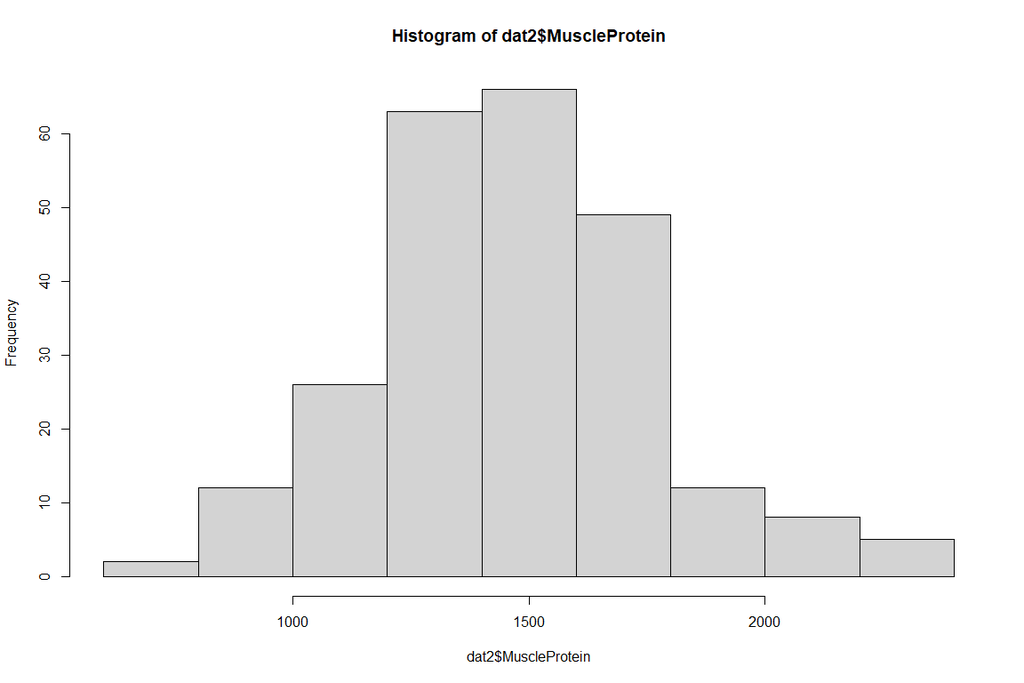

```r
dat2 = dat1[is.na(dat1$AvailableEnerJ) == F, ]
hist(dat2$MuscleProtein)
```

### 5.10.2 Visualize

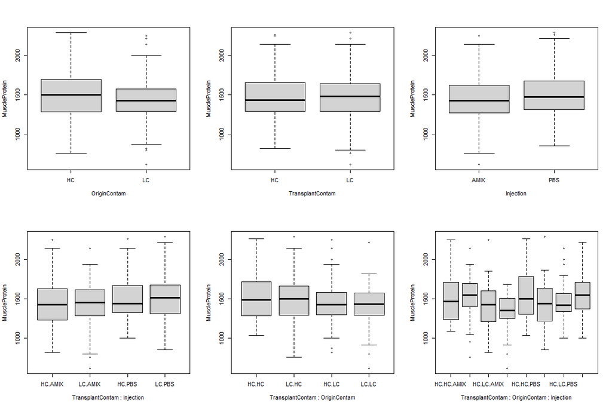

```r
par(mfrow=c(2,3))
boxplot(MuscleProtein  ~ OriginContam, data = dat2)
boxplot(MuscleProtein  ~ TransplantContam, data = dat2)
boxplot(MuscleProtein  ~ Injection, data = dat2)
boxplot(MuscleProtein  ~ TransplantContam * Injection, data = dat2)
boxplot(MuscleProtein  ~ TransplantContam * OriginContam, data = dat2)
boxplot(MuscleProtein  ~ TransplantContam * OriginContam * Injection, data = dat2)
```

### 5.10.3 Build the full model

```r
modfull <-
 lme4::lmer(
    MuscleProtein ~ (TransplantContam + OriginContam + Injection) ^ 3 +  SizeEnd +
      (1 | CagingSite /  CageSiteID) + (1| OriginSite),
    data = dat2,
    na.action = na.exclude
  )
car::Anova(modfull, type = "3")
```

```
## Analysis of Deviance Table (Type III Wald chisquare tests)
##
## Response: MuscleProtein
##                                           Chisq Df Pr(>Chisq)
## (Intercept)                             72.3614  1    < 2e-16 ***
## TransplantContam                         0.0505  1    0.82225
## OriginContam                             0.5392  1    0.46276
## Injection                                0.1729  1    0.67756
## SizeEnd                                  0.0200  1    0.88757
## TransplantContam:OriginContam            1.1311  1    0.28754
## TransplantContam:Injection               1.0491  1    0.30571
## OriginContam:Injection                   0.1112  1    0.73880
## TransplantContam:OriginContam:Injection  2.9188  1    0.08755 .
## ---
## Signif. codes:  0 '***' 0.001 '**' 0.01 '*' 0.05 '.' 0.1 ' ' 1
```

```r
summary(modfull)
```

```
## Linear mixed model fit by REML ['lmerMod']
## Formula: MuscleProtein ~ (TransplantContam + OriginContam + Injection)^3 +
##     SizeEnd + (1 | CagingSite/CageSiteID) + (1 | OriginSite)
##    Data: dat2
##
## REML criterion at convergence: 3336.7
##
## Scaled residuals:
##      Min       1Q   Median       3Q      Max
## -2.60471 -0.62743  0.01437  0.59565  2.93523
##
## Random effects:
##  Groups                Name        Variance  Std.Dev.
##  CageSiteID:CagingSite (Intercept) 1.963e-09 4.430e-05
##  CagingSite            (Intercept) 0.000e+00 0.000e+00
##  OriginSite            (Intercept) 1.171e+04 1.082e+02
##  Residual                          7.769e+04 2.787e+02
## Number of obs: 243, groups:
## CageSiteID:CagingSite, 24; CagingSite, 4; OriginSite, 4
##
## Fixed effects:
##                                                Estimate Std. Error t value
## (Intercept)                                    1526.254    179.421   8.507
## TransplantContamLC                               15.825     70.440   0.225
## OriginContamLC                                  -95.483    130.032  -0.734
## InjectionPBS                                     30.187     72.600   0.416
## SizeEnd                                          -2.159     15.273  -0.141
## TransplantContamLC:OriginContamLC              -105.421     99.123  -1.064
## TransplantContamLC:InjectionPBS                -102.738    100.304  -1.024
## OriginContamLC:InjectionPBS                      34.730    104.155   0.333
## TransplantContamLC:OriginContamLC:InjectionPBS  245.234    143.540   1.708
##
## Correlation of Fixed Effects:
##             (Intr) TrnCLC OrgCLC InjPBS SizEnd TrCLC:OCLC TCLC:I OCLC:I
## TrnsplntCLC -0.255
## OrignCntmLC -0.388  0.285
## InjectinPBS -0.211  0.507  0.275
## SizeEnd     -0.859  0.058  0.030  0.015
## TrnCLC:OCLC  0.131 -0.707 -0.402 -0.360  0.017
## TrnCLC:IPBS  0.141 -0.699 -0.198 -0.724  0.003  0.497
## OrgCLC:IPBS  0.144 -0.353 -0.383 -0.697 -0.006  0.501      0.505
## TCLC:OCLC:I -0.096  0.488  0.277  0.506 -0.005 -0.690     -0.699 -0.726
## optimizer (nloptwrap) convergence code: 0 (OK)
## boundary (singular) fit: see ?isSingular
```

### 5.10.4 Refining the model

```r
mod2 <-
 lme4::lmer(
     MuscleProtein ~ (TransplantContam + OriginContam + Injection) ^ 2 +  SizeEnd +
      (1 | CagingSite /  CageSiteID) + (1| OriginSite),
    data = dat2,
    na.action = na.exclude
  )
car::Anova(mod2, type = "3")
```

```
## Analysis of Deviance Table (Type III Wald chisquare tests)
##
## Response: MuscleProtein
##                                 Chisq Df Pr(>Chisq)
## (Intercept)                   75.1757  1    < 2e-16 ***
## TransplantContam               0.4846  1    0.48633
## OriginContam                   1.5581  1    0.21195
## Injection                      0.2680  1    0.60469
## SizeEnd                        0.0182  1    0.89255
## TransplantContam:OriginContam  0.0252  1    0.87389
## TransplantContam:Injection     0.0558  1    0.81328
## OriginContam:Injection         5.1861  1    0.02277 *
## ---
## Signif. codes:  0 '***' 0.001 '**' 0.01 '*' 0.05 '.' 0.1 ' ' 1
```

```r
summary(mod2)
```

```
## Linear mixed model fit by REML ['lmerMod']
## Formula: MuscleProtein ~ (TransplantContam + OriginContam + Injection)^2 +
##     SizeEnd + (1 | CagingSite/CageSiteID) + (1 | OriginSite)
##    Data: dat2
##
## REML criterion at convergence: 3351.4
##
## Scaled residuals:
##      Min       1Q   Median       3Q      Max
## -2.69191 -0.66757  0.03888  0.63366  3.03282
##
## Random effects:
##  Groups                Name        Variance  Std.Dev.
##  CageSiteID:CagingSite (Intercept) 0.000e+00 0.000e+00
##  CagingSite            (Intercept) 1.930e-11 4.393e-06
##  OriginSite            (Intercept) 1.190e+04 1.091e+02
##  Residual                          7.832e+04 2.799e+02
## Number of obs: 243, groups:
## CageSiteID:CagingSite, 24; CagingSite, 4; OriginSite, 4
##
## Fixed effects:
##                                   Estimate Std. Error t value
## (Intercept)                       1556.133    179.477   8.670
## TransplantContamLC                 -42.962     61.714  -0.696
## OriginContamLC                    -157.057    125.824  -1.248
## InjectionPBS                       -32.552     62.882  -0.518
## SizeEnd                             -2.072     15.339  -0.135
## TransplantContamLC:OriginContamLC   11.433     72.029   0.159
## TransplantContamLC:InjectionPBS     17.016     72.040   0.236
## OriginContamLC:InjectionPBS        163.859     71.953   2.277
##
## Correlation of Fixed Effects:
##             (Intr) TrnCLC OrgCLC InjPBS SizEnd TCLC:O TCLC:I
## TrnsplntCLC -0.239
## OrignCntmLC -0.378  0.178
## InjectinPBS -0.189  0.345  0.162
## SizeEnd     -0.863  0.069  0.033  0.020
## TrnCLC:OCLC  0.090 -0.586 -0.302 -0.017  0.019
## TrnCLC:IPBS  0.104 -0.573 -0.006 -0.600 -0.001  0.029
## OrgCLC:IPBS  0.108  0.002 -0.274 -0.556 -0.014  0.001 -0.005
## optimizer (nloptwrap) convergence code: 0 (OK)
## boundary (singular) fit: see ?isSingular
```

### 5.10.5 Refining the model

```r
mod3 <-
 lme4::lmer(
    MuscleProtein ~ (Injection + OriginContam) ^ 2 +  TransplantContam +  SizeEnd +
      (1 | CagingSite /  CageSiteID) + (1| OriginSite),
    data = dat2,
    na.action = na.exclude
  )
car::Anova(mod3, type = "3")
```

```
## Analysis of Deviance Table (Type III Wald chisquare tests)
##
## Response: MuscleProtein
##                          Chisq Df Pr(>Chisq)
## (Intercept)            76.3940  1    < 2e-16 ***
## Injection               0.2228  1    0.63692
## OriginContam            1.5859  1    0.20792
## TransplantContam        0.6546  1    0.41846
## SizeEnd                 0.0200  1    0.88740
## Injection:OriginContam  5.2335  1    0.02216 *
## ---
## Signif. codes:  0 '***' 0.001 '**' 0.01 '*' 0.05 '.' 0.1 ' ' 1
```

```r
summary(mod3)
```

```
## Linear mixed model fit by REML ['lmerMod']
## Formula: MuscleProtein ~ (Injection + OriginContam)^2 + TransplantContam +
##     SizeEnd + (1 | CagingSite/CageSiteID) + (1 | OriginSite)
##    Data: dat2
##
## REML criterion at convergence: 3372.3
##
## Scaled residuals:
##     Min      1Q  Median      3Q     Max
## -2.7069 -0.6835  0.0192  0.6125  3.0499
##
## Random effects:
##  Groups                Name        Variance Std.Dev.
##  CageSiteID:CagingSite (Intercept)     0      0.0
##  CagingSite            (Intercept)     0      0.0
##  OriginSite            (Intercept) 11926    109.2
##  Residual                          77683    278.7
## Number of obs: 243, groups:
## CageSiteID:CagingSite, 24; CagingSite, 4; OriginSite, 4
##
## Fixed effects:
##                             Estimate Std. Error t value
## (Intercept)                 1549.863    177.322   8.740
## InjectionPBS                 -23.641     50.086  -0.472
## OriginContamLC              -151.109    119.993  -1.259
## TransplantContamLC           -29.267     36.173  -0.809
## SizeEnd                       -2.163     15.278  -0.142
## InjectionPBS:OriginContamLC  163.928     71.657   2.288
##
## Correlation of Fixed Effects:
##             (Intr) InjPBS OrgCLC TrnCLC SizEnd
## InjectinPBS -0.160
## OrignCntmLC -0.373  0.206
## TrnsplntCLC -0.223  0.003  0.003
## SizeEnd     -0.872  0.024  0.040  0.136
## InjPBS:OCLC  0.109 -0.699 -0.285  0.000 -0.014
## optimizer (nloptwrap) convergence code: 0 (OK)
## boundary (singular) fit: see ?isSingular
```

### 5.10.6 Refining the model

```r
mod4 <-
 lme4::lmer(
    MuscleProtein ~ (Injection + OriginContam) ^ 2 +
      (1 | CagingSite /  CageSiteID) + (1| OriginSite),
    data = dat2,
    na.action = na.exclude
  )
car::Anova(mod4, type = "3")
```

```
## Analysis of Deviance Table (Type III Wald chisquare tests)
##
## Response: MuscleProtein
##                           Chisq Df Pr(>Chisq)
## (Intercept)            339.6044  1    < 2e-16 ***
## Injection                0.2213  1    0.63809
## OriginContam             1.6859  1    0.19415
## Injection:OriginContam   5.2605  1    0.02181 *
## ---
## Signif. codes:  0 '***' 0.001 '**' 0.01 '*' 0.05 '.' 0.1 ' ' 1
```

```r
summary(mod4)
```

```
## Linear mixed model fit by REML ['lmerMod']
## Formula:
## MuscleProtein ~ (Injection + OriginContam)^2 + (1 | CagingSite/CageSiteID) +
##     (1 | OriginSite)
##    Data: dat2
##
## REML criterion at convergence: 3389.2
##
## Scaled residuals:
##      Min       1Q   Median       3Q      Max
## -2.75840 -0.65962 -0.01681  0.57098  3.10906
##
## Random effects:
##  Groups                Name        Variance Std.Dev.
##  CageSiteID:CagingSite (Intercept)     0      0
##  CagingSite            (Intercept)     0      0
##  OriginSite            (Intercept) 11026    105
##  Residual                          77287    278
## Number of obs: 243, groups:
## CageSiteID:CagingSite, 24; CagingSite, 4; OriginSite, 4
##
## Fixed effects:
##                             Estimate Std. Error t value
## (Intercept)                  1513.01      82.10  18.428
## InjectionPBS                  -23.49      49.94  -0.470
## OriginContamLC               -150.65     116.02  -1.298
## InjectionPBS:OriginContamLC   163.91      71.47   2.294
##
## Correlation of Fixed Effects:
##             (Intr) InjPBS OrgCLC
## InjectinPBS -0.299
## OrignCntmLC -0.708  0.212
## InjPBS:OCLC  0.209 -0.699 -0.294
## optimizer (nloptwrap) convergence code: 0 (OK)
## boundary (singular) fit: see ?isSingular
```

```r
modProtein <- mod4
RmodProtein  <- MuMIn::r.squaredGLMM(modProtein)
```

Now that we have identified the best model, add sex as covariate to check whether results are sensitive NB: sample size is reduced when adding sex variable within the model, for this reason the sex effect on results is checked on the final model

### 5.10.7 Test for the sex effect

```r
dat2 = dat2[is.na(dat2$Sex) == F, ]
modSex <-
 lme4::lmer(
    MuscleProtein ~ (Injection + OriginContam) ^ 2   + Sex +
      (1 | CagingSite /  CageSiteID) + (1| OriginSite),
    data = dat2,
    na.action = na.exclude
  )
car::Anova(modSex, type = "3")
```

```
## Analysis of Deviance Table (Type III Wald chisquare tests)
##
## Response: MuscleProtein
##                           Chisq Df Pr(>Chisq)
## (Intercept)            338.1336  1    < 2e-16 ***
## Injection                0.2654  1    0.60641
## OriginContam             2.0614  1    0.15107
## Sex                      0.3682  1    0.54396
## Injection:OriginContam   6.3645  1    0.01164 *
## ---
## Signif. codes:  0 '***' 0.001 '**' 0.01 '*' 0.05 '.' 0.1 ' ' 1
```

```r
summary(modSex)
```

```
## Linear mixed model fit by REML ['lmerMod']
## Formula:
## MuscleProtein ~ (Injection + OriginContam)^2 + Sex + (1 | CagingSite/CageSiteID) +
##     (1 | OriginSite)
##    Data: dat2
##
## REML criterion at convergence: 3356.6
##
## Scaled residuals:
##      Min       1Q   Median       3Q      Max
## -2.76403 -0.63054  0.02422  0.60396  2.65019
##
## Random effects:
##  Groups                Name        Variance Std.Dev.
##  CageSiteID:CagingSite (Intercept)     0      0.0
##  CagingSite            (Intercept)     0      0.0
##  OriginSite            (Intercept) 10824    104.0
##  Residual                          74589    273.1
## Number of obs: 242, groups:
## CageSiteID:CagingSite, 24; CagingSite, 4; OriginSite, 4
##
## Fixed effects:
##                             Estimate Std. Error t value
## (Intercept)                  1522.81      82.81  18.388
## InjectionPBS                  -25.33      49.16  -0.515
## OriginContamLC               -164.92     114.87  -1.436
## SexM                          -22.09      36.40  -0.607
## InjectionPBS:OriginContamLC   177.47      70.35   2.523
##
## Correlation of Fixed Effects:
##             (Intr) InjPBS OrgCLC SexM
## InjectinPBS -0.303
## OrignCntmLC -0.695  0.210
## SexM        -0.195  0.062  0.010
## InjPBS:OCLC  0.202 -0.696 -0.293  0.010
## optimizer (nloptwrap) convergence code: 0 (OK)
## boundary (singular) fit: see ?isSingular
```

The sex effect is non-significant. The mod4 is thus the best model. Here, the interactions between fish origin and the immune challenge are significant, with LC fish site having a decreasing level of proteins in their muscle when immune challenged. On the contrary HC fish have a constant level of proteins, whatever the injection (control saline solution or antigen mixture).

```r
pairwise.t.test(dat2$MuscleProtein, dat2$O2xI, p.adjust.method = "fdr")
```

```
##
##  Pairwise comparisons using t tests with pooled SD
##
## data:  dat2$MuscleProtein and dat2$O2xI
##
##         HC_AMIX HC_PBS LC_AMIX
## HC_PBS  0.8066  -      -
## LC_AMIX 0.0057  0.0111 -
## LC_PBS  0.8066  0.8066 0.0098
##
## P value adjustment method: fdr
```

## 5.11 Available energy - Carbohydrates

### 5.11.1 Check the data

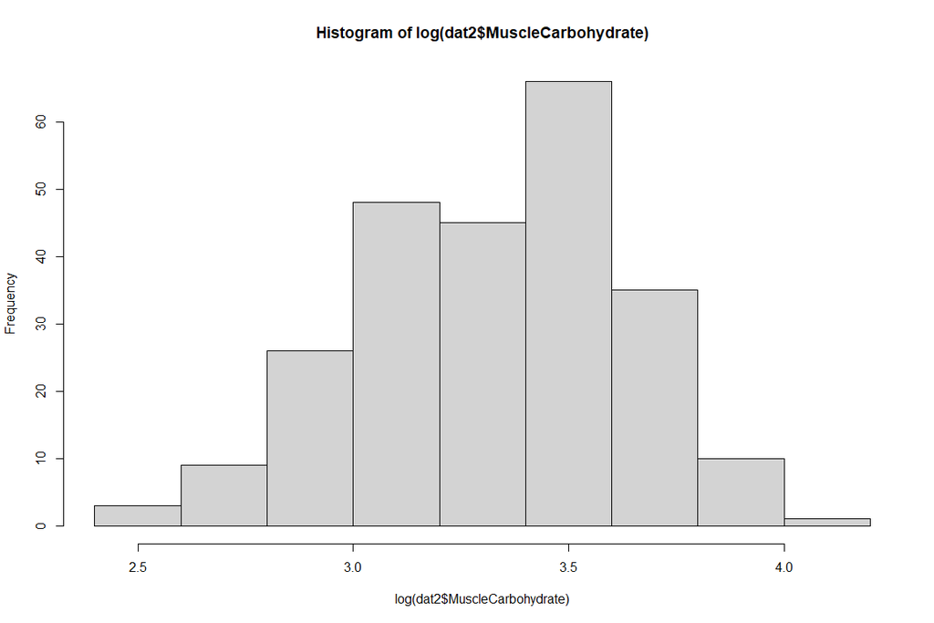

```r
dat2 = dat1[is.na(dat1$AvailableEnerJ) == F, ]
hist(log(dat2$MuscleCarbohydrate))
```

### 5.11.2 Visualize

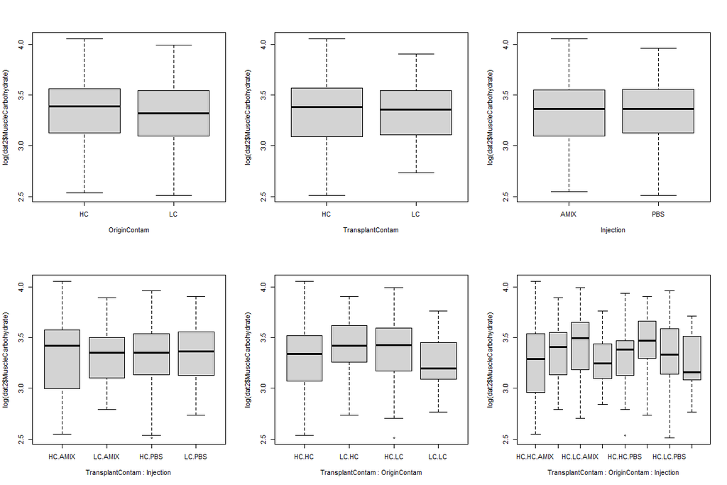

```r
par(mfrow=c(2,3))
boxplot(log(dat2$MuscleCarbohydrate)  ~ OriginContam, data = dat2)
boxplot(log(dat2$MuscleCarbohydrate)  ~ TransplantContam, data = dat2)
boxplot(log(dat2$MuscleCarbohydrate)  ~ Injection, data = dat2)
boxplot(log(dat2$MuscleCarbohydrate)  ~ TransplantContam * Injection, data = dat2)
boxplot(log(dat2$MuscleCarbohydrate)  ~ TransplantContam * OriginContam, data = dat2)
boxplot(log(dat2$MuscleCarbohydrate)  ~ TransplantContam * OriginContam * Injection, data = dat2)
```

### 5.11.3 Build the full model

```r
modfull <-
 lme4::lmer(
    log(dat2$MuscleCarbohydrate) ~ (TransplantContam + OriginContam + Injection) ^ 3 +  SizeEnd +
      (1 | CagingSite /  CageSiteID) + (1| OriginSite),
    data = dat2,
    na.action = na.exclude
  )
car::Anova(modfull, type = "3")
```

```
## Analysis of Deviance Table (Type III Wald chisquare tests)
##
## Response: log(dat2$MuscleCarbohydrate)
##                                            Chisq Df Pr(>Chisq)
## (Intercept)                             367.1817  1    < 2e-16 ***
## TransplantContam                          0.5896  1    0.44259
## OriginContam                              4.3332  1    0.03738 *
## Injection                                 0.5074  1    0.47625
## SizeEnd                                   0.3274  1    0.56717
## TransplantContam:OriginContam             6.0797  1    0.01367 *
## TransplantContam:Injection                0.0196  1    0.88857
## OriginContam:Injection                    1.7999  1    0.17973
## TransplantContam:OriginContam:Injection   0.1076  1    0.74287
## ---
## Signif. codes:  0 '***' 0.001 '**' 0.01 '*' 0.05 '.' 0.1 ' ' 1
```

```r
summary(modfull)
```

```
## Linear mixed model fit by REML ['lmerMod']
## Formula: log(dat2$MuscleCarbohydrate) ~ (TransplantContam + OriginContam +
##     Injection)^3 + SizeEnd + (1 | CagingSite/CageSiteID) + (1 |
##     OriginSite)
##    Data: dat2
##
## REML criterion at convergence: 119.6
##
## Scaled residuals:
##     Min      1Q  Median      3Q     Max
## -2.5702 -0.6259  0.1120  0.6593  2.5329
##
## Random effects:
##  Groups                Name        Variance  Std.Dev.
##  CageSiteID:CagingSite (Intercept) 0.0002886 0.01699
##  CagingSite            (Intercept) 0.0179209 0.13387
##  OriginSite            (Intercept) 0.0000000 0.00000
##  Residual                          0.0824606 0.28716
## Number of obs: 243, groups:
## CageSiteID:CagingSite, 24; CagingSite, 4; OriginSite, 4
##
## Fixed effects:
##                                                 Estimate Std. Error t value
## (Intercept)                                     3.186285   0.166282  19.162
## TransplantContamLC                              0.117167   0.152594   0.768
## OriginContamLC                                  0.156032   0.074957   2.082
## InjectionPBS                                    0.053292   0.074811   0.712
## SizeEnd                                         0.007105   0.012416   0.572
## TransplantContamLC:OriginContamLC              -0.254236   0.103109  -2.466
## TransplantContamLC:InjectionPBS                 0.014481   0.103351   0.140
## OriginContamLC:InjectionPBS                    -0.143983   0.107322  -1.342
## TransplantContamLC:OriginContamLC:InjectionPBS  0.048517   0.147890   0.328
##
## Correlation of Fixed Effects:
##             (Intr) TrnCLC OrgCLC InjPBS SizEnd TrCLC:OCLC TCLC:I OCLC:I
## TrnsplntCLC -0.483
## OrignCntmLC -0.259  0.246
## InjectinPBS -0.226  0.241  0.490
## SizeEnd     -0.758  0.025  0.044  0.006
## TrnCLC:OCLC  0.152 -0.340 -0.725 -0.356  0.015
## TrnCLC:IPBS  0.149 -0.333 -0.354 -0.724  0.015  0.493
## OrgCLC:IPBS  0.156 -0.168 -0.683 -0.697 -0.002  0.497      0.505
## TCLC:OCLC:I -0.101  0.232  0.495  0.506 -0.014 -0.684     -0.699 -0.726
## optimizer (nloptwrap) convergence code: 0 (OK)
## boundary (singular) fit: see ?isSingular
```

### 5.11.4 Refining the model

```r
mod2 <-
 lme4::lmer(
     log(dat2$MuscleCarbohydrate) ~ (TransplantContam + OriginContam + Injection) ^ 2 +  SizeEnd +
      (1 | CagingSite /  CageSiteID) + (1| OriginSite),
    data = dat2,
    na.action = na.exclude
  )
car::Anova(mod2, type = "3")
```

```
## Analysis of Deviance Table (Type III Wald chisquare tests)
##
## Response: log(dat2$MuscleCarbohydrate)
##                                  Chisq Df Pr(>Chisq)
## (Intercept)                   372.6047  1  < 2.2e-16 ***
## TransplantContam                0.5049  1   0.477360
## OriginContam                    4.8750  1   0.027249 *
## Injection                       0.4016  1   0.526289
## SizeEnd                         0.3325  1   0.564180
## TransplantContam:OriginContam   9.4054  1   0.002163 **
## TransplantContam:Injection      0.2694  1   0.603704
## OriginContam:Injection          2.5818  1   0.108098
## ---
## Signif. codes:  0 '***' 0.001 '**' 0.01 '*' 0.05 '.' 0.1 ' ' 1
```

```r
summary(mod2)
```

```
## Linear mixed model fit by REML ['lmerMod']
## Formula: log(dat2$MuscleCarbohydrate) ~ (TransplantContam + OriginContam +
##     Injection)^2 + SizeEnd + (1 | CagingSite/CageSiteID) + (1 |
##     OriginSite)
##    Data: dat2
##
## REML criterion at convergence: 117.7
##
## Scaled residuals:
##     Min      1Q  Median      3Q     Max
## -2.5977 -0.6287  0.1023  0.6809  2.5155
##
## Random effects:
##  Groups                Name        Variance  Std.Dev.
##  CageSiteID:CagingSite (Intercept) 0.0003481 0.01866
##  CagingSite            (Intercept) 0.0179094 0.13383
##  OriginSite            (Intercept) 0.0000000 0.00000
##  Residual                          0.0821005 0.28653
## Number of obs: 243, groups:
## CageSiteID:CagingSite, 24; CagingSite, 4; OriginSite, 4
##
## Fixed effects:
##                                    Estimate Std. Error t value
## (Intercept)                        3.191944   0.165360  19.303
## TransplantContamLC                 0.105441   0.148393   0.711
## OriginContamLC                     0.143834   0.065144   2.208
## InjectionPBS                       0.040809   0.064399   0.634
## SizeEnd                            0.007155   0.012408   0.577
## TransplantContamLC:OriginContamLC -0.231120   0.075361  -3.067
## TransplantContamLC:InjectionPBS    0.038293   0.073770   0.519
## OriginContamLC:InjectionPBS       -0.118397   0.073685  -1.607
##
## Correlation of Fixed Effects:
##             (Intr) TrnCLC OrgCLC InjPBS SizEnd TCLC:O TCLC:I
## TrnsplntCLC -0.475
## OrignCntmLC -0.241  0.156
## InjectinPBS -0.203  0.147  0.319
## SizeEnd     -0.763  0.029  0.059  0.015
## TrnCLC:OCLC  0.115 -0.255 -0.610 -0.016  0.007
## TrnCLC:IPBS  0.110 -0.244 -0.013 -0.600  0.006  0.029
## OrgCLC:IPBS  0.120  0.001 -0.540 -0.556 -0.018  0.001 -0.005
## optimizer (nloptwrap) convergence code: 0 (OK)
## boundary (singular) fit: see ?isSingular
```

### 5.11.5 Refining the model

```r
mod3 <-
 lme4::lmer(
    log(dat2$MuscleCarbohydrate) ~ (TransplantContam + OriginContam) ^ 2 + Injection +  SizeEnd +
      (1 | CagingSite /  CageSiteID) + (1| OriginSite),
    data = dat2,
    na.action = na.exclude
  )
car::Anova(mod3, type = "3")
```

```
## Analysis of Deviance Table (Type III Wald chisquare tests)
##
## Response: log(dat2$MuscleCarbohydrate)
##                                  Chisq Df Pr(>Chisq)
## (Intercept)                   386.4042  1  < 2.2e-16 ***
## TransplantContam                0.7383  1   0.390203
## OriginContam                    2.5671  1   0.109107
## Injection                       0.0070  1   0.933181
## SizeEnd                         0.2962  1   0.586268
## TransplantContam:OriginContam   9.4985  1   0.002056 **
## ---
## Signif. codes:  0 '***' 0.001 '**' 0.01 '*' 0.05 '.' 0.1 ' ' 1
```

```r
summary(mod3)
```

```
## Linear mixed model fit by REML ['lmerMod']
## Formula: log(dat2$MuscleCarbohydrate) ~ (TransplantContam + OriginContam)^2 +
##     Injection + SizeEnd + (1 | CagingSite/CageSiteID) + (1 |      OriginSite)
##    Data: dat2
##
## REML criterion at convergence: 113.8
##
## Scaled residuals:
##     Min      1Q  Median      3Q     Max
## -2.7435 -0.5677  0.0726  0.6620  2.4868
##
## Random effects:
##  Groups                Name        Variance  Std.Dev.
##  CageSiteID:CagingSite (Intercept) 0.0003136 0.01771
##  CagingSite            (Intercept) 0.0181006 0.13454
##  OriginSite            (Intercept) 0.0000000 0.00000
##  Residual                          0.0824140 0.28708
## Number of obs: 243, groups:
## CageSiteID:CagingSite, 24; CagingSite, 4; OriginSite, 4
##
## Fixed effects:
##                                    Estimate Std. Error t value
## (Intercept)                        3.214453   0.163526  19.657
## TransplantContamLC                 0.124211   0.144558   0.859
## OriginContamLC                     0.087790   0.054793   1.602
## InjectionPBS                       0.003094   0.036907   0.084
## SizeEnd                            0.006758   0.012417   0.544
## TransplantContamLC:OriginContamLC -0.232115   0.075314  -3.082
##
## Correlation of Fixed Effects:
##             (Intr) TrnCLC OrgCLC InjPBS SizEnd
## TrnsplntCLC -0.469
## OrignCntmLC -0.210  0.186
## InjectinPBS -0.123  0.000  0.019
## SizeEnd     -0.771  0.032  0.059  0.016
## TrnCLC:OCLC  0.113 -0.255 -0.724  0.003  0.007
## optimizer (nloptwrap) convergence code: 0 (OK)
## boundary (singular) fit: see ?isSingular
```

### 5.11.6 Refining the model

```r
mod4 <-
 lme4::lmer(
    log(dat2$MuscleCarbohydrate) ~ (TransplantContam + OriginContam) ^ 2 +
      (1 | CagingSite /  CageSiteID) + (1| OriginSite),
    data = dat2,
    na.action = na.exclude
  )
car::Anova(mod4, type = "3")
```

```
## Analysis of Deviance Table (Type III Wald chisquare tests)
##
## Response: log(dat2$MuscleCarbohydrate)
##                                   Chisq Df Pr(>Chisq)
## (Intercept)                   1043.8093  1  < 2.2e-16 ***
## TransplantContam                 0.7218  1   0.395558
## OriginContam                     2.5004  1   0.113818
## TransplantContam:OriginContam    9.6379  1   0.001906 **
## ---
## Signif. codes:  0 '***' 0.001 '**' 0.01 '*' 0.05 '.' 0.1 ' ' 1
```

```r
summary(mod4)
```

```
## Linear mixed model fit by REML ['lmerMod']
## Formula: log(dat2$MuscleCarbohydrate) ~ (TransplantContam + OriginContam)^2 +
##     (1 | CagingSite/CageSiteID) + (1 | OriginSite)
##    Data: dat2
##
## REML criterion at convergence: 102.4
##
## Scaled residuals:
##      Min       1Q   Median       3Q      Max
## -2.74057 -0.58246  0.07299  0.69077  2.51534
##
## Random effects:
##  Groups                Name        Variance Std.Dev.
##  CageSiteID:CagingSite (Intercept) 0.000265 0.01628
##  CagingSite            (Intercept) 0.017795 0.13340
##  OriginSite            (Intercept) 0.000000 0.00000
##  Residual                          0.081869 0.28613
## Number of obs: 243, groups:
## CageSiteID:CagingSite, 24; CagingSite, 4; OriginSite, 4
##
## Fixed effects:
##                                   Estimate Std. Error t value
## (Intercept)                        3.28444    0.10166  32.308
## TransplantContamLC                 0.12175    0.14330   0.850
## OriginContamLC                     0.08596    0.05436   1.581
## TransplantContamLC:OriginContamLC -0.23238    0.07485  -3.104
##
## Correlation of Fixed Effects:
##             (Intr) TrnCLC OrgCLC
## TrnsplntCLC -0.709
## OrignCntmLC -0.261  0.185
## TrnCLC:OCLC  0.189 -0.256 -0.726
## optimizer (nloptwrap) convergence code: 0 (OK)
## boundary (singular) fit: see ?isSingular
```

```r
modCarboh <- mod4
RmodCarboh  <- MuMIn::r.squaredGLMM(modCarboh)
```

Now that we have identified the best model, add sex as covariate to check whether results are sensitive NB: sample size is reduced when adding sex variable within the model, for this reason the sex effect on results is checked on the final model

### 5.11.7 Test for the sex effect

```r
dat2 = dat2[is.na(dat2$Sex) == F, ]
modSex <-
 lme4::lmer(
    log(dat2$MuscleCarbohydrate) ~ (TransplantContam + OriginContam) ^ 2  + Sex +
      (1 | CagingSite /  CageSiteID) + (1| OriginSite),
    data = dat2,
    na.action = na.exclude
  )
car::Anova(modSex, type = "3")
```

```
## Analysis of Deviance Table (Type III Wald chisquare tests)
##
## Response: log(dat2$MuscleCarbohydrate)
##                                   Chisq Df Pr(>Chisq)
## (Intercept)                   1013.2175  1  < 2.2e-16 ***
## TransplantContam                 0.7518  1   0.385901
## OriginContam                     2.4458  1   0.117843
## Sex                              0.5670  1   0.451469
## TransplantContam:OriginContam    9.7814  1   0.001763 **
## ---
## Signif. codes:  0 '***' 0.001 '**' 0.01 '*' 0.05 '.' 0.1 ' ' 1
```

```r
summary(modSex)
```

```
## Linear mixed model fit by REML ['lmerMod']
## Formula: log(dat2$MuscleCarbohydrate) ~ (TransplantContam + OriginContam)^2 +
##     Sex + (1 | CagingSite/CageSiteID) + (1 | OriginSite)
##    Data: dat2
##
## REML criterion at convergence: 106.9
##
## Scaled residuals:
##      Min       1Q   Median       3Q      Max
## -2.75737 -0.57667  0.03485  0.66901  2.49046
##
## Random effects:
##  Groups                Name        Variance  Std.Dev.
##  CageSiteID:CagingSite (Intercept) 0.0001979 0.01407
##  CagingSite            (Intercept) 0.0182223 0.13499
##  OriginSite            (Intercept) 0.0000000 0.00000
##  Residual                          0.0823006 0.28688
## Number of obs: 242, groups:
## CageSiteID:CagingSite, 24; CagingSite, 4; OriginSite, 4
##
## Fixed effects:
##                                   Estimate Std. Error t value
## (Intercept)                        3.29392    0.10348  31.831
## TransplantContamLC                 0.12559    0.14484   0.867
## OriginContamLC                     0.08535    0.05458   1.564
## SexM                              -0.02888    0.03835  -0.753
## TransplantContamLC:OriginContamLC -0.23545    0.07528  -3.128
##
## Correlation of Fixed Effects:
##             (Intr) TrnCLC OrgCLC SexM
## TrnsplntCLC -0.699
## OrignCntmLC -0.248  0.183
## SexM        -0.124 -0.034 -0.049
## TrnCLC:OCLC  0.172 -0.254 -0.728  0.101
## optimizer (nloptwrap) convergence code: 0 (OK)
## boundary (singular) fit: see ?isSingular
```

The sex effect is non-significant. The mod4 is thus the best model. Here, the interactions between fish origin and the transplant site are significant, confirming the pattern observed for the integrative measure of available energy previously observed.

## 5.12 Daily mass changes

### 5.12.1 Check the data

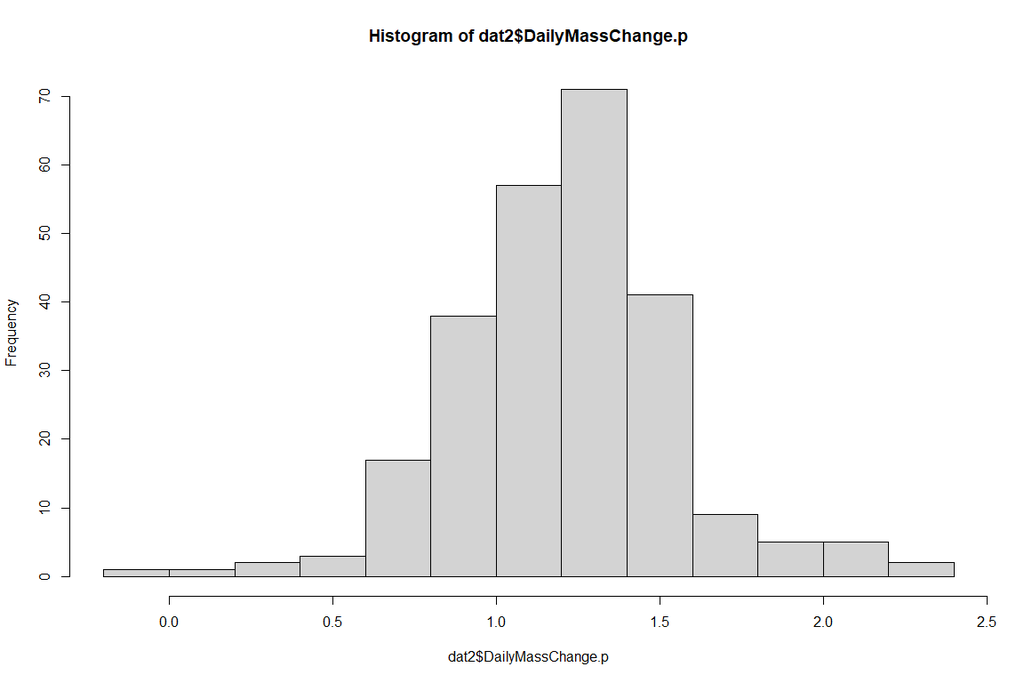

```r
dat2 = dat1[is.na(dat1$DailyMassChange) == F, ]
# transform variable to approx. normality
dat2$DailyMassChange.p <-
  bimixt::boxcox(dat2$DailyMassChange + 3,
         car::powerTransform(dat2$DailyMassChange + 3)$lambda)
hist(dat2$DailyMassChange.p)
```

### 5.12.2 Visualize

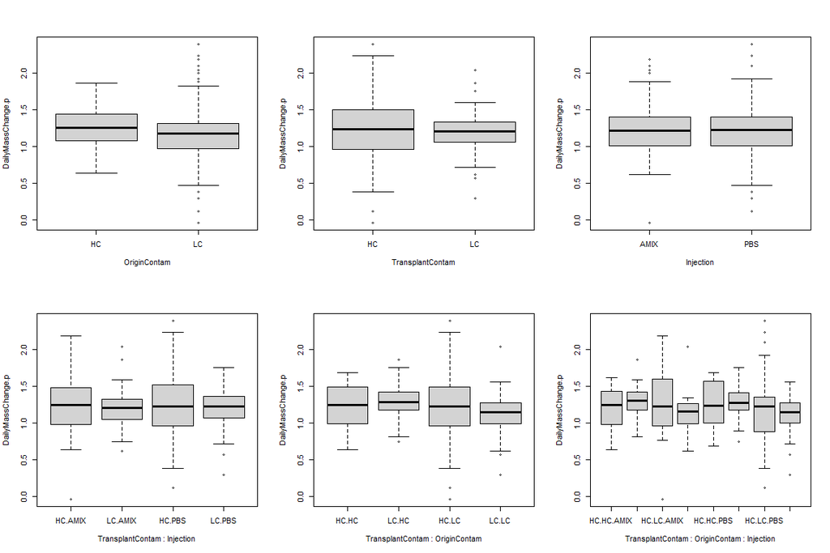

```r
par(mfrow=c(2,3))
boxplot(DailyMassChange.p ~ OriginContam, data = dat2)
boxplot(DailyMassChange.p ~ TransplantContam, data = dat2)
boxplot(DailyMassChange.p ~ Injection, data = dat2)
boxplot(DailyMassChange.p ~ TransplantContam * Injection, data = dat2)
boxplot(DailyMassChange.p ~ TransplantContam * OriginContam, data = dat2)
boxplot(DailyMassChange.p ~ TransplantContam * OriginContam * Injection, data = dat2)
```

### 5.12.3 Build the full model

```r
modfull <-
 lme4::lmer(
    DailyMassChange.p ~ (TransplantContam + OriginContam + Injection) ^ 3 +  SizeEnd +
      (1 | CagingSite /  CageSiteID) + (1| OriginSite),
    data = dat2,
    na.action = na.exclude
  )
car::Anova(modfull, type = "3")
```

```
## Analysis of Deviance Table (Type III Wald chisquare tests)
##
## Response: DailyMassChange.p
##                                           Chisq Df Pr(>Chisq)
## (Intercept)                             15.8885  1  6.719e-05 ***
## TransplantContam                         0.1775  1   0.673520
## OriginContam                             1.7041  1   0.191755
## Injection                                0.5038  1   0.477828
## SizeEnd                                  2.7096  1   0.099745 .
## TransplantContam:OriginContam            7.6762  1   0.005596 **
## TransplantContam:Injection               0.3860  1   0.534387
## OriginContam:Injection                   1.4633  1   0.226406
## TransplantContam:OriginContam:Injection  0.8882  1   0.345957
## ---
## Signif. codes:  0 '***' 0.001 '**' 0.01 '*' 0.05 '.' 0.1 ' ' 1
```

```r
summary(modfull)
```

```
## Linear mixed model fit by REML ['lmerMod']
## Formula: DailyMassChange.p ~ (TransplantContam + OriginContam + Injection)^3 +
##     SizeEnd + (1 | CagingSite/CageSiteID) + (1 | OriginSite)
##    Data: dat2
##
## REML criterion at convergence: 93.9
##
## Scaled residuals:
##     Min      1Q  Median      3Q     Max
## -4.4412 -0.5700  0.0571  0.5996  3.1697
##
## Random effects:
##  Groups                Name        Variance Std.Dev.
##  CageSiteID:CagingSite (Intercept) 0.003799 0.06164
##  CagingSite            (Intercept) 0.059924 0.24479
##  OriginSite            (Intercept) 0.005396 0.07346
##  Residual                          0.070161 0.26488
## Number of obs: 248, groups:
## CageSiteID:CagingSite, 24; CagingSite, 4; OriginSite, 4
##
## Fixed effects:
##                                                Estimate Std. Error t value
## (Intercept)                                     0.94405    0.23684   3.986
## TransplantContamLC                              0.10781    0.25587   0.421
## OriginContamLC                                  0.13745    0.10529   1.305
## InjectionPBS                                    0.04748    0.06690   0.710
## SizeEnd                                         0.02351    0.01428   1.646
## TransplantContamLC:OriginContamLC              -0.29247    0.10556  -2.771
## TransplantContamLC:InjectionPBS                -0.05833    0.09387  -0.621
## OriginContamLC:InjectionPBS                    -0.11757    0.09719  -1.210
## TransplantContamLC:OriginContamLC:InjectionPBS  0.12739    0.13517   0.942
##
## Correlation of Fixed Effects:
##             (Intr) TrnCLC OrgCLC InjPBS SizEnd TrCLC:OCLC TCLC:I OCLC:I
## TrnsplntCLC -0.549
## OrignCntmLC -0.239  0.103
## InjectinPBS -0.143  0.124  0.302
## SizeEnd     -0.607  0.014  0.033  0.014
## TrnCLC:OCLC  0.101 -0.205 -0.510 -0.301  0.016
## TrnCLC:IPBS  0.095 -0.177 -0.215 -0.712  0.001  0.430
## OrgCLC:IPBS  0.097 -0.086 -0.429 -0.688 -0.008  0.428      0.490
## TCLC:OCLC:I -0.065  0.123  0.308  0.495 -0.002 -0.602     -0.694 -0.719
```

### 5.12.4 Refining the model

```r
mod2 <-
 lme4::lmer(
    DailyMassChange.p ~ (TransplantContam + OriginContam + Injection) ^ 2  +  SizeEnd +
      (1 | CagingSite /  CageSiteID) + (1| OriginSite),
    data = dat2,
    na.action = na.exclude
  )
car::Anova(mod2, type = "3")
```

```
## Analysis of Deviance Table (Type III Wald chisquare tests)
##
## Response: DailyMassChange.p
##                                 Chisq Df Pr(>Chisq)
## (Intercept)                   16.4593  1  4.971e-05 ***
## TransplantContam               0.0945  1   0.758506
## OriginContam                   1.1422  1   0.285195
## Injection                      0.0787  1   0.779052
## SizeEnd                        2.7144  1   0.099448 .
## TransplantContam:OriginContam  7.5825  1   0.005894 **
## TransplantContam:Injection     0.0022  1   0.962993
## OriginContam:Injection         0.5876  1   0.443337
## ---
## Signif. codes:  0 '***' 0.001 '**' 0.01 '*' 0.05 '.' 0.1 ' ' 1
```

```r
summary(mod2)
```

```
## Linear mixed model fit by REML ['lmerMod']
## Formula: DailyMassChange.p ~ (TransplantContam + OriginContam + Injection)^2 +
##     SizeEnd + (1 | CagingSite/CageSiteID) + (1 | OriginSite)
##    Data: dat2
##
## REML criterion at convergence: 92.7
##
## Scaled residuals:
##     Min      1Q  Median      3Q     Max
## -4.5140 -0.5651  0.0643  0.5870  3.1142
##
## Random effects:
##  Groups                Name        Variance Std.Dev.
##  CageSiteID:CagingSite (Intercept) 0.003851 0.06206
##  CagingSite            (Intercept) 0.059988 0.24492
##  OriginSite            (Intercept) 0.005354 0.07317
##  Residual                          0.070103 0.26477
## Number of obs: 248, groups:
## CageSiteID:CagingSite, 24; CagingSite, 4; OriginSite, 4
##
## Fixed effects:
##                                    Estimate Std. Error t value
## (Intercept)                        0.958781   0.236327   4.057
## TransplantContamLC                 0.078117   0.254084   0.307
## OriginContamLC                     0.106900   0.100026   1.069
## InjectionPBS                       0.016304   0.058113   0.281
## SizeEnd                            0.023513   0.014271   1.648
## TransplantContamLC:OriginContamLC -0.232617   0.084476  -2.754
## TransplantContamLC:InjectionPBS    0.003133   0.067528   0.046
## OriginContamLC:InjectionPBS       -0.051771   0.067535  -0.767
##
## Correlation of Fixed Effects:
##             (Intr) TrnCLC OrgCLC InjPBS SizEnd TCLC:O TCLC:I
## TrnsplntCLC -0.546
## OrignCntmLC -0.231  0.070
## InjectinPBS -0.127  0.074  0.182
## SizeEnd     -0.608  0.015  0.035  0.017
## TrnCLC:OCLC  0.078 -0.165 -0.429 -0.005  0.018
## TrnCLC:IPBS  0.069 -0.128 -0.001 -0.590  0.000  0.021
## OrgCLC:IPBS  0.073  0.004 -0.314 -0.551 -0.014 -0.009 -0.018
```

### 5.12.5 Refining the model

```r
mod3 <-
 lme4::lmer(
    DailyMassChange.p ~ (TransplantContam + OriginContam) ^ 2 + Injection + SizeEnd +
      (1 | CagingSite /  CageSiteID) + (1| OriginSite),
    data = dat2,
    na.action = na.exclude
  )
car::Anova(mod3, type = "3")
```

```
## Analysis of Deviance Table (Type III Wald chisquare tests)
##
## Response: DailyMassChange.p
##                                 Chisq Df Pr(>Chisq)
## (Intercept)                   17.0593  1  3.623e-05 ***
## TransplantContam               0.1008  1    0.75085
## OriginContam                   0.7564  1    0.38446
## Injection                      0.0443  1    0.83334
## SizeEnd                        2.7067  1    0.09992 .
## TransplantContam:OriginContam  7.7238  1    0.00545 **
## ---
## Signif. codes:  0 '***' 0.001 '**' 0.01 '*' 0.05 '.' 0.1 ' ' 1
```

```r
summary(mod3)
```

```
## Linear mixed model fit by REML ['lmerMod']
## Formula: DailyMassChange.p ~ (TransplantContam + OriginContam)^2 + Injection +
##     SizeEnd + (1 | CagingSite/CageSiteID) + (1 | OriginSite)
##    Data: dat2
##
## REML criterion at convergence: 86.2
##
## Scaled residuals:
##     Min      1Q  Median      3Q     Max
## -4.5818 -0.5506  0.0588  0.6014  3.1688
##
## Random effects:
##  Groups                Name        Variance Std.Dev.
##  CageSiteID:CagingSite (Intercept) 0.003751 0.06124
##  CagingSite            (Intercept) 0.060026 0.24500
##  OriginSite            (Intercept) 0.005448 0.07381
##  Residual                          0.069723 0.26405
## Number of obs: 248, groups:
## CageSiteID:CagingSite, 24; CagingSite, 4; OriginSite, 4
##
## Fixed effects:
##                                    Estimate Std. Error t value
## (Intercept)                        0.970727   0.235026   4.130
## TransplantContamLC                 0.080002   0.251963   0.318
## OriginContamLC                     0.082800   0.095204   0.870
## InjectionPBS                      -0.007081   0.033652  -0.210
## SizeEnd                            0.023431   0.014242   1.645
## TransplantContamLC:OriginContamLC -0.233196   0.083908  -2.779
##
## Correlation of Fixed Effects:
##             (Intr) TrnCLC OrgCLC InjPBS SizEnd
## TrnsplntCLC -0.545
## OrignCntmLC -0.220  0.073
## InjectinPBS -0.078 -0.002  0.008
## SizeEnd     -0.609  0.015  0.032  0.016
## TrnCLC:OCLC  0.077 -0.163 -0.451  0.005  0.018
```

### 5.12.6 Refining the model

```r
mod4 <-
 lme4::lmer(
    DailyMassChange.p ~ (TransplantContam + OriginContam) ^ 2  + SizeEnd +
      (1 | CagingSite /  CageSiteID) + (1| OriginSite),
    data = dat2,
    na.action = na.exclude
  )
car::Anova(mod4, type = "3")
```

```
## Analysis of Deviance Table (Type III Wald chisquare tests)
##
## Response: DailyMassChange.p
##                                 Chisq Df Pr(>Chisq)
## (Intercept)                   17.0349  1   3.67e-05 ***
## TransplantContam               0.1006  1   0.751141
## OriginContam                   0.7581  1   0.383911
## SizeEnd                        2.7346  1   0.098194 .
## TransplantContam:OriginContam  7.7194  1   0.005463 **
## ---
## Signif. codes:  0 '***' 0.001 '**' 0.01 '*' 0.05 '.' 0.1 ' ' 1
```

```r
summary(mod4)
```

```
## Linear mixed model fit by REML ['lmerMod']
## Formula: DailyMassChange.p ~ (TransplantContam + OriginContam)^2 + SizeEnd +
##     (1 | CagingSite/CageSiteID) + (1 | OriginSite)
##    Data: dat2
##
## REML criterion at convergence: 81.2
##
## Scaled residuals:
##     Min      1Q  Median      3Q     Max
## -4.6078 -0.5608  0.0519  0.5984  3.1870
##
## Random effects:
##  Groups                Name        Variance Std.Dev.
##  CageSiteID:CagingSite (Intercept) 0.003781 0.06149
##  CagingSite            (Intercept) 0.060029 0.24501
##  OriginSite            (Intercept) 0.005469 0.07395
##  Residual                          0.069423 0.26348
## Number of obs: 248, groups:
## CageSiteID:CagingSite, 24; CagingSite, 4; OriginSite, 4
##
## Fixed effects:
##                                   Estimate Std. Error t value
## (Intercept)                        0.96658    0.23419   4.127
## TransplantContamLC                 0.07991    0.25197   0.317
## OriginContamLC                     0.08299    0.09531   0.871
## SizeEnd                            0.02351    0.01422   1.654
## TransplantContamLC:OriginContamLC -0.23314    0.08391  -2.778
##
## Correlation of Fixed Effects:
##             (Intr) TrnCLC OrgCLC SizEnd
## TrnsplntCLC -0.547
## OrignCntmLC -0.220  0.073
## SizeEnd     -0.609  0.015  0.032
## TrnCLC:OCLC  0.078 -0.163 -0.450  0.018
```

### 5.12.7 Refining the model

```r
mod5 <-
 lme4::lmer(
    DailyMassChange.p ~ (TransplantContam + OriginContam) ^ 2 +
      (1 | CagingSite /  CageSiteID) + (1| OriginSite),
    data = dat2,
    na.action = na.exclude
  )
car::Anova(mod5, type = "3")
```

```
## Analysis of Deviance Table (Type III Wald chisquare tests)
##
## Response: DailyMassChange.p
##                                 Chisq Df Pr(>Chisq)
## (Intercept)                   46.0496  1  1.153e-11 ***
## TransplantContam               0.0872  1    0.76776
## OriginContam                   0.5827  1    0.44526
## TransplantContam:OriginContam  4.9114  1    0.02668 *
## ---
## Signif. codes:  0 '***' 0.001 '**' 0.01 '*' 0.05 '.' 0.1 ' ' 1
```

```r
summary(mod5)
```

```
## Linear mixed model fit by REML ['lmerMod']
## Formula: DailyMassChange.p ~ (TransplantContam + OriginContam)^2 + (1 |
##     CagingSite/CageSiteID) + (1 | OriginSite)
##    Data: dat2
##
## REML criterion at convergence: 107.2
##
## Scaled residuals:
##     Min      1Q  Median      3Q     Max
## -4.4880 -0.5227  0.0623  0.5611  3.1177
##
## Random effects:
##  Groups                Name        Variance Std.Dev.
##  CageSiteID:CagingSite (Intercept) 0.006937 0.08329
##  CagingSite            (Intercept) 0.057970 0.24077
##  OriginSite            (Intercept) 0.000000 0.00000
##  Residual                          0.077979 0.27925
## Number of obs: 252, groups:
## CageSiteID:CagingSite, 24; CagingSite, 4; OriginSite, 4
##
## Fixed effects:
##                                   Estimate Std. Error t value
## (Intercept)                        1.20243    0.17719   6.786
## TransplantContamLC                 0.07397    0.25048   0.295
## OriginContamLC                     0.05348    0.07005   0.763
## TransplantContamLC:OriginContamLC -0.21739    0.09809  -2.216
##
## Correlation of Fixed Effects:
##             (Intr) TrnCLC OrgCLC
## TrnsplntCLC -0.707
## OrignCntmLC -0.194  0.138
## TrnCLC:OCLC  0.139 -0.194 -0.714
## optimizer (nloptwrap) convergence code: 0 (OK)
## boundary (singular) fit: see ?isSingular
```

```r
modDMC <- mod5
RmodDMC  <- MuMIn::r.squaredGLMM(modDMC)
```

Here, the interactions between fish origin and the transplant site are significant.

Now that we have identified the best model, add sex as covariate to check whether results are sensitive NB: sample size is reduced when adding sex variable within the model, for this reason the sex effect on results is checked on the final model

### 5.12.8 Test for the sex effect

```r
dat2 = dat2[is.na(dat2$Sex) == F, ]
 modSex <-
 lme4::lmer(
    DailyMassChange.p ~ (TransplantContam + OriginContam) ^ 2  + Sex +
      (1 | CagingSite /  CageSiteID) + (1| OriginSite),
    data = dat2,
    na.action = na.exclude
  )
car::Anova(modSex, type = "3")
```

```
## Analysis of Deviance Table (Type III Wald chisquare tests)
##
## Response: DailyMassChange.p
##                                 Chisq Df Pr(>Chisq)
## (Intercept)                   46.4776  1  9.267e-12 ***
## TransplantContam               0.0955  1   0.757281
## OriginContam                   2.6068  1   0.106406
## Sex                            0.5753  1   0.448174
## TransplantContam:OriginContam  8.9250  1   0.002813 **
## ---
## Signif. codes:  0 '***' 0.001 '**' 0.01 '*' 0.05 '.' 0.1 ' ' 1
```

```r
summary(modSex)
```

```
## Linear mixed model fit by REML ['lmerMod']
## Formula: DailyMassChange.p ~ (TransplantContam + OriginContam)^2 + Sex +
##     (1 | CagingSite/CageSiteID) + (1 | OriginSite)
##    Data: dat2
##
## REML criterion at convergence: 62.7
##
## Scaled residuals:
##     Min      1Q  Median      3Q     Max
## -4.8836 -0.5478  0.0778  0.5956  3.4584
##
## Random effects:
##  Groups                Name        Variance  Std.Dev.
##  CageSiteID:CagingSite (Intercept) 5.185e-03 7.201e-02
##  CagingSite            (Intercept) 5.904e-02 2.430e-01
##  OriginSite            (Intercept) 8.010e-12 2.830e-06
##  Residual                          6.446e-02 2.539e-01
## Number of obs: 247, groups:
## CageSiteID:CagingSite, 24; CagingSite, 4; OriginSite, 4
##
## Fixed effects:
##                                   Estimate Std. Error t value
## (Intercept)                        1.21094    0.17762   6.817
## TransplantContamLC                 0.07746    0.25064   0.309
## OriginContamLC                     0.10133    0.06276   1.615
## SexM                              -0.02610    0.03441  -0.758
## TransplantContamLC:OriginContamLC -0.26263    0.08791  -2.987
##
## Correlation of Fixed Effects:
##             (Intr) TrnCLC OrgCLC SexM
## TrnsplntCLC -0.705
## OrignCntmLC -0.168  0.122
## SexM        -0.064 -0.018 -0.045
## TrnCLC:OCLC  0.117 -0.172 -0.716  0.081
## optimizer (nloptwrap) convergence code: 0 (OK)
## boundary (singular) fit: see ?isSingular
```

Adding the sex as covariate does no change the significance of the interactions, also sex effect is non-significant. The mod5 is thus the best model.

### 5.12.9 Posthoc test (pairwise t-test)

The interactions between fish origin and the transplant site are significant. Hence, perform posthoc test (pairwise t-test) according to significant interactions.

```r
pairwise.t.test(dat2$DailyMassChange.p, dat2$CxO2, p.adjust.method = "fdr")
```

```
##
##  Pairwise comparisons using t tests with pooled SD
##
## data:  dat2$DailyMassChange.p and dat2$CxO2
##
##       HC_HC HC_LC LC_HC
## HC_LC 0.378 -     -
## LC_HC 0.382 0.851 -
## LC_LC 0.132 0.014 0.014
##
## P value adjustment method: fdr
```

Here the posthoc are non significant, except between the HC and LC fish when exposed to LC sites, likely because responses were very different depending on the population considered (see non-parallel plastic responses below). Also,because interaction between the contamination in origin and transplant site of fish is significant We test for parallel response between replicate populations.

### 5.12.10 Test for parallel responses between replicate populations (from the same origin)

#### 5.12.10.1 For Populations from High contamination sites (AUSCOR and RIOU)

```r
dat3 <- dat2[which(dat2$OriginSite %in% c("AUSCOR", "RIOU")),]
## build the null model
mod.null <-
  glm(DailyMassChange.p ~ TransplantContam + OriginSite,
      data = dat3)
## build the model with the site of origin in interaction with the level of contam in transplant sites
mod.par <-
  glm(DailyMassChange.p ~ TransplantContam * OriginSite,
      data = dat3)

anova(mod.null, mod.par, test = "LRT")
```

```
## Analysis of Deviance Table
##
## Model 1: DailyMassChange.p ~ TransplantContam + OriginSite
## Model 2: DailyMassChange.p ~ TransplantContam * OriginSite
##   Resid. Df Resid. Dev Df Deviance  Pr(>Chi)
## 1       125     6.4448
## 2       124     5.0924  1   1.3524 9.546e-09 ***
## ---
## Signif. codes:  0 '***' 0.001 '**' 0.01 '*' 0.05 '.' 0.1 ' ' 1
```

```r
coef(mod.par)
```

```
##                       (Intercept)                TransplantContamLC
##                         0.9855391                         0.2785145
##                    OriginSiteRIOU TransplantContamLC:OriginSiteRIOU
##                         0.4367652                        -0.4118958
```

```r
summary(mod.par)
```

```
##
## Call:
## glm(formula = DailyMassChange.p ~ TransplantContam * OriginSite,
##     data = dat3)
##
## Deviance Residuals:
##      Min        1Q    Median        3Q       Max
## -0.52373  -0.12763   0.00892   0.13518   0.59893
##
## Coefficients:
##                                   Estimate Std. Error t value Pr(>|t|)
## (Intercept)                        0.98554    0.03763  26.189  < 2e-16 ***
## TransplantContamLC                 0.27851    0.05158   5.400 3.27e-07 ***
## OriginSiteRIOU                     0.43677    0.05122   8.526 4.38e-14 ***
## TransplantContamLC:OriginSiteRIOU -0.41190    0.07178  -5.739 6.91e-08 ***
## ---
## Signif. codes:  0 '***' 0.001 '**' 0.01 '*' 0.05 '.' 0.1 ' ' 1
##
## (Dispersion parameter for gaussian family taken to be 0.04106755)
##
##     Null deviance: 8.1850  on 127  degrees of freedom
## Residual deviance: 5.0924  on 124  degrees of freedom
## AIC: -39.46
##
## Number of Fisher Scoring iterations: 2
```

The null model and the model including the site of origin in interaction with the level of contaminant in transplant sites are significantly different, we hence reject the null hypothesis, here the slopes of HC populations are not parallel.

#### 5.12.10.2 For Populations from Low contamination sites (ARIMAS and CELFIG)

```r
# We test for parallel response between replicate LC populations (ARIMAS and CELFIG)
dat4 <- dat2[which(dat2$OriginSite %in% c("ARIMAS", "CELFIG")),]
## build the null model
mod.null <-
  glm(DailyMassChange.p ~ TransplantContam + OriginSite,
      data = dat4)
## build the model with the site of origin in interaction with the level of contam in transplant sites
mod.par <-
  glm(DailyMassChange.p ~ TransplantContam * OriginSite,
      data = dat4)

anova(mod.null, mod.par, test = "LRT")
```

```
## Analysis of Deviance Table
##
## Model 1: DailyMassChange.p ~ TransplantContam + OriginSite
## Model 2: DailyMassChange.p ~ TransplantContam * OriginSite
##   Resid. Df Resid. Dev Df Deviance  Pr(>Chi)
## 1       116     13.396
## 2       115     11.297  1   2.0997 3.778e-06 ***
## ---
## Signif. codes:  0 '***' 0.001 '**' 0.01 '*' 0.05 '.' 0.1 ' ' 1
```

```r
coef(mod.par)
```

```
##                         (Intercept)                  TransplantContamLC
##                          1.02261170                          0.08832977
##                    OriginSiteCELFIG TransplantContamLC:OriginSiteCELFIG
##                          0.54826564                         -0.53245772
```

```r
summary(mod.par)
```

```
##
## Call:
## glm(formula = DailyMassChange.p ~ TransplantContam * OriginSite,
##     data = dat4)
##
## Deviance Residuals:
##      Min        1Q    Median        3Q       Max
## -1.19383  -0.18877   0.00355   0.18266   0.91144
##
## Coefficients:
##                                     Estimate Std. Error t value Pr(>|t|)
## (Intercept)                          1.02261    0.05820  17.570  < 2e-16 ***
## TransplantContamLC                   0.08833    0.08036   1.099    0.274
## OriginSiteCELFIG                     0.54827    0.08382   6.541 1.76e-09 ***
## TransplantContamLC:OriginSiteCELFIG -0.53246    0.11517  -4.623 9.95e-06 ***
## ---
## Signif. codes:  0 '***' 0.001 '**' 0.01 '*' 0.05 '.' 0.1 ' ' 1
##
## (Dispersion parameter for gaussian family taken to be 0.09823347)
##
##     Null deviance: 16.343  on 118  degrees of freedom
## Residual deviance: 11.297  on 115  degrees of freedom
## AIC: 67.51
##
## Number of Fisher Scoring iterations: 2
```

The null model and the model including the site of origin in interaction with the level of contaminant in transplant sites are significantly different, we hence reject the null hypothesis, here the slopes of LC populations are not parallel.

### 5.12.11 Visualize

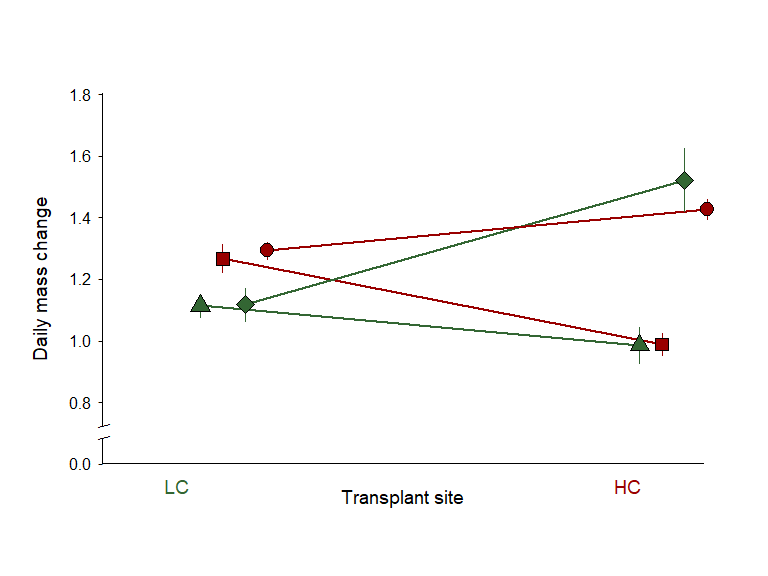

```r
DMCPlot1()
```

## 5.13 HSI

### 5.13.1 Check the data

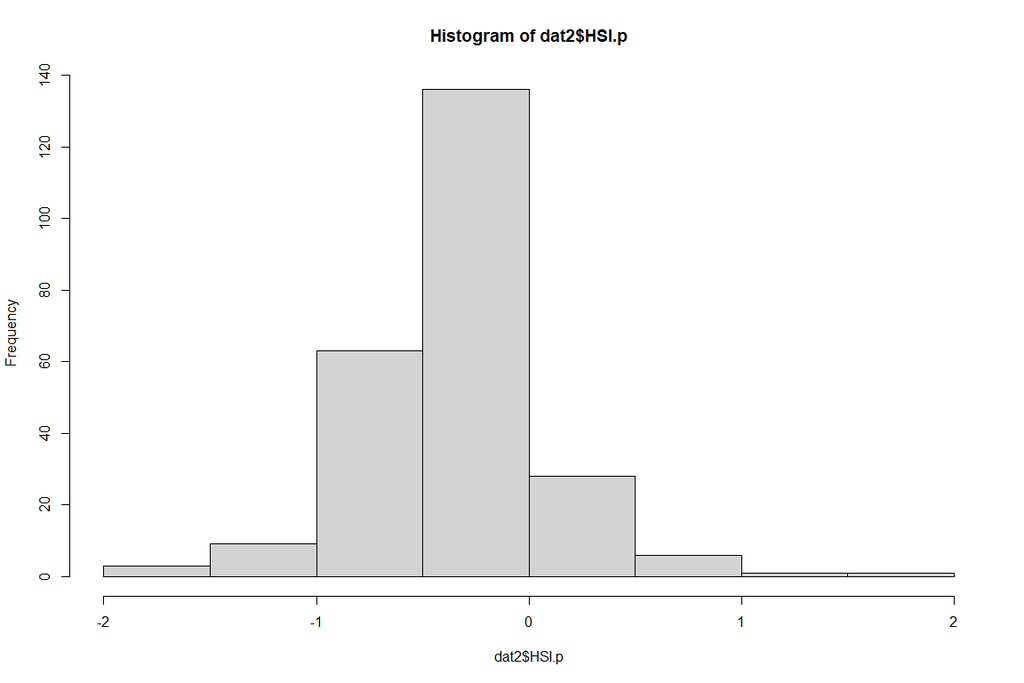

```r
dat2 = dat1[is.na(dat1$HSI) == F, ]
# transform variable to approx. normality
dat2$HSI.p <- bimixt::boxcox(dat2$HSI, car::powerTransform(dat2$HSI)$lambda)
hist(dat2$HSI.p)
```

### 5.13.2 Visualize

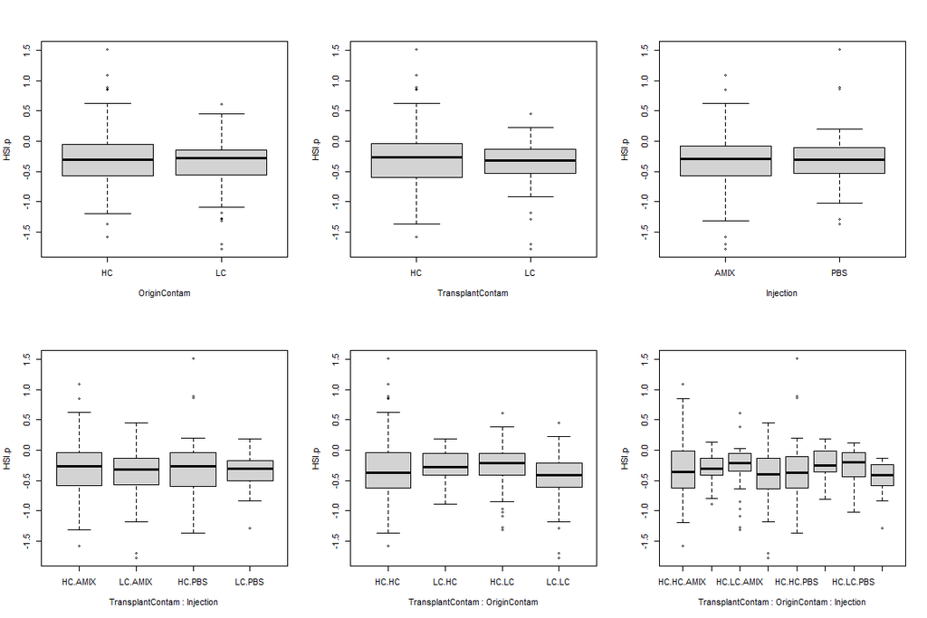

```r
par(mfrow=c(2,3))
boxplot(HSI.p ~ OriginContam, data = dat2)
boxplot(HSI.p ~ TransplantContam, data = dat2)
boxplot(HSI.p ~ Injection, data = dat2)
boxplot(HSI.p ~ TransplantContam * Injection, data = dat2)
boxplot(HSI.p ~ TransplantContam * OriginContam, data = dat2)
boxplot(HSI.p ~ TransplantContam * OriginContam * Injection, data = dat2)
```

### 5.13.3 Build the full model

```r
modfull <-
 lme4::lmer(
    HSI.p ~ (TransplantContam + OriginContam + Injection) ^ 3 +  SizeEnd +
      (1 | CagingSite /  CageSiteID) + (1| OriginSite),
    data = dat2,
    na.action = na.exclude
  )
car::Anova(modfull, type = "3")
```

```
## Analysis of Deviance Table (Type III Wald chisquare tests)
##
## Response: HSI.p
##                                          Chisq Df Pr(>Chisq)
## (Intercept)                             0.1222  1    0.72664
## TransplantContam                        0.0241  1    0.87661
## OriginContam                            0.0383  1    0.84479
## Injection                               0.1593  1    0.68984
## SizeEnd                                 5.0481  1    0.02465 *
## TransplantContam:OriginContam           1.9608  1    0.16143
## TransplantContam:Injection              0.0554  1    0.81391
## OriginContam:Injection                  0.0203  1    0.88683
## TransplantContam:OriginContam:Injection 0.1900  1    0.66290
## ---
## Signif. codes:  0 '***' 0.001 '**' 0.01 '*' 0.05 '.' 0.1 ' ' 1
```

```r
summary(modfull)
```

```
## Linear mixed model fit by REML ['lmerMod']
## Formula: HSI.p ~ (TransplantContam + OriginContam + Injection)^3 + SizeEnd +
##     (1 | CagingSite/CageSiteID) + (1 | OriginSite)
##    Data: dat2
##
## REML criterion at convergence: 240.2
##
## Scaled residuals:
##     Min      1Q  Median      3Q     Max
## -3.5377 -0.4674  0.0100  0.4845  4.0412
##
## Random effects:
##  Groups                Name        Variance Std.Dev.
##  CageSiteID:CagingSite (Intercept) 0.01483  0.1218
##  CagingSite            (Intercept) 0.04700  0.2168
##  OriginSite            (Intercept) 0.05889  0.2427
##  Residual                          0.12635  0.3555
## Number of obs: 247, groups:
## CageSiteID:CagingSite, 24; CagingSite, 4; OriginSite, 4
##
## Fixed effects:
##                                                Estimate Std. Error t value
## (Intercept)                                     0.11082    0.31699   0.350
## TransplantContamLC                              0.03793    0.24427   0.155
## OriginContamLC                                  0.05252    0.26825   0.196
## InjectionPBS                                    0.03585    0.08982   0.399
## SizeEnd                                        -0.04535    0.02018  -2.247
## TransplantContamLC:OriginContamLC              -0.22386    0.15987  -1.400
## TransplantContamLC:InjectionPBS                 0.02967    0.12607   0.235
## OriginContamLC:InjectionPBS                     0.01865    0.13105   0.142
## TransplantContamLC:OriginContamLC:InjectionPBS -0.07929    0.18189  -0.436
##
## Correlation of Fixed Effects:
##             (Intr) TrnCLC OrgCLC InjPBS SizEnd TrCLC:OCLC TCLC:I OCLC:I
## TrnsplntCLC -0.399
## OrignCntmLC -0.432  0.097
## InjectinPBS -0.144  0.175  0.159
## SizeEnd     -0.640  0.021  0.018  0.015
## TrnCLC:OCLC  0.116 -0.323 -0.304 -0.266  0.014
## TrnCLC:IPBS  0.097 -0.249 -0.113 -0.712 -0.002  0.381
## OrgCLC:IPBS  0.098 -0.120 -0.229 -0.685 -0.009  0.384      0.488
## TCLC:OCLC:I -0.067  0.173  0.165  0.494  0.001 -0.537     -0.693 -0.720
```

### 5.13.4 Refining the model

```r
mod2 <-
 lme4::lmer(
    HSI.p ~ (TransplantContam + OriginContam + Injection) ^ 2 +  SizeEnd +
      (1 | CagingSite /  CageSiteID) + (1| OriginSite),
    data = dat2,
    na.action = na.exclude
  )
car::Anova(mod2, type = "3")
```

```
## Analysis of Deviance Table (Type III Wald chisquare tests)
##
## Response: HSI.p
##                                Chisq Df Pr(>Chisq)
## (Intercept)                   0.1042  1    0.74686
## TransplantContam              0.0548  1    0.81493
## OriginContam                  0.0738  1    0.78590
## Injection                     0.5004  1    0.47933
## SizeEnd                       5.0740  1    0.02429 *
## TransplantContam:OriginContam 3.7542  1    0.05267 .
## TransplantContam:Injection    0.0085  1    0.92639
## OriginContam:Injection        0.0615  1    0.80419
## ---
## Signif. codes:  0 '***' 0.001 '**' 0.01 '*' 0.05 '.' 0.1 ' ' 1
```

```r
summary(mod2)
```

```
## Linear mixed model fit by REML ['lmerMod']
## Formula: HSI.p ~ (TransplantContam + OriginContam + Injection)^2 + SizeEnd +
##     (1 | CagingSite/CageSiteID) + (1 | OriginSite)
##    Data: dat2
##
## REML criterion at convergence: 238.9
##
## Scaled residuals:
##     Min      1Q  Median      3Q     Max
## -3.5179 -0.4467  0.0328  0.4906  4.0196
##
## Random effects:
##  Groups                Name        Variance Std.Dev.
##  CageSiteID:CagingSite (Intercept) 0.01489  0.1220
##  CagingSite            (Intercept) 0.04696  0.2167
##  OriginSite            (Intercept) 0.05887  0.2426
##  Residual                          0.12588  0.3548
## Number of obs: 247, groups:
## CageSiteID:CagingSite, 24; CagingSite, 4; OriginSite, 4
##
## Fixed effects:
##                                    Estimate Std. Error t value
## (Intercept)                        0.102002   0.316004   0.323
## TransplantContamLC                 0.056299   0.240521   0.234
## OriginContamLC                     0.071857   0.264532   0.272
## InjectionPBS                       0.055155   0.077970   0.707
## SizeEnd                           -0.045386   0.020149  -2.253
## TransplantContamLC:OriginContamLC -0.261344   0.134881  -1.938
## TransplantContamLC:InjectionPBS   -0.008382   0.090722  -0.092
## OriginContamLC:InjectionPBS       -0.022495   0.090734  -0.248
##
## Correlation of Fixed Effects:
##             (Intr) TrnCLC OrgCLC InjPBS SizEnd TCLC:O TCLC:I
## TrnsplntCLC -0.394
## OrignCntmLC -0.428  0.071
## InjectinPBS -0.128  0.104  0.091
## SizeEnd     -0.641  0.021  0.018  0.017
## TrnCLC:OCLC  0.095 -0.278 -0.259 -0.002  0.017
## TrnCLC:IPBS  0.070 -0.182  0.002 -0.591 -0.002  0.014
## OrgCLC:IPBS  0.072  0.007 -0.161 -0.547 -0.012 -0.005 -0.022
```

### 5.13.5 Refining the model

```r
mod3 <-
 lme4::lmer(
    HSI.p ~ (TransplantContam + OriginContam) ^ 2 + Injection +  SizeEnd +
      (1 | CagingSite /  CageSiteID) + (1| OriginSite),
    data = dat2,
    na.action = na.exclude
  )
car::Anova(mod3, type = "3")
```

```
## Analysis of Deviance Table (Type III Wald chisquare tests)
##
## Response: HSI.p
##                                Chisq Df Pr(>Chisq)
## (Intercept)                   0.1246  1    0.72405
## TransplantContam              0.0491  1    0.82462
## OriginContam                  0.0552  1    0.81426
## Injection                     0.7845  1    0.37577
## SizeEnd                       5.1540  1    0.02319 *
## TransplantContam:OriginContam 3.7545  1    0.05267 .
## ---
## Signif. codes:  0 '***' 0.001 '**' 0.01 '*' 0.05 '.' 0.1 ' ' 1
```

```r
summary(mod3)
```

```
## Linear mixed model fit by REML ['lmerMod']
## Formula: HSI.p ~ (TransplantContam + OriginContam)^2 + Injection + SizeEnd +
##     (1 | CagingSite/CageSiteID) + (1 | OriginSite)
##    Data: dat2
##
## REML criterion at convergence: 233
##
## Scaled residuals:
##     Min      1Q  Median      3Q     Max
## -3.5095 -0.4566  0.0265  0.5062  4.0599
##
## Random effects:
##  Groups                Name        Variance Std.Dev.
##  CageSiteID:CagingSite (Intercept) 0.01502  0.1226
##  CagingSite            (Intercept) 0.04697  0.2167
##  OriginSite            (Intercept) 0.05890  0.2427
##  Residual                          0.12478  0.3532
## Number of obs: 247, groups:
## CageSiteID:CagingSite, 24; CagingSite, 4; OriginSite, 4
##
## Fixed effects:
##                                   Estimate Std. Error t value
## (Intercept)                        0.11081    0.31385   0.353
## TransplantContamLC                 0.05241    0.23652   0.222
## OriginContamLC                     0.06135    0.26115   0.235
## InjectionPBS                       0.03997    0.04513   0.886
## SizeEnd                           -0.04555    0.02006  -2.270
## TransplantContamLC:OriginContamLC -0.26144    0.13492  -1.938
##
## Correlation of Fixed Effects:
##             (Intr) TrnCLC OrgCLC InjPBS SizEnd
## TrnsplntCLC -0.391
## OrignCntmLC -0.425  0.074
## InjectinPBS -0.079 -0.003  0.002
## SizeEnd     -0.642  0.021  0.016  0.016
## TrnCLC:OCLC  0.095 -0.280 -0.263  0.007  0.017
```

### 5.13.6 Refining the model

```r
mod4 <-
 lme4::lmer(
    HSI.p ~ TransplantContam + Injection + OriginContam +  SizeEnd +
      (1 | CagingSite /  CageSiteID) + (1| OriginSite),
    data = dat2,
    na.action = na.exclude
  )
car::Anova(mod4, type = "3")
```

```
## Analysis of Deviance Table (Type III Wald chisquare tests)
##
## Response: HSI.p
##                   Chisq Df Pr(>Chisq)
## (Intercept)      0.3260  1    0.56801
## TransplantContam 0.1166  1    0.73275
## Injection        0.7948  1    0.37264
## OriginContam     0.0793  1    0.77825
## SizeEnd          5.1853  1    0.02278 *
## ---
## Signif. codes:  0 '***' 0.001 '**' 0.01 '*' 0.05 '.' 0.1 ' ' 1
```

```r
summary(mod4)
```

```
## Linear mixed model fit by REML ['lmerMod']
## Formula: HSI.p ~ TransplantContam + Injection + OriginContam + SizeEnd +
##     (1 | CagingSite/CageSiteID) + (1 | OriginSite)
##    Data: dat2
##
## REML criterion at convergence: 234.4
##
## Scaled residuals:
##     Min      1Q  Median      3Q     Max
## -3.5314 -0.4699  0.0166  0.4858  3.9932
##
## Random effects:
##  Groups                Name        Variance Std.Dev.
##  CageSiteID:CagingSite (Intercept) 0.01893  0.1376
##  CagingSite            (Intercept) 0.04553  0.2134
##  OriginSite            (Intercept) 0.05804  0.2409
##  Residual                          0.12490  0.3534
## Number of obs: 247, groups:
## CageSiteID:CagingSite, 24; CagingSite, 4; OriginSite, 4
##
## Fixed effects:
##                    Estimate Std. Error t value
## (Intercept)         0.17794    0.31163   0.571
## TransplantContamLC -0.07694    0.22532  -0.341
## InjectionPBS        0.04026    0.04515   0.892
## OriginContamLC     -0.07083    0.25154  -0.282
## SizeEnd            -0.04577    0.02010  -2.277
##
## Correlation of Fixed Effects:
##             (Intr) TrnCLC InjPBS OrgCLC
## TrnsplntCLC -0.379
## InjectinPBS -0.080 -0.001
## OrignCntmLC -0.417  0.000  0.004
## SizeEnd     -0.650  0.027  0.016  0.021
```

### 5.13.7 Refining the model

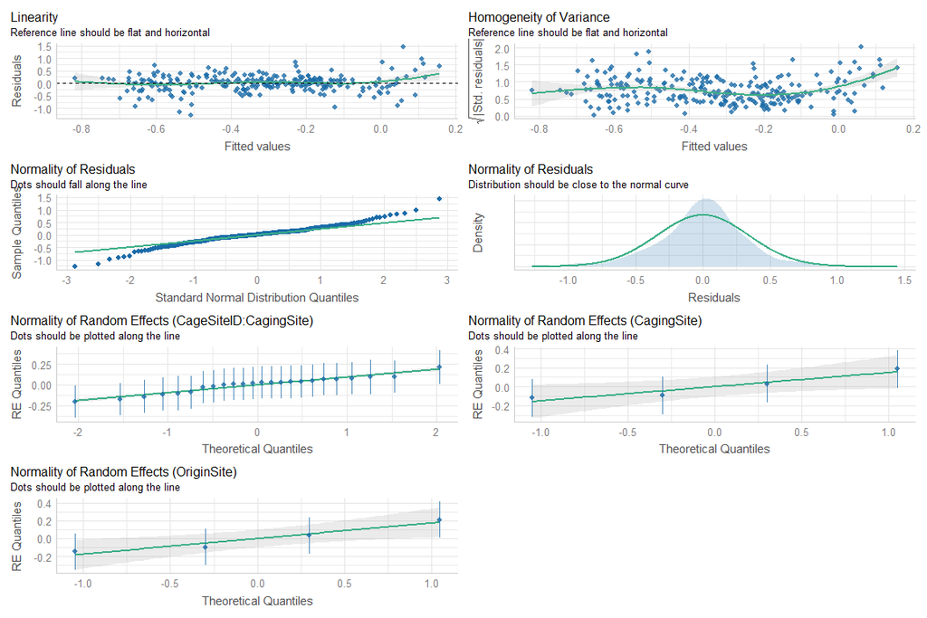

```r
mod5 <-
 lme4::lmer(
    HSI.p ~ SizeEnd +
      (1 | CagingSite /  CageSiteID) + (1| OriginSite),
    data = dat2,
    na.action = na.exclude
  )
performance::check_model(mod5)
```

```r
car::Anova(mod5, type = "3")
```

```
## Analysis of Deviance Table (Type III Wald chisquare tests)
##
## Response: HSI.p
##              Chisq Df Pr(>Chisq)
## (Intercept) 0.1886  1    0.66411
## SizeEnd     4.7807  1    0.02878 *
## ---
## Signif. codes:  0 '***' 0.001 '**' 0.01 '*' 0.05 '.' 0.1 ' ' 1
```

```r
summary(mod5)
```

```
## Linear mixed model fit by REML ['lmerMod']
## Formula: HSI.p ~ SizeEnd + (1 | CagingSite/CageSiteID) + (1 | OriginSite)
##    Data: dat2
##
## REML criterion at convergence: 228.5
##
## Scaled residuals:
##     Min      1Q  Median      3Q     Max
## -3.5897 -0.4568  0.0296  0.4640  4.0940
##
## Random effects:
##  Groups                Name        Variance Std.Dev.
##  CageSiteID:CagingSite (Intercept) 0.01891  0.1375
##  CagingSite            (Intercept) 0.02755  0.1660
##  OriginSite            (Intercept) 0.03462  0.1861
##  Residual                          0.12481  0.3533
## Number of obs: 247, groups:
## CageSiteID:CagingSite, 24; CagingSite, 4; OriginSite, 4
##
## Fixed effects:
##             Estimate Std. Error t value
## (Intercept)  0.10156    0.23389   0.434
## SizeEnd     -0.04355    0.01992  -2.186
##
## Correlation of Fixed Effects:
##         (Intr)
## SizeEnd -0.832
```

```r
modHSI <- mod5
RmodHSI  <- MuMIn::r.squaredGLMM(modHSI)
```

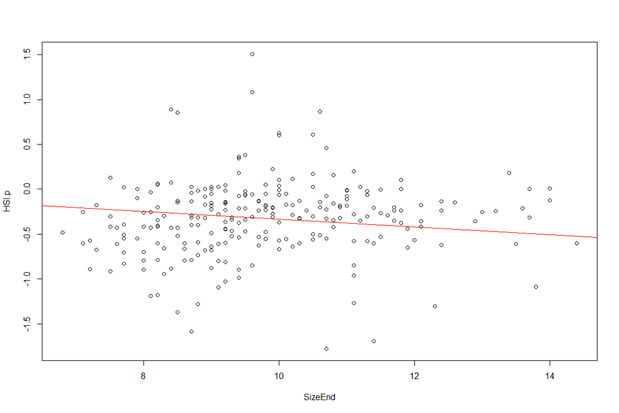

```r
plot(HSI.p ~ SizeEnd, data = dat2)
abline(b = -0.04355, a = 0.10156, col = "red")
```

Now that we have identified the best model, add sex as covariate to check whether results are sensitive NB: sample size is reduced when adding sex variable within the model, for this reason the sex effect on results is checked on the final model

### 5.13.8 Test for the sex effect

```r
dat2 = dat2[is.na(dat2$Sex) == F, ]
modSex <-
 lme4::lmer(
    HSI.p ~ SizeEnd + Sex +
      (1 | CagingSite /  CageSiteID) + (1| OriginSite),
    data = dat2,
    na.action = na.exclude
  )
car::Anova(modSex, type = "3")
```

```
## Analysis of Deviance Table (Type III Wald chisquare tests)
##
## Response: HSI.p
##              Chisq Df Pr(>Chisq)
## (Intercept) 0.1307  1    0.71769
## SizeEnd     3.8317  1    0.05029 .
## Sex         1.6701  1    0.19624
## ---
## Signif. codes:  0 '***' 0.001 '**' 0.01 '*' 0.05 '.' 0.1 ' ' 1
```

```r
summary(modSex)
```

```
## Linear mixed model fit by REML ['lmerMod']
## Formula: HSI.p ~ SizeEnd + Sex + (1 | CagingSite/CageSiteID) + (1 | OriginSite)
##    Data: dat2
##
## REML criterion at convergence: 231.1
##
## Scaled residuals:
##     Min      1Q  Median      3Q     Max
## -3.6703 -0.4511  0.0584  0.5046  4.2012
##
## Random effects:
##  Groups                Name        Variance Std.Dev.
##  CageSiteID:CagingSite (Intercept) 0.01821  0.1349
##  CagingSite            (Intercept) 0.02858  0.1691
##  OriginSite            (Intercept) 0.03231  0.1798
##  Residual                          0.12472  0.3532
## Number of obs: 247, groups:
## CageSiteID:CagingSite, 24; CagingSite, 4; OriginSite, 4
##
## Fixed effects:
##             Estimate Std. Error t value
## (Intercept)  0.08426    0.23304   0.362
## SizeEnd     -0.03932    0.02009  -1.957
## SexM        -0.06291    0.04868  -1.292
##
## Correlation of Fixed Effects:
##         (Intr) SizEnd
## SizeEnd -0.831
## SexM     0.040 -0.143
```

The sex effect is non-significant. The mod5 is thus the best model. Here, there is no interaction, and hence no posthoc test nor parallelism test to conduct

## 5.14 GSI

### 5.14.1 Check the data

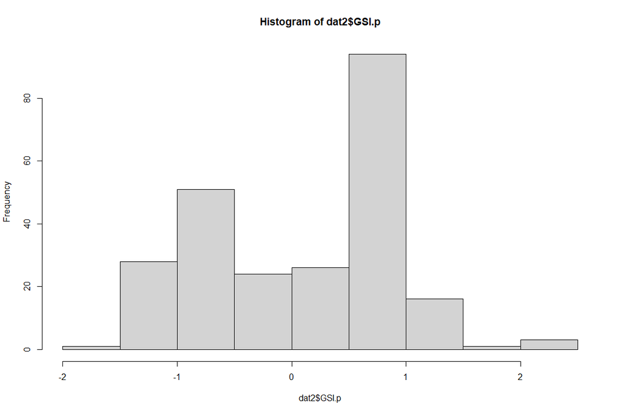

```r
dat2 = dat1[is.na(dat1$GSI) == F, ]
dat2 = dat2[is.na(dat2$Sex) == F, ]
# transform variable to approx. normality
dat2$GSI.p <- bimixt::boxcox(dat2$GSI, car::powerTransform(dat2$GSI)$lambda)
hist(dat2$GSI.p)
```

### 5.14.2 Visualize

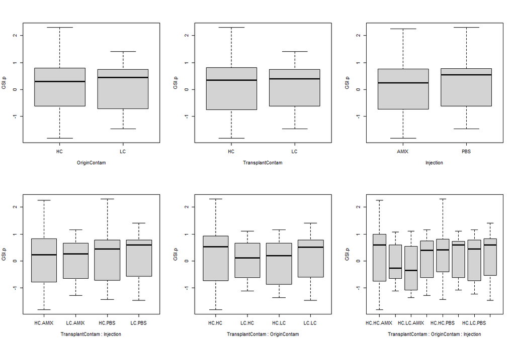

```r
par(mfrow=c(2,3))
boxplot(GSI.p ~ OriginContam, data = dat2)
boxplot(GSI.p ~ TransplantContam, data = dat2)
boxplot(GSI.p ~ Injection, data = dat2)
boxplot(GSI.p ~ TransplantContam * Injection, data = dat2)
boxplot(GSI.p ~ TransplantContam * OriginContam, data = dat2)
boxplot(GSI.p ~ TransplantContam * OriginContam * Injection, data = dat2)
```

### 5.14.3 Build the full model

```r
modfull <-
 lme4::lmer(
    GSI.p ~ (TransplantContam + OriginContam + Injection) ^ 3 +  SizeEnd + Sex +
      (1 | CagingSite /  CageSiteID) + (1| OriginSite),
    data = dat2,
    na.action = na.exclude
  )
car::Anova(modfull, type = "3")
```

```
## Analysis of Deviance Table (Type III Wald chisquare tests)
##
## Response: GSI.p
##                                            Chisq Df Pr(>Chisq)
## (Intercept)                               4.9342  1    0.02633 *
## TransplantContam                          0.4563  1    0.49936
## OriginContam                              0.9120  1    0.33960
## Injection                                 0.7498  1    0.38654
## SizeEnd                                   0.1893  1    0.66350
## Sex                                     630.9592  1    < 2e-16 ***
## TransplantContam:OriginContam             1.3168  1    0.25117
## TransplantContam:Injection                0.5318  1    0.46585
## OriginContam:Injection                    0.3518  1    0.55307
## TransplantContam:OriginContam:Injection   0.0025  1    0.96048
## ---
## Signif. codes:  0 '***' 0.001 '**' 0.01 '*' 0.05 '.' 0.1 ' ' 1
```

```r
summary(modfull)
```

```
## Linear mixed model fit by REML ['lmerMod']
## Formula: GSI.p ~ (TransplantContam + OriginContam + Injection)^3 + SizeEnd +
##     Sex + (1 | CagingSite/CageSiteID) + (1 | OriginSite)
##    Data: dat2
##
## REML criterion at convergence: 289.3
##
## Scaled residuals:
##     Min      1Q  Median      3Q     Max
## -3.6652 -0.3581  0.0312  0.5165  3.8586
##
## Random effects:
##  Groups                Name        Variance  Std.Dev.
##  CageSiteID:CagingSite (Intercept) 6.498e-09 8.061e-05
##  CagingSite            (Intercept) 0.000e+00 0.000e+00
##  OriginSite            (Intercept) 4.845e-02 2.201e-01
##  Residual                          1.678e-01 4.096e-01
## Number of obs: 244, groups:
## CageSiteID:CagingSite, 24; CagingSite, 4; OriginSite, 4
##
## Fixed effects:
##                                                Estimate Std. Error t value
## (Intercept)                                     0.63484    0.28580   2.221
## TransplantContamLC                             -0.06934    0.10265  -0.676
## OriginContamLC                                 -0.23282    0.24380  -0.955
## InjectionPBS                                   -0.09019    0.10416  -0.866
## SizeEnd                                         0.01003    0.02304   0.435
## SexM                                           -1.39931    0.05571 -25.119
## TransplantContamLC:OriginContamLC               0.16830    0.14667   1.148
## TransplantContamLC:InjectionPBS                 0.10648    0.14601   0.729
## OriginContamLC:InjectionPBS                     0.09070    0.15290   0.593
## TransplantContamLC:OriginContamLC:InjectionPBS -0.01050    0.21188  -0.050
##
## Correlation of Fixed Effects:
##             (Intr) TrnCLC OrgCLC InjPBS SizEnd SexM   TrCLC:OCLC TCLC:I OCLC:I
## TrnsplntCLC -0.215
## OrignCntmLC -0.438  0.217
## InjectinPBS -0.177  0.495  0.208
## SizeEnd     -0.797  0.055  0.022  0.003
## SexM         0.047 -0.132 -0.045 -0.029 -0.133
## TrnCLC:OCLC  0.113 -0.706 -0.310 -0.348  0.004  0.150
## TrnCLC:IPBS  0.119 -0.699 -0.151 -0.715  0.002  0.084  0.495
## OrgCLC:IPBS  0.127 -0.348 -0.295 -0.684 -0.016  0.100  0.498      0.494
## TCLC:OCLC:I -0.089  0.489  0.215  0.494  0.012 -0.111 -0.692     -0.693 -0.725
## optimizer (nloptwrap) convergence code: 0 (OK)
## boundary (singular) fit: see ?isSingular
```

### 5.14.4 Refining the model

```r
mod2 <-
 lme4::lmer(
    GSI.p ~ (TransplantContam + OriginContam + Injection) ^ 2 +  SizeEnd + Sex +
      (1 | CagingSite /  CageSiteID) + (1| OriginSite),
    data = dat2,
    na.action = na.exclude
  )
car::Anova(mod2, type = "3")
```

```
## Analysis of Deviance Table (Type III Wald chisquare tests)
##
## Response: GSI.p
##                                  Chisq Df Pr(>Chisq)
## (Intercept)                     4.9720  1    0.02576 *
## TransplantContam                0.5600  1    0.45425
## OriginContam                    0.9356  1    0.33341
## Injection                       0.9407  1    0.33211
## SizeEnd                         0.1898  1    0.66308
## Sex                           641.8109  1    < 2e-16 ***
## TransplantContam:OriginContam   2.3911  1    0.12203
## TransplantContam:Injection      0.9342  1    0.33377
## OriginContam:Injection          0.6577  1    0.41736
## ---
## Signif. codes:  0 '***' 0.001 '**' 0.01 '*' 0.05 '.' 0.1 ' ' 1
```

```r
summary(mod2)
```

```
## Linear mixed model fit by REML ['lmerMod']
## Formula: GSI.p ~ (TransplantContam + OriginContam + Injection)^2 + SizeEnd +
##     Sex + (1 | CagingSite/CageSiteID) + (1 | OriginSite)
##    Data: dat2
##
## REML criterion at convergence: 288
##
## Scaled residuals:
##     Min      1Q  Median      3Q     Max
## -3.6703 -0.3597  0.0321  0.5143  3.8634
##
## Random effects:
##  Groups                Name        Variance  Std.Dev.
##  CageSiteID:CagingSite (Intercept) 1.248e-10 1.117e-05
##  CagingSite            (Intercept) 0.000e+00 0.000e+00
##  OriginSite            (Intercept) 4.844e-02 2.201e-01
##  Residual                          1.671e-01 4.087e-01
## Number of obs: 244, groups:
## CageSiteID:CagingSite, 24; CagingSite, 4; OriginSite, 4
##
## Fixed effects:
##                                   Estimate Std. Error t value
## (Intercept)                        0.63378    0.28423   2.230
## TransplantContamLC                -0.06686    0.08934  -0.748
## OriginContamLC                    -0.23023    0.23802  -0.967
## InjectionPBS                      -0.08764    0.09036  -0.970
## SizeEnd                            0.01002    0.02299   0.436
## SexM                              -1.39960    0.05525 -25.334
## TransplantContamLC:OriginContamLC  0.16327    0.10559   1.546
## TransplantContamLC:InjectionPBS    0.10146    0.10497   0.967
## OriginContamLC:InjectionPBS        0.08520    0.10505   0.811
##
## Correlation of Fixed Effects:
##             (Intr) TrnCLC OrgCLC InjPBS SizEnd SexM   TCLC:O TCLC:I
## TrnsplntCLC -0.197
## OrignCntmLC -0.431  0.131
## InjectinPBS -0.153  0.334  0.120
## SizeEnd     -0.799  0.056  0.020 -0.003
## SexM         0.037 -0.090 -0.022  0.030 -0.133
## TrnCLC:OCLC  0.071 -0.583 -0.228 -0.009  0.017  0.102
## TrnCLC:IPBS  0.079 -0.573 -0.003 -0.594  0.015  0.010  0.028
## OrgCLC:IPBS  0.091  0.012 -0.208 -0.543 -0.011  0.028 -0.008 -0.019
## optimizer (nloptwrap) convergence code: 0 (OK)
## boundary (singular) fit: see ?isSingular
```

### 5.14.5 Refining the model

```r
mod3 <-
 lme4::lmer(
    GSI.p ~ TransplantContam + OriginContam + Injection +  SizeEnd + Sex +
      (1 | CagingSite /  CageSiteID) + (1| OriginSite),
    data = dat2,
    na.action = na.exclude
  )
car::Anova(mod3, type = "3")
```

```
## Analysis of Deviance Table (Type III Wald chisquare tests)
##
## Response: GSI.p
##                     Chisq Df Pr(>Chisq)
## (Intercept)        3.9463  1    0.04698 *
## TransplantContam   1.2417  1    0.26514
## OriginContam       0.2125  1    0.64483
## Injection          0.0094  1    0.92281
## SizeEnd            0.1580  1    0.69104
## Sex              654.4211  1    < 2e-16 ***
## ---
## Signif. codes:  0 '***' 0.001 '**' 0.01 '*' 0.05 '.' 0.1 ' ' 1
```

```r
summary(mod3)
```

```
## Linear mixed model fit by REML ['lmerMod']
## Formula: GSI.p ~ TransplantContam + OriginContam + Injection + SizeEnd +
##     Sex + (1 | CagingSite/CageSiteID) + (1 | OriginSite)
##    Data: dat2
##
## REML criterion at convergence: 283.9
##
## Scaled residuals:
##     Min      1Q  Median      3Q     Max
## -3.7392 -0.4029  0.0402  0.4865  3.8015
##
## Random effects:
##  Groups                Name        Variance  Std.Dev.
##  CageSiteID:CagingSite (Intercept) 0.0006149 0.0248
##  CagingSite            (Intercept) 0.0000000 0.0000
##  OriginSite            (Intercept) 0.0491028 0.2216
##  Residual                          0.1672205 0.4089
## Number of obs: 244, groups:
## CageSiteID:CagingSite, 24; CagingSite, 4; OriginSite, 4
##
## Fixed effects:
##                     Estimate Std. Error t value
## (Intercept)         0.561239   0.282524   1.987
## TransplantContamLC  0.060024   0.053866   1.114
## OriginContamLC     -0.105105   0.228015  -0.461
## InjectionPBS        0.005104   0.052679   0.097
## SizeEnd             0.009155   0.023035   0.397
## SexM               -1.409437   0.055096 -25.582
##
## Correlation of Fixed Effects:
##             (Intr) TrnCLC OrgCLC InjPBS SizEnd
## TrnsplntCLC -0.192
## OrignCntmLC -0.422 -0.001
## InjectinPBS -0.096 -0.012  0.007
## SizeEnd     -0.807  0.123  0.023 -0.002
## SexM         0.028 -0.044  0.007  0.087 -0.137
## optimizer (nloptwrap) convergence code: 0 (OK)
## boundary (singular) fit: see ?isSingular
```

### 5.14.6 Refining the model

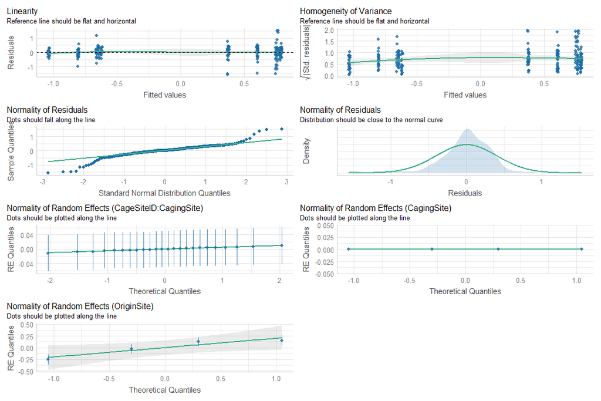

```r
mod4 <-
 lme4::lmer(
    GSI.p ~ Sex +
      (1 | CagingSite /  CageSiteID) + (1| OriginSite),
    data = dat2,
    na.action = na.exclude
  )
performance::check_model(mod4)
```

```r
car::Anova(mod4, type = "3")
```

```
## Analysis of Deviance Table (Type III Wald chisquare tests)
##
## Response: GSI.p
##               Chisq Df Pr(>Chisq)
## (Intercept)  37.318  1  1.004e-09 ***
## Sex         673.900  1  < 2.2e-16 ***
## ---
## Signif. codes:  0 '***' 0.001 '**' 0.01 '*' 0.05 '.' 0.1 ' ' 1
```

```r
summary(mod4)
```

```
## Linear mixed model fit by REML ['lmerMod']
## Formula: GSI.p ~ Sex + (1 | CagingSite/CageSiteID) + (1 | OriginSite)
##    Data: dat2
##
## REML criterion at convergence: 270.5
##
## Scaled residuals:
##     Min      1Q  Median      3Q     Max
## -3.8345 -0.3850  0.0610  0.5162  3.7582
##
## Random effects:
##  Groups                Name        Variance  Std.Dev.
##  CageSiteID:CagingSite (Intercept) 0.0006987 0.02643
##  CagingSite            (Intercept) 0.0000000 0.00000
##  OriginSite            (Intercept) 0.0380456 0.19505
##  Residual                          0.1658745 0.40728
## Number of obs: 244, groups:
## CageSiteID:CagingSite, 24; CagingSite, 4; OriginSite, 4
##
## Fixed effects:
##             Estimate Std. Error t value
## (Intercept)  0.63031    0.10318   6.109
## SexM        -1.40539    0.05414 -25.960
##
## Correlation of Fixed Effects:
##      (Intr)
## SexM -0.200
## optimizer (nloptwrap) convergence code: 0 (OK)
## boundary (singular) fit: see ?isSingular
```

```r
modGSI <- mod4
RmodGSI <- MuMIn::r.squaredGLMM(modGSI)
```

The treatments has no effect on GSI but the GSI is higher in females. Represent the relation between fish sex and GSI

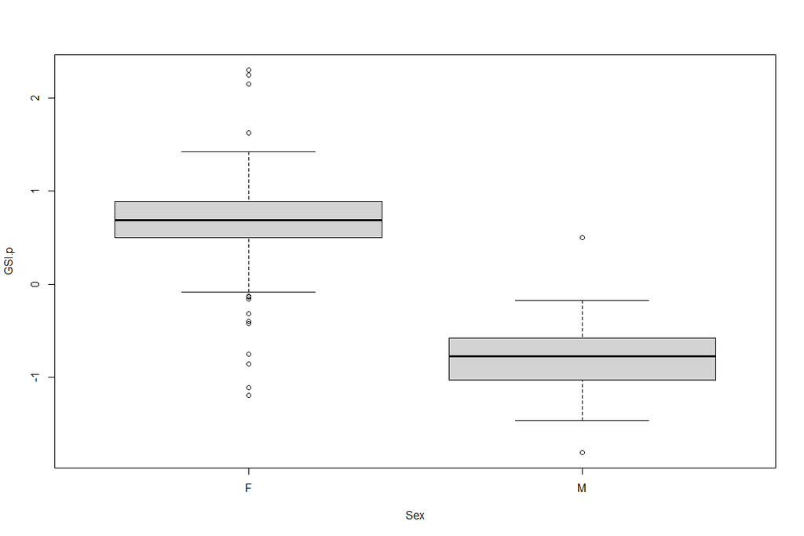

```r
boxplot(GSI.p ~ Sex, data = dat2)
```

Here, there is no interaction, and hence no posthoc test nor parallelism test to conduct

## 5.15 Summary of the best models for traits excepted gene expression (Table 3 from the manuscript)

The following table report the results of the best models tested above, this table correspond to the Table 3 in the manuscript. Excepted for the survival (GLM), the table report the marginal and conditional Rsquared (R2m and R2c respectively).

|  | Estimate | Std. Error | t or z value | df | Chisq | p.value |
| --- | --- | --- | --- | --- | --- | --- |
| **Survival \| n = 268** |  |  |  |  |  |  |
| Intercept | -19.57 | 1355 | -0.01444 | NA | NA | NA |
| Transplant | 16.08 | 1355 | 0.01187 | 1 | 2.681 | 0.1016 |
| Origin | 18.31 | 1355 | 0.01352 | 1 | 21.99 | <0.0001 |
| Transplant : Origin | -17.88 | 1355 | -0.01319 | 1 | 6.591 | <0.05 |
| **Bioaccumulation \| n = 248 \| R2m = 0.0498 \| R2c = 0.385** |  |  |  |  |  |  |
| Intercept | 0.007861 | 0.957 | 0.008214 | 1 | 0.00006747 | 0.9934 |
| Transplant | 0.3576 | 1.353 | 0.2644 | 1 | 0.06989 | 0.7915 |
| Origin | 0.4993 | 0.3524 | 1.417 | 1 | 2.008 | 0.1565 |
| Imm. challenge | 0.18 | 0.3251 | 0.5536 | 1 | 0.3065 | 0.5799 |
| Transplant : Origin | -1.088 | 0.4908 | -2.217 | 1 | 4.913 | <0.05 |
| Transplant : imm. Challenge | -0.9721 | 0.4525 | -2.148 | 1 | 4.616 | <0.05 |
| **Oxidative stress index \| n = 166 \| R2m = 0.0629 \| R2c = 0.258** |  |  |  |  |  |  |
| Intercept | 3.539 | 0.3549 | 9.972 | 1 | 99.43 | <0.0001 |
| Size | -0.1011 | 0.03331 | -3.034 | 1 | 9.208 | <0.01 |
| **Oxidative damage \| n = 179 \| R2m = 0.0837 \| R2c = 0.34** |  |  |  |  |  |  |
| Intercept | 2.067 | 0.2458 | 8.41 | 1 | 70.73 | <0.0001 |
| Size | -0.08377 | 0.02266 | -3.697 | 1 | 13.67 | <0.01 |
| **Antioxidant capacity \| n = 169 \| R2m = 0.0502 \| R2c = 0.0661** |  |  |  |  |  |  |
| Intercept | 11.34 | 0.1632 | 69.5 | 1 | 4830 | <0.0001 |
| Origin | -0.558 | 0.236 | -2.365 | 1 | 5.592 | <0.05 |
| **Local immune response \| n = 249 \| R2m = 0.409 \| R2c = 0.492** |  |  |  |  |  |  |
| Intercept | 26.2 | 2.425 | 10.8 | 1 | 116.7 | <0.0001 |
| Imm. challenge | -23.45 | 1.663 | -14.1 | 1 | 198.8 | <0.0001 |
| **NL inflammatory immune response \| n = 229 \| R2m = 0.0714 \| R2c = 0.167** |  |  |  |  |  |  |
| Intercept | 0.007545 | 0.01495 | 0.5047 | 1 | 0.2548 | 0.6137 |
| Transplant | -0.007363 | 0.004626 | -1.592 | 1 | 2.533 | 0.1115 |
| Origin | -0.01093 | 0.009096 | -1.201 | 1 | 1.443 | 0.2296 |
| Size | 0.003648 | 0.001352 | 2.698 | 1 | 7.281 | <0.01 |
| Transplant : Origin | 0.0155 | 0.006743 | 2.298 | 1 | 5.282 | <0.05 |
| **Available energy \| n = 243 \| R2m = 0.13 \| R2c = 0.256** |  |  |  |  |  |  |
| Intercept | 8.38 | 0.09567 | 87.59 | 1 | 7673 | <0.0001 |
| Transplant | 0.1501 | 0.08771 | 1.712 | 1 | 2.93 | 0.08697 |
| Origin | -0.0398 | 0.1166 | -0.3412 | 1 | 0.1164 | 0.7329 |
| Transplant : Origin | -0.3017 | 0.07706 | -3.915 | 1 | 15.33 | <0.0001 |
| **Daily mass change \| n = 252 \| R2m = 0.028 \| R2c = 0.47** |  |  |  |  |  |  |
| Intercept | 1.202 | 0.1772 | 6.786 | 1 | 46.05 | <0.0001 |
| Transplant | 0.07397 | 0.2505 | 0.2953 | 1 | 0.08721 | 0.7678 |
| Origin | 0.05348 | 0.07005 | 0.7633 | 1 | 0.5827 | 0.4453 |
| Transplant : Origin | -0.2174 | 0.09809 | -2.216 | 1 | 4.911 | <0.05 |
| **HSI \| n = 247 \| R2m = 0.0211 \| R2c = 0.407** |  |  |  |  |  |  |
| Intercept | 0.1016 | 0.2339 | 0.4342 | 1 | 0.1886 | 0.6641 |
| Size | -0.04355 | 0.01992 | -2.186 | 1 | 4.781 | <0.05 |
| **GSI \| n = 244 \| R2m = 0.696 \| R2c = 0.753** |  |  |  |  |  |  |
| Intercept | 0.6303 | 0.1032 | 6.109 | 1 | 37.32 | <0.0001 |
| Sex | -1.405 | 0.05414 | -25.96 | 1 | 673.9 | <0.0001 |

## 5.16 Genes expression

The summary of the results of the best models selected below is reported in Table 4 from the manuscript and is also available in the section “Summary of the best models for gene expression (Table 4 from the manuscript)”

### 5.16.1 Mtl

#### 5.16.1.1 Check the data

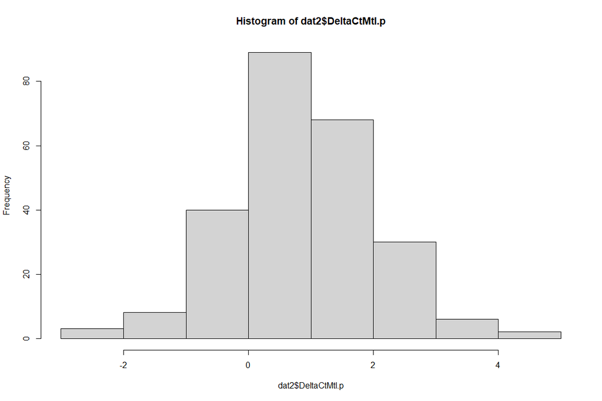

```r
dat2 = dat1[is.na(dat1$DeltaCtMtl) == F, ]
# transform variable to approx. normality
dat2$DeltaCtMtl.p <-
  bimixt::boxcox(dat2$DeltaCtMtl, car::powerTransform(dat2$DeltaCtMtl)$lambda)
hist(dat2$DeltaCtMtl.p)
```

#### 5.16.1.2 Visualize

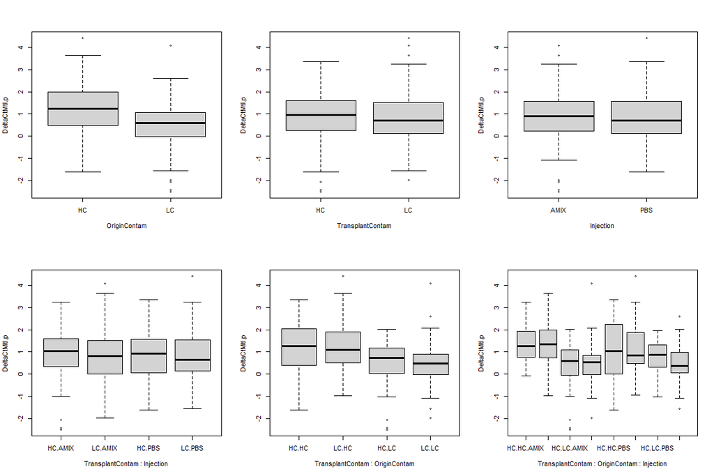

```r
par(mfrow=c(2,3))
boxplot(DeltaCtMtl.p ~ OriginContam, data = dat2)
boxplot(DeltaCtMtl.p ~ TransplantContam, data = dat2)
boxplot(DeltaCtMtl.p ~ Injection, data = dat2)
boxplot(DeltaCtMtl.p ~ TransplantContam * Injection, data = dat2)
boxplot(DeltaCtMtl.p ~ TransplantContam * OriginContam, data = dat2)
boxplot(DeltaCtMtl.p ~ TransplantContam * OriginContam * Injection, data = dat2)
```

#### 5.16.1.3 Build the full model

```r
modfull <-
 lme4::lmer(
    DeltaCtMtl.p ~ (TransplantContam + OriginContam + Injection) ^ 3 +  SizeEnd +
      (1 | CagingSite /  CageSiteID) + (1| OriginSite),
    data = dat2,
    na.action = na.exclude
  )
car::Anova(modfull, type = "3")
```

```
## Analysis of Deviance Table (Type III Wald chisquare tests)
##
## Response: DeltaCtMtl.p
##                                           Chisq Df Pr(>Chisq)
## (Intercept)                             10.2927  1   0.001336 **
## TransplantContam                         0.2395  1   0.624548
## OriginContam                             6.7105  1   0.009585 **
## Injection                                1.2214  1   0.269086
## SizeEnd                                  1.3946  1   0.237623
## TransplantContam:OriginContam            0.1196  1   0.729470
## TransplantContam:Injection               0.3075  1   0.579197
## OriginContam:Injection                   3.4508  1   0.063221 .
## TransplantContam:OriginContam:Injection  1.0149  1   0.313739
## ---
## Signif. codes:  0 '***' 0.001 '**' 0.01 '*' 0.05 '.' 0.1 ' ' 1
```

```r
summary(modfull)
```

```
## Linear mixed model fit by REML ['lmerMod']
## Formula: DeltaCtMtl.p ~ (TransplantContam + OriginContam + Injection)^3 +
##     SizeEnd + (1 | CagingSite/CageSiteID) + (1 | OriginSite)
##    Data: dat2
##
## REML criterion at convergence: 738.2
##
## Scaled residuals:
##     Min      1Q  Median      3Q     Max
## -2.4967 -0.5453  0.0038  0.5515  3.3103
##
## Random effects:
##  Groups                Name        Variance Std.Dev.
##  CageSiteID:CagingSite (Intercept) 0.03839  0.1959
##  CagingSite            (Intercept) 0.00000  0.0000
##  OriginSite            (Intercept) 0.07785  0.2790
##  Residual                          1.10408  1.0508
## Number of obs: 246, groups:
## CageSiteID:CagingSite, 24; CagingSite, 4; OriginSite, 4
##
## Fixed effects:
##                                                Estimate Std. Error t value
## (Intercept)                                     2.03364    0.63388   3.208
## TransplantContamLC                             -0.13847    0.28294  -0.489
## OriginContamLC                                 -1.03660    0.40016  -2.590
## InjectionPBS                                   -0.29320    0.26530  -1.105
## SizeEnd                                        -0.06670    0.05648  -1.181
## TransplantContamLC:OriginContamLC               0.13920    0.40250   0.346
## TransplantContamLC:InjectionPBS                 0.20641    0.37221   0.555
## OriginContamLC:InjectionPBS                     0.71604    0.38546   1.858
## TransplantContamLC:OriginContamLC:InjectionPBS -0.54224    0.53825  -1.007
##
## Correlation of Fixed Effects:
##             (Intr) TrnCLC OrgCLC InjPBS SizEnd TrCLC:OCLC TCLC:I OCLC:I
## TrnsplntCLC -0.267
## OrignCntmLC -0.341  0.355
## InjectinPBS -0.211  0.446  0.316
## SizeEnd     -0.896  0.049  0.033  0.013
## TrnCLC:OCLC  0.132 -0.700 -0.509 -0.313  0.028
## TrnCLC:IPBS  0.138 -0.636 -0.224 -0.712  0.004  0.447
## OrgCLC:IPBS  0.144 -0.307 -0.448 -0.688 -0.008  0.445      0.490
## TCLC:OCLC:I -0.091  0.439  0.320  0.493 -0.008 -0.628     -0.692 -0.716
## optimizer (nloptwrap) convergence code: 0 (OK)
## boundary (singular) fit: see ?isSingular
```

#### 5.16.1.4 Refining the model

```r
mod2 <-
 lme4::lmer(
    DeltaCtMtl.p ~ (TransplantContam + OriginContam + Injection) ^ 2 +  SizeEnd +
      (1 | CagingSite /  CageSiteID) + (1| OriginSite),
    data = dat2,
    na.action = na.exclude
  )
car::Anova(mod2, type = "3")
```

```
## Analysis of Deviance Table (Type III Wald chisquare tests)
##
## Response: DeltaCtMtl.p
##                                Chisq Df Pr(>Chisq)
## (Intercept)                   9.7828  1   0.001762 **
## TransplantContam              0.0026  1   0.959182
## OriginContam                  5.7677  1   0.016323 *
## Injection                     0.4896  1   0.484121
## SizeEnd                       1.4036  1   0.236114
## TransplantContam:OriginContam 0.1378  1   0.710449
## TransplantContam:Injection    0.0394  1   0.842634
## OriginContam:Injection        2.6489  1   0.103624
## ---
## Signif. codes:  0 '***' 0.001 '**' 0.01 '*' 0.05 '.' 0.1 ' ' 1
```

```r
summary(mod2)
```

```
## Linear mixed model fit by REML ['lmerMod']
## Formula: DeltaCtMtl.p ~ (TransplantContam + OriginContam + Injection)^2 +
##     SizeEnd + (1 | CagingSite/CageSiteID) + (1 | OriginSite)
##    Data: dat2
##
## REML criterion at convergence: 739.8
##
## Scaled residuals:
##     Min      1Q  Median      3Q     Max
## -2.5664 -0.5191 -0.0122  0.5910  3.3659
##
## Random effects:
##  Groups                Name        Variance Std.Dev.
##  CageSiteID:CagingSite (Intercept) 0.03628  0.1905
##  CagingSite            (Intercept) 0.00000  0.0000
##  OriginSite            (Intercept) 0.07756  0.2785
##  Residual                          1.10544  1.0514
## Number of obs: 246, groups:
## CageSiteID:CagingSite, 24; CagingSite, 4; OriginSite, 4
##
## Fixed effects:
##                                   Estimate Std. Error t value
## (Intercept)                        1.97302    0.63081   3.128
## TransplantContamLC                -0.01294    0.25290  -0.051
## OriginContamLC                    -0.90740    0.37783  -2.402
## InjectionPBS                      -0.16163    0.23101  -0.700
## SizeEnd                           -0.06690    0.05647  -1.185
## TransplantContamLC:OriginContamLC -0.11545    0.31098  -0.371
## TransplantContamLC:InjectionPBS   -0.05341    0.26902  -0.199
## OriginContamLC:InjectionPBS        0.43825    0.26927   1.628
##
## Correlation of Fixed Effects:
##             (Intr) TrnCLC OrgCLC InjPBS SizEnd TCLC:O TCLC:I
## TrnsplntCLC -0.253
## OrignCntmLC -0.330  0.250
## InjectinPBS -0.192  0.296  0.192
## SizeEnd     -0.901  0.058  0.038  0.019
## TrnCLC:OCLC  0.096 -0.605 -0.416 -0.005  0.029
## TrnCLC:IPBS  0.105 -0.514 -0.004 -0.592 -0.002  0.022
## OrgCLC:IPBS  0.114  0.012 -0.332 -0.552 -0.019 -0.009 -0.009
## optimizer (nloptwrap) convergence code: 0 (OK)
## boundary (singular) fit: see ?isSingular
```

#### 5.16.1.5 Refining the model

```r
mod3 <-
 lme4::lmer(
    DeltaCtMtl.p ~ TransplantContam + OriginContam + Injection +  SizeEnd +
      (1 | CagingSite /  CageSiteID) + (1| OriginSite),
    data = dat2,
    na.action = na.exclude
  )
car::Anova(mod3, type = "3")
```

```
## Analysis of Deviance Table (Type III Wald chisquare tests)
##
## Response: DeltaCtMtl.p
##                   Chisq Df Pr(>Chisq)
## (Intercept)      9.2349  1   0.002374 **
## TransplantContam 0.3748  1   0.540388
## OriginContam     5.6894  1   0.017068 *
## Injection        0.0229  1   0.879776
## SizeEnd          1.2851  1   0.256945
## ---
## Signif. codes:  0 '***' 0.001 '**' 0.01 '*' 0.05 '.' 0.1 ' ' 1
```

```r
summary(mod3)
```

```
## Linear mixed model fit by REML ['lmerMod']
## Formula: DeltaCtMtl.p ~ TransplantContam + OriginContam + Injection +
##     SizeEnd + (1 | CagingSite/CageSiteID) + (1 | OriginSite)
##    Data: dat2
##
## REML criterion at convergence: 740.5
##
## Scaled residuals:
##     Min      1Q  Median      3Q     Max
## -2.6909 -0.5467 -0.0089  0.5865  3.2568
##
## Random effects:
##  Groups                Name        Variance Std.Dev.
##  CageSiteID:CagingSite (Intercept) 0.03112  0.1764
##  CagingSite            (Intercept) 0.00000  0.0000
##  OriginSite            (Intercept) 0.07763  0.2786
##  Residual                          1.10777  1.0525
## Number of obs: 246, groups:
## CageSiteID:CagingSite, 24; CagingSite, 4; OriginSite, 4
##
## Fixed effects:
##                    Estimate Std. Error t value
## (Intercept)         1.88316    0.61968   3.039
## TransplantContamLC -0.09415    0.15378  -0.612
## OriginContamLC     -0.75883    0.31814  -2.385
## InjectionPBS        0.02036    0.13462   0.151
## SizeEnd            -0.06396    0.05642  -1.134
##
## Correlation of Fixed Effects:
##             (Intr) TrnCLC OrgCLC InjPBS
## TrnsplntCLC -0.236
## OrignCntmLC -0.303  0.003
## InjectinPBS -0.116 -0.007  0.012
## SizeEnd     -0.918  0.123  0.052  0.013
## optimizer (nloptwrap) convergence code: 0 (OK)
## boundary (singular) fit: see ?isSingular
```

#### 5.16.1.6 Refining the model

```r
mod4 <-
 lme4::lmer(
    DeltaCtMtl.p ~  OriginContam +
      (1 | CagingSite /  CageSiteID) + (1| OriginSite),
    data = dat2,
    na.action = na.exclude
  )

car::Anova(mod4, type = "3")
```

```
## Analysis of Deviance Table (Type III Wald chisquare tests)
##
## Response: DeltaCtMtl.p
##                Chisq Df Pr(>Chisq)
## (Intercept)  29.5067  1  5.572e-08 ***
## OriginContam  5.4731  1    0.01931 *
## ---
## Signif. codes:  0 '***' 0.001 '**' 0.01 '*' 0.05 '.' 0.1 ' ' 1
```

```r
summary(mod4)
```

```
## Linear mixed model fit by REML ['lmerMod']
## Formula: DeltaCtMtl.p ~ OriginContam + (1 | CagingSite/CageSiteID) + (1 |
##     OriginSite)
##    Data: dat2
##
## REML criterion at convergence: 734
##
## Scaled residuals:
##     Min      1Q  Median      3Q     Max
## -2.6964 -0.5456  0.0223  0.5869  3.2087
##
## Random effects:
##  Groups                Name        Variance  Std.Dev.
##  CageSiteID:CagingSite (Intercept) 2.107e-02 1.451e-01
##  CagingSite            (Intercept) 1.535e-10 1.239e-05
##  OriginSite            (Intercept) 7.854e-02 2.802e-01
##  Residual                          1.108e+00 1.052e+00
## Number of obs: 246, groups:
## CageSiteID:CagingSite, 24; CagingSite, 4; OriginSite, 4
##
## Fixed effects:
##                Estimate Std. Error t value
## (Intercept)      1.2111     0.2229   5.432
## OriginContamLC  -0.7403     0.3164  -2.339
##
## Correlation of Fixed Effects:
##             (Intr)
## OrignCntmLC -0.705
## optimizer (nloptwrap) convergence code: 0 (OK)
## boundary (singular) fit: see ?isSingular
```

Mtl expression is significantly different according to fish origin. More specifically, HC fish have higher Mtl expression than LC fish.

Now that we have identified the best model, add sex as covariate to check whether results are sensitive NB: sample size is reduced when adding sex variable within the model, for this reason the sex effect on results is checked on the final model

#### 5.16.1.7 Test for the sex effect

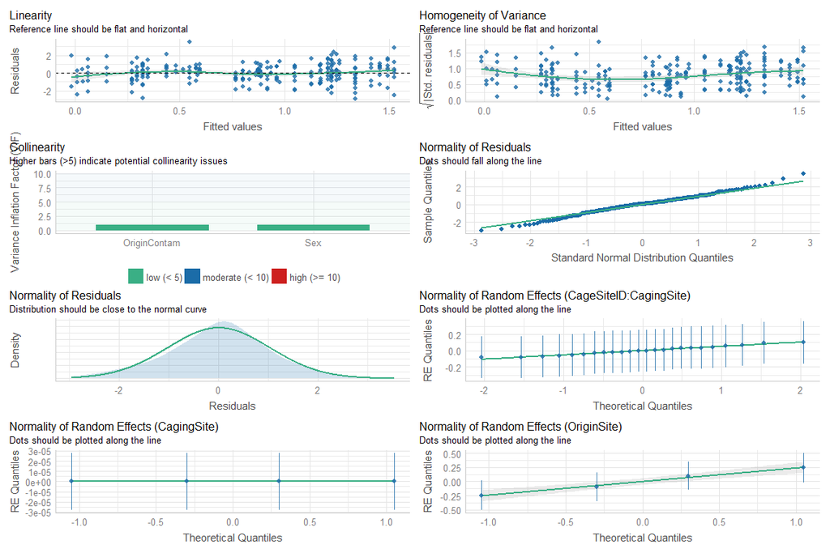

```r
dat2 = dat2[is.na(dat2$Sex) == F, ]
modSex <-
 lme4::lmer(
    DeltaCtMtl.p ~ OriginContam + Sex +
      (1 | CagingSite /  CageSiteID) + (1| OriginSite),
    data = dat2,
    na.action = na.exclude
  )
performance::check_model(modSex)
```

```r
car::Anova(modSex, type = "3")
```

```
## Analysis of Deviance Table (Type III Wald chisquare tests)
##
## Response: DeltaCtMtl.p
##                Chisq Df Pr(>Chisq)
## (Intercept)  31.3296  1  2.177e-08 ***
## OriginContam  5.1233  1    0.02361 *
## Sex           4.2371  1    0.03955 *
## ---
## Signif. codes:  0 '***' 0.001 '**' 0.01 '*' 0.05 '.' 0.1 ' ' 1
```

```r
summary(modSex)
```

```
## Linear mixed model fit by REML ['lmerMod']
## Formula: DeltaCtMtl.p ~ OriginContam + Sex + (1 | CagingSite/CageSiteID) +
##     (1 | OriginSite)
##    Data: dat2
##
## REML criterion at convergence: 728.9
##
## Scaled residuals:
##     Min      1Q  Median      3Q     Max
## -2.8237 -0.5927  0.0607  0.6000  3.3720
##
## Random effects:
##  Groups                Name        Variance  Std.Dev.
##  CageSiteID:CagingSite (Intercept) 2.007e-02 1.417e-01
##  CagingSite            (Intercept) 2.039e-10 1.428e-05
##  OriginSite            (Intercept) 8.545e-02 2.923e-01
##  Residual                          1.093e+00 1.045e+00
## Number of obs: 245, groups:
## CageSiteID:CagingSite, 24; CagingSite, 4; OriginSite, 4
##
## Fixed effects:
##                Estimate Std. Error t value
## (Intercept)      1.3248     0.2367   5.597
## OriginContamLC  -0.7395     0.3267  -2.263
## SexM            -0.2866     0.1392  -2.058
##
## Correlation of Fixed Effects:
##             (Intr) OrgCLC
## OrignCntmLC -0.688
## SexM        -0.234  0.013
## optimizer (nloptwrap) convergence code: 0 (OK)
## boundary (singular) fit: see ?isSingular
```

```r
modMtl <- modSex
RmodMtl <- MuMIn::r.squaredGLMM(modMtl)
```

The sex effect is significant. The modSex is thus the best model. Here, there is no interaction, and hence no posthoc test nor parallelism test to conduct

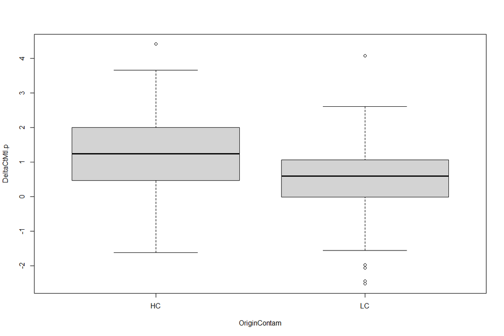

```r
boxplot(DeltaCtMtl.p ~ OriginContam, data = dat2)
```

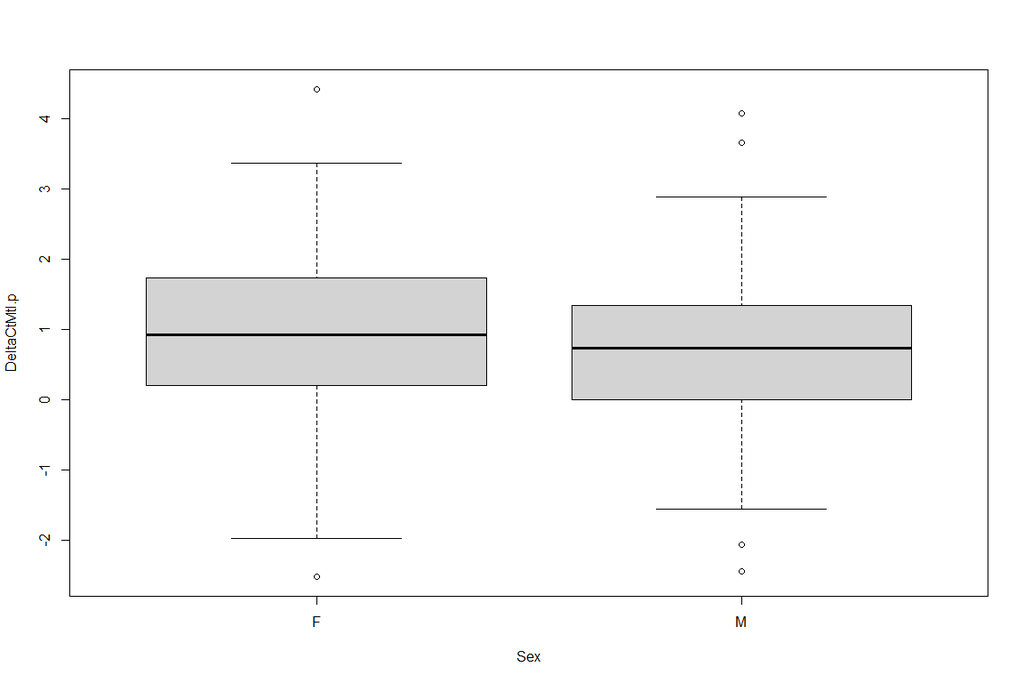

```r
boxplot(DeltaCtMtl.p ~ Sex, data = dat2)
```

```r
# compute mean and Se for LC and HC groups
meanVal <-
  data.frame(
    mean = c(mean(dat2$DeltaCtMtl.p[which(dat2$OriginContam == "LC")]),
             mean(dat2$DeltaCtMtl.p[which(dat2$OriginContam == "HC")])),
    Se = c(
      sd(dat2$DeltaCtMtl.p[which(dat2$OriginContam == "LC")]) / sqrt(length(dat2$DeltaCtMtl.p[which(dat2$OriginContam == "LC")])),
      sd(dat2$DeltaCtMtl.p[which(dat2$OriginContam == "HC")]) / sqrt(length(dat2$DeltaCtMtl.p[which(dat2$OriginContam == "HC")]))
    ),
    row.names = c("LC", "HC"),
    n = c(length(dat2$DeltaCtMtl.p[which(dat2$OriginContam == "LC")]),
    length(dat2$DeltaCtMtl.p[which(dat2$OriginContam == "HC")]))
  )

kableExtra::kable_classic(
  kableExtra::kbl(meanVal),
  bootstrap_options = c("striped", "hover", "condensed", "responsive"),
  full_width = F,
  html_font = "arial",
  font_size = 10
)
```

|  | mean | Se | n |
| --- | --- | --- | --- |
| LC | 0.4778226 | 0.0925794 | 117 |
| HC | 1.2116222 | 0.1011425 | 128 |

### 5.16.2 Cat

#### 5.16.2.1 Check the data

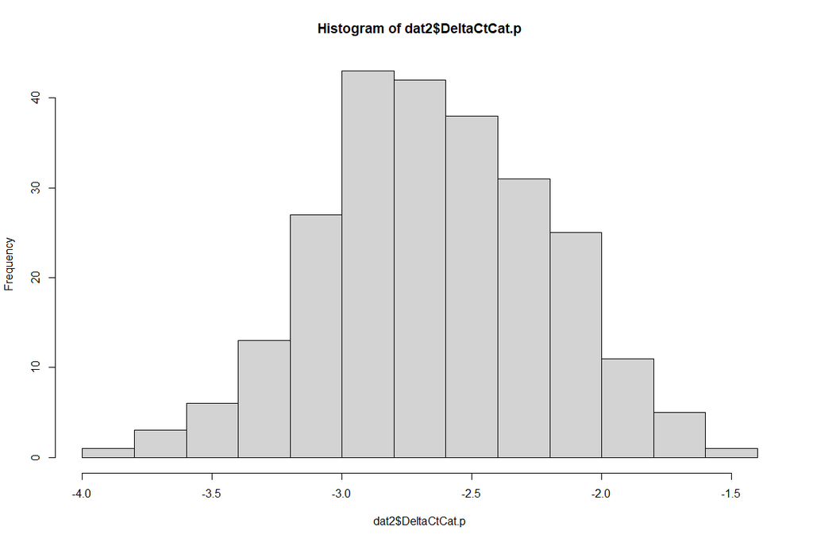

```r
dat2 = dat1[is.na(dat1$DeltaCtCat) == F, ]
# transform variable to approx. normality
dat2$DeltaCtCat.p <-
  bimixt::boxcox(dat2$DeltaCtCat, car::powerTransform(dat2$DeltaCtCat)$lambda)
hist(dat2$DeltaCtCat.p)
```

#### 5.16.2.2 Visualize

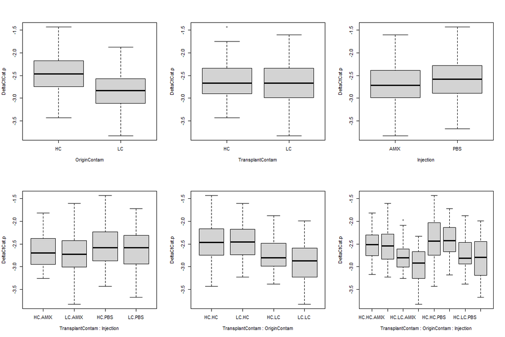

```r
par(mfrow=c(2,3))
boxplot(DeltaCtCat.p ~ OriginContam, data = dat2)
boxplot(DeltaCtCat.p ~ TransplantContam, data = dat2)
boxplot(DeltaCtCat.p ~ Injection, data = dat2)
boxplot(DeltaCtCat.p ~ TransplantContam * Injection, data = dat2)
boxplot(DeltaCtCat.p ~ TransplantContam * OriginContam, data = dat2)
boxplot(DeltaCtCat.p ~ TransplantContam * OriginContam * Injection, data = dat2)
```

#### 5.16.2.3 Build the full model

```r
modfull <-
 lme4::lmer(
    DeltaCtCat.p ~ (TransplantContam + OriginContam + Injection) ^ 3 +  SizeEnd +
      (1 | CagingSite /  CageSiteID) + (1| OriginSite),
    data = dat2,
    na.action = na.exclude
  )
car::Anova(modfull, type = "3")
```

```
## Analysis of Deviance Table (Type III Wald chisquare tests)
##
## Response: DeltaCtCat.p
##                                            Chisq Df Pr(>Chisq)
## (Intercept)                             126.6869  1  < 2.2e-16 ***
## TransplantContam                          0.1362  1   0.712039
## OriginContam                              0.5148  1   0.473082
## Injection                                 3.3333  1   0.067889 .
## SizeEnd                                   7.2135  1   0.007236 **
## TransplantContam:OriginContam             3.9098  1   0.048005 *
## TransplantContam:Injection                0.0240  1   0.876997
## OriginContam:Injection                    1.3774  1   0.240550
## TransplantContam:OriginContam:Injection   0.9025  1   0.342112
## ---
## Signif. codes:  0 '***' 0.001 '**' 0.01 '*' 0.05 '.' 0.1 ' ' 1
```

```r
summary(modfull)
```

```
## Linear mixed model fit by REML ['lmerMod']
## Formula: DeltaCtCat.p ~ (TransplantContam + OriginContam + Injection)^3 +
##     SizeEnd + (1 | CagingSite/CageSiteID) + (1 | OriginSite)
##    Data: dat2
##
## REML criterion at convergence: 144.8
##
## Scaled residuals:
##      Min       1Q   Median       3Q      Max
## -2.46127 -0.65109  0.00029  0.65431  2.80017
##
## Random effects:
##  Groups                Name        Variance  Std.Dev.
##  CageSiteID:CagingSite (Intercept) 0.0001937 0.01392
##  CagingSite            (Intercept) 0.0053361 0.07305
##  OriginSite            (Intercept) 0.0745272 0.27300
##  Residual                          0.0899628 0.29994
## Number of obs: 246, groups:
## CageSiteID:CagingSite, 24; CagingSite, 4; OriginSite, 4
##
## Fixed effects:
##                                                Estimate Std. Error t value
## (Intercept)                                    -3.01890    0.26821 -11.256
## TransplantContamLC                              0.03849    0.10429   0.369
## OriginContamLC                                 -0.20325    0.28328  -0.717
## InjectionPBS                                    0.13817    0.07568   1.826
## SizeEnd                                         0.04571    0.01702   2.686
## TransplantContamLC:OriginContamLC              -0.20956    0.10598  -1.977
## TransplantContamLC:InjectionPBS                -0.01643    0.10617  -0.155
## OriginContamLC:InjectionPBS                    -0.12905    0.10996  -1.174
## TransplantContamLC:OriginContamLC:InjectionPBS  0.14586    0.15353   0.950
##
## Correlation of Fixed Effects:
##             (Intr) TrnCLC OrgCLC InjPBS SizEnd TrCLC:OCLC TCLC:I OCLC:I
## TrnsplntCLC -0.218
## OrignCntmLC -0.536  0.094
## InjectinPBS -0.142  0.346  0.127
## SizeEnd     -0.638  0.038  0.014  0.012
## TrnCLC:OCLC  0.077 -0.499 -0.190 -0.340  0.032
## TrnCLC:IPBS  0.094 -0.492 -0.091 -0.713  0.003  0.485
## OrgCLC:IPBS  0.096 -0.238 -0.181 -0.688 -0.005  0.483      0.490
## TCLC:OCLC:I -0.061  0.340  0.129  0.493 -0.009 -0.681     -0.691 -0.716
```

#### 5.16.2.4 Refining the model

```r
mod2 <-
 lme4::lmer(
    DeltaCtCat.p ~ (TransplantContam + OriginContam + Injection) ^ 2 +  SizeEnd +
      (1 | CagingSite /  CageSiteID) + (1| OriginSite),
    data = dat2,
    na.action = na.exclude
  )
car::Anova(mod2, type = "3")
```

```
## Analysis of Deviance Table (Type III Wald chisquare tests)
##
## Response: DeltaCtCat.p
##                                  Chisq Df Pr(>Chisq)
## (Intercept)                   125.8848  1  < 2.2e-16 ***
## TransplantContam                0.0025  1   0.960361
## OriginContam                    0.7176  1   0.396928
## Injection                       2.4353  1   0.118634
## SizeEnd                         7.2547  1   0.007072 **
## TransplantContam:OriginContam   3.2785  1   0.070194 .
## TransplantContam:Injection      0.4832  1   0.486969
## OriginContam:Injection          0.4998  1   0.479585
## ---
## Signif. codes:  0 '***' 0.001 '**' 0.01 '*' 0.05 '.' 0.1 ' ' 1
```

```r
summary(mod2)
```

```
## Linear mixed model fit by REML ['lmerMod']
## Formula: DeltaCtCat.p ~ (TransplantContam + OriginContam + Injection)^2 +
##     SizeEnd + (1 | CagingSite/CageSiteID) + (1 | OriginSite)
##    Data: dat2
##
## REML criterion at convergence: 143.8
##
## Scaled residuals:
##      Min       1Q   Median       3Q      Max
## -2.41117 -0.62645 -0.00176  0.63321  2.86447
##
## Random effects:
##  Groups                Name        Variance  Std.Dev.
##  CageSiteID:CagingSite (Intercept) 0.0002758 0.01661
##  CagingSite            (Intercept) 0.0053064 0.07284
##  OriginSite            (Intercept) 0.0745138 0.27297
##  Residual                          0.0898674 0.29978
## Number of obs: 246, groups:
## CageSiteID:CagingSite, 24; CagingSite, 4; OriginSite, 4
##
## Fixed effects:
##                                    Estimate Std. Error t value
## (Intercept)                       -3.003235   0.267672 -11.220
## TransplantContamLC                 0.004873   0.098038   0.050
## OriginContamLC                    -0.237975   0.280922  -0.847
## InjectionPBS                       0.102721   0.065825   1.561
## SizeEnd                            0.045826   0.017014   2.693
## TransplantContamLC:OriginContamLC -0.141069   0.077910  -1.811
## TransplantContamLC:InjectionPBS    0.053295   0.076668   0.695
## OriginContamLC:InjectionPBS       -0.054245   0.076729  -0.707
##
## Correlation of Fixed Effects:
##             (Intr) TrnCLC OrgCLC InjPBS SizEnd TCLC:O TCLC:I
## TrnsplntCLC -0.211
## OrignCntmLC -0.533  0.054
## InjectinPBS -0.129  0.218  0.074
## SizeEnd     -0.639  0.043  0.015  0.018
## TrnCLC:OCLC  0.049 -0.390 -0.140 -0.007  0.035
## TrnCLC:IPBS  0.072 -0.379 -0.002 -0.592 -0.004  0.026
## OrgCLC:IPBS  0.075  0.008 -0.127 -0.552 -0.016 -0.010 -0.009
```

#### 5.16.2.5 Refining the model

```r
mod3 <-
 lme4::lmer(
    DeltaCtCat.p ~ TransplantContam + OriginContam + Injection +  SizeEnd +
      (1 | CagingSite /  CageSiteID) + (1| OriginSite),
    data = dat2,
    na.action = na.exclude
  )
car::Anova(mod3, type = "3")
```

```
## Analysis of Deviance Table (Type III Wald chisquare tests)
##
## Response: DeltaCtCat.p
##                     Chisq Df Pr(>Chisq)
## (Intercept)      126.0929  1  < 2.2e-16 ***
## TransplantContam   0.2040  1   0.651486
## OriginContam       1.4996  1   0.220734
## Injection          7.4079  1   0.006494 **
## SizeEnd            7.4541  1   0.006329 **
## ---
## Signif. codes:  0 '***' 0.001 '**' 0.01 '*' 0.05 '.' 0.1 ' ' 1
```

```r
summary(mod3)
```

```
## Linear mixed model fit by REML ['lmerMod']
## Formula: DeltaCtCat.p ~ TransplantContam + OriginContam + Injection +
##     SizeEnd + (1 | CagingSite/CageSiteID) + (1 | OriginSite)
##    Data: dat2
##
## REML criterion at convergence: 138.2
##
## Scaled residuals:
##      Min       1Q   Median       3Q      Max
## -2.52701 -0.68507 -0.06431  0.63540  2.78093
##
## Random effects:
##  Groups                Name        Variance Std.Dev.
##  CageSiteID:CagingSite (Intercept) 0.001279 0.03576
##  CagingSite            (Intercept) 0.005106 0.07145
##  OriginSite            (Intercept) 0.073363 0.27086
##  Residual                          0.089638 0.29940
## Number of obs: 246, groups:
## CageSiteID:CagingSite, 24; CagingSite, 4; OriginSite, 4
##
## Fixed effects:
##                    Estimate Std. Error t value
## (Intercept)        -2.97561    0.26499 -11.229
## TransplantContamLC -0.03728    0.08254  -0.452
## OriginContamLC     -0.33552    0.27399  -1.225
## InjectionPBS        0.10420    0.03828   2.722
## SizeEnd             0.04647    0.01702   2.730
##
## Correlation of Fixed Effects:
##             (Intr) TrnCLC OrgCLC InjPBS
## TrnsplntCLC -0.198
## OrignCntmLC -0.528  0.001
## InjectinPBS -0.077 -0.004  0.004
## SizeEnd     -0.647  0.066  0.018  0.012
```

#### 5.16.2.6 Refining the model

```r
mod4 <-
 lme4::lmer(
    DeltaCtCat.p ~  Injection + SizeEnd +
      (1 | CagingSite /  CageSiteID) + (1| OriginSite),
    data = dat2,
    na.action = na.exclude
  )
car::Anova(mod4, type = "3")
```

```
## Analysis of Deviance Table (Type III Wald chisquare tests)
##
## Response: DeltaCtCat.p
##                Chisq Df Pr(>Chisq)
## (Intercept) 199.6151  1  < 2.2e-16 ***
## Injection     7.4260  1   0.006429 **
## SizeEnd       7.5935  1   0.005858 **
## ---
## Signif. codes:  0 '***' 0.001 '**' 0.01 '*' 0.05 '.' 0.1 ' ' 1
```

```r
summary(mod4)
```

```
## Linear mixed model fit by REML ['lmerMod']
## Formula: DeltaCtCat.p ~ Injection + SizeEnd + (1 | CagingSite/CageSiteID) +
##     (1 | OriginSite)
##    Data: dat2
##
## REML criterion at convergence: 135.7
##
## Scaled residuals:
##      Min       1Q   Median       3Q      Max
## -2.57273 -0.65230 -0.03892  0.63278  2.82713
##
## Random effects:
##  Groups                Name        Variance Std.Dev.
##  CageSiteID:CagingSite (Intercept) 0.001260 0.03550
##  CagingSite            (Intercept) 0.002643 0.05141
##  OriginSite            (Intercept) 0.085284 0.29204
##  Residual                          0.089642 0.29940
## Number of obs: 246, groups:
## CageSiteID:CagingSite, 24; CagingSite, 4; OriginSite, 4
##
## Fixed effects:
##              Estimate Std. Error t value
## (Intercept)  -3.16488    0.22401 -14.129
## InjectionPBS  0.10433    0.03828   2.725
## SizeEnd       0.04676    0.01697   2.756
##
## Correlation of Fixed Effects:
##             (Intr) InjPBS
## InjectinPBS -0.090
## SizeEnd     -0.740  0.012
```

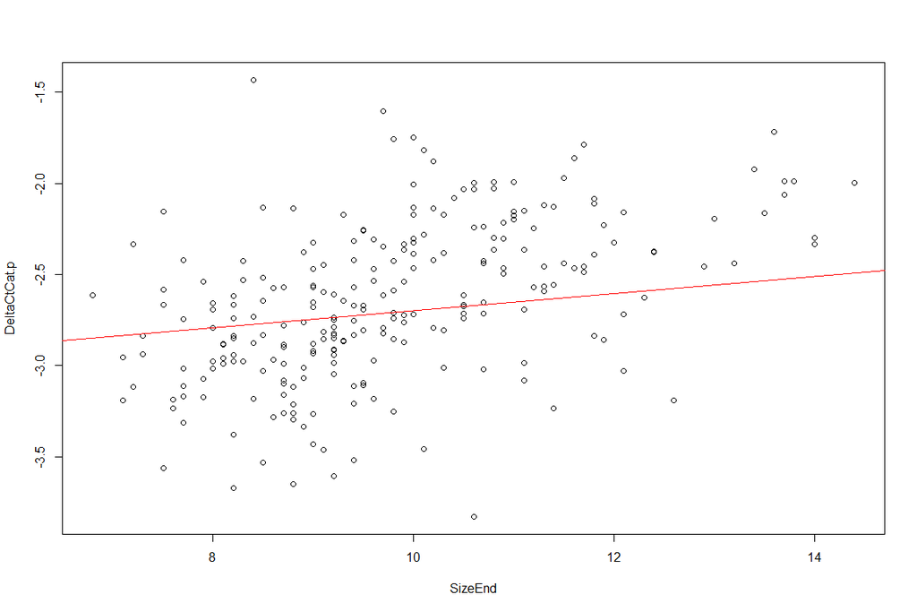

```r
plot(DeltaCtCat.p ~ SizeEnd, data = dat2)
abline(a = -3.16488, b = 0.04676 , col = "red")
```

Now that we have identified the best model, add sex as covariate to check whether results are sensitive NB: sample size is reduced when adding sex variable within the model, for this reason the sex effect on results is checked on the final model

#### 5.16.2.7 Test for the sex effect

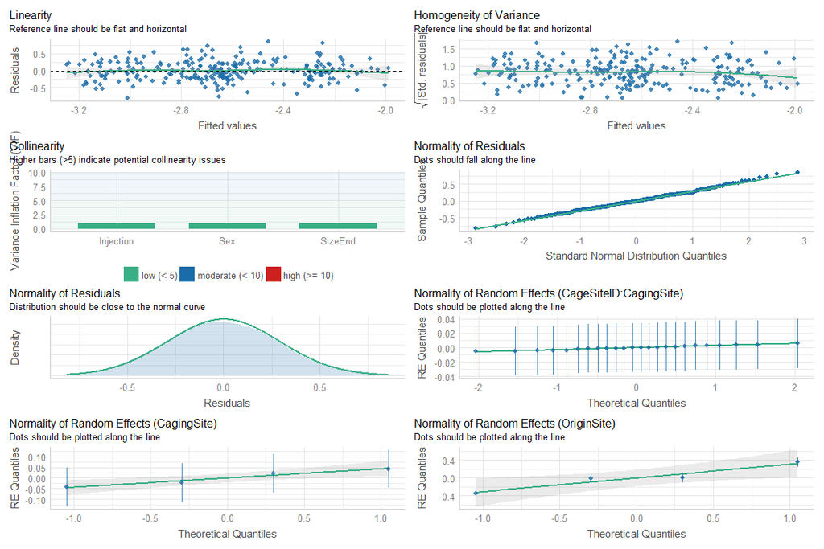

```r
dat2 = dat2[is.na(dat2$Sex) == F, ]
modSex <-
 lme4::lmer(
    DeltaCtCat.p ~ Injection + SizeEnd + Sex +
      (1 | CagingSite /  CageSiteID) + (1| OriginSite),
    data = dat2,
    na.action = na.exclude
  )
performance::check_model(modSex)
```

```r
car::Anova(modSex, type = "3")
```

```
## Analysis of Deviance Table (Type III Wald chisquare tests)
##
## Response: DeltaCtCat.p
##                Chisq Df Pr(>Chisq)
## (Intercept) 205.8893  1  < 2.2e-16 ***
## Injection     7.0398  1   0.007972 **
## SizeEnd       9.3052  1   0.002285 **
## Sex           5.8286  1   0.015767 *
## ---
## Signif. codes:  0 '***' 0.001 '**' 0.01 '*' 0.05 '.' 0.1 ' ' 1
```

```r
summary(modSex)
```

```
## Linear mixed model fit by REML ['lmerMod']
## Formula:
## DeltaCtCat.p ~ Injection + SizeEnd + Sex + (1 | CagingSite/CageSiteID) +
##     (1 | OriginSite)
##    Data: dat2
##
## REML criterion at convergence: 133.1
##
## Scaled residuals:
##      Min       1Q   Median       3Q      Max
## -2.75224 -0.65983 -0.02391  0.65897  2.88861
##
## Random effects:
##  Groups                Name        Variance Std.Dev.
##  CageSiteID:CagingSite (Intercept) 0.000310 0.01761
##  CagingSite            (Intercept) 0.003288 0.05734
##  OriginSite            (Intercept) 0.082352 0.28697
##  Residual                          0.088084 0.29679
## Number of obs: 245, groups:
## CageSiteID:CagingSite, 24; CagingSite, 4; OriginSite, 4
##
## Fixed effects:
##              Estimate Std. Error t value
## (Intercept)  -3.17559    0.22131 -14.349
## InjectionPBS  0.10112    0.03811   2.653
## SizeEnd       0.05157    0.01690   3.050
## SexM         -0.09578    0.03967  -2.414
##
## Correlation of Fixed Effects:
##             (Intr) InjPBS SizEnd
## InjectinPBS -0.088
## SizeEnd     -0.737  0.003
## SexM         0.012  0.074 -0.117
```

```r
modCat<- modSex
RmodCat <- MuMIn::r.squaredGLMM(modCat)
```

The sex effect is significant. The modSex is thus the best model. Here, there is no interaction, and hence no posthoc test nor parallelism test to conduct

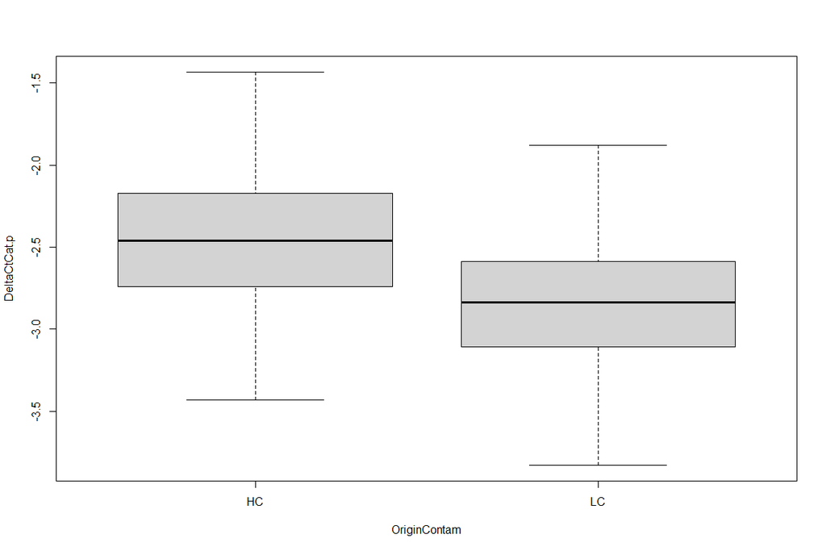

```r
boxplot(DeltaCtCat.p ~ OriginContam, data = dat2)
```

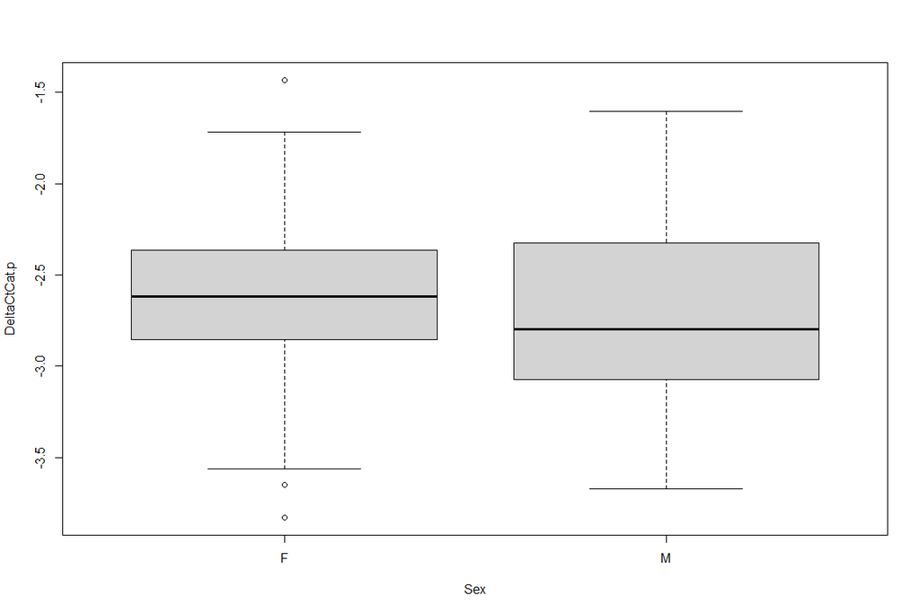

```r
boxplot(DeltaCtCat.p ~ Sex, data = dat2)
```

```r
# compute mean and Se for LC and HC groups
meanVal <-
  data.frame(
    mean = c(mean(dat2$DeltaCtCat.p[which(dat2$Injection == "PBS")]),
             mean(dat2$DeltaCtCat.p[which(dat2$Injection == "AMIX")])),
    Se = c(
      sd(dat2$DeltaCtCat.p[which(dat2$Injection == "PBS")]) / sqrt(length(dat2$DeltaCtCat.p[which(dat2$Injection == "PBS")])),
      sd(dat2$DeltaCtCat.p[which(dat2$Injection == "AMIX")]) / sqrt(length(dat2$DeltaCtCat.p[which(dat2$Injection == "AMIX")]))
    ),
    row.names = c("PBS", "AMIX"),
    n = c(length(dat2$DeltaCtCat.p[which(dat2$Injection == "PBS")]),
    length(dat2$DeltaCtCat.p[which(dat2$Injection == "AMIX")]))
  )

kableExtra::kable_classic(
  kableExtra::kbl(meanVal),
  bootstrap_options = c("striped", "hover", "condensed", "responsive"),
  full_width = F,
  html_font = "arial",
  font_size = 10
)
```

|  | mean | Se | n |
| --- | --- | --- | --- |
| PBS | -2.589656 | 0.0414297 | 116 |
| AMIX | -2.702629 | 0.0358039 | 129 |

### 5.16.3 GPX

#### 5.16.3.1 Check the data

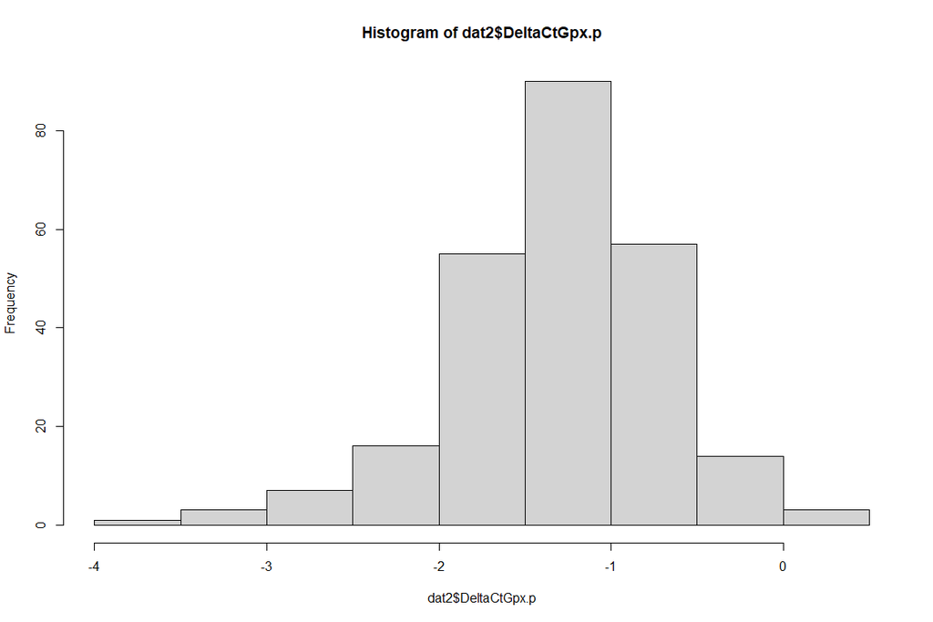

```r
dat2 = dat1[is.na(dat1$DeltaCtGpx) == F, ]
# transform variable to approx. normality
dat2$DeltaCtGpx.p <-
  bimixt::boxcox(dat2$DeltaCtGpx, car::powerTransform(dat2$DeltaCtMtl)$lambda)
hist(dat2$DeltaCtGpx.p)
```

#### 5.16.3.2 Visualize

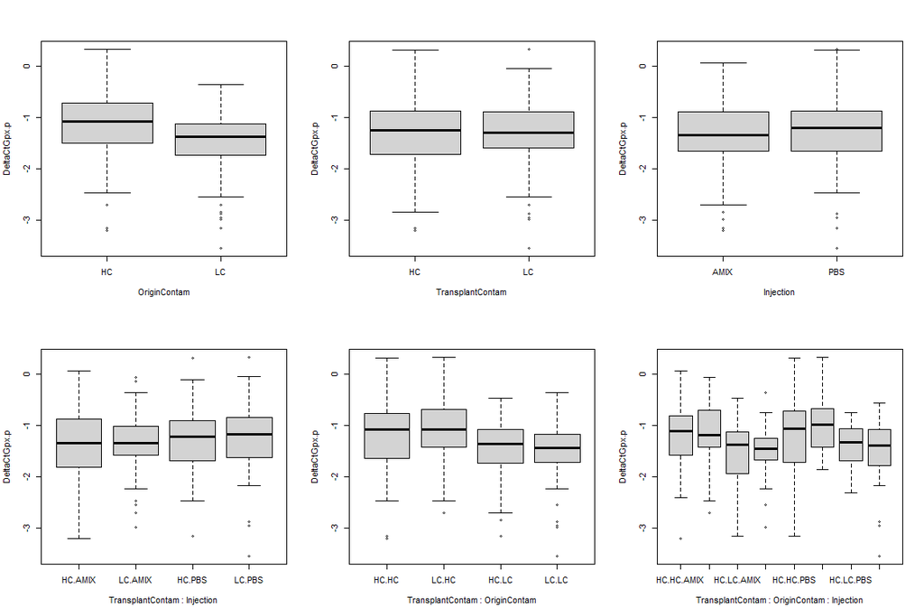

```r
par(mfrow=c(2,3))
boxplot(DeltaCtGpx.p ~ OriginContam, data = dat2)
boxplot(DeltaCtGpx.p ~ TransplantContam, data = dat2)
boxplot(DeltaCtGpx.p ~ Injection, data = dat2)
boxplot(DeltaCtGpx.p ~ TransplantContam * Injection, data = dat2)
boxplot(DeltaCtGpx.p ~ TransplantContam * OriginContam, data = dat2)
boxplot(DeltaCtGpx.p ~ TransplantContam * OriginContam * Injection, data = dat2)
```

#### 5.16.3.3 Build the full model

```r
modfull <-
 lme4::lmer(
    DeltaCtGpx.p ~ (TransplantContam + OriginContam + Injection) ^ 3 +  SizeEnd +
      (1 | CagingSite /  CageSiteID) + (1| OriginSite),
    data = dat2,
    na.action = na.exclude
  )
car::Anova(modfull, type = "3")
```

```
## Analysis of Deviance Table (Type III Wald chisquare tests)
##
## Response: DeltaCtGpx.p
##                                           Chisq Df Pr(>Chisq)
## (Intercept)                             20.8492  1  4.969e-06 ***
## TransplantContam                         0.7396  1     0.3898
## OriginContam                             1.3179  1     0.2510
## Injection                                0.0458  1     0.8306
## SizeEnd                                  1.6136  1     0.2040
## TransplantContam:OriginContam            0.2413  1     0.6233
## TransplantContam:Injection               0.1609  1     0.6883
## OriginContam:Injection                   0.2995  1     0.5842
## TransplantContam:OriginContam:Injection  0.7050  1     0.4011
## ---
## Signif. codes:  0 '***' 0.001 '**' 0.01 '*' 0.05 '.' 0.1 ' ' 1
```

```r
summary(modfull)
```

```
## Linear mixed model fit by REML ['lmerMod']
## Formula: DeltaCtGpx.p ~ (TransplantContam + OriginContam + Injection)^3 +
##     SizeEnd + (1 | CagingSite/CageSiteID) + (1 | OriginSite)
##    Data: dat2
##
## REML criterion at convergence: 467.7
##
## Scaled residuals:
##     Min      1Q  Median      3Q     Max
## -3.3815 -0.5235  0.1590  0.6273  2.6625
##
## Random effects:
##  Groups                Name        Variance Std.Dev.
##  CageSiteID:CagingSite (Intercept) 0.007445 0.08629
##  CagingSite            (Intercept) 0.000000 0.00000
##  OriginSite            (Intercept) 0.029427 0.17154
##  Residual                          0.355216 0.59600
## Number of obs: 246, groups:
## CageSiteID:CagingSite, 24; CagingSite, 4; OriginSite, 4
##
## Fixed effects:
##                                                Estimate Std. Error t value
## (Intercept)                                    -1.65475    0.36240  -4.566
## TransplantContamLC                              0.13352    0.15526   0.860
## OriginContamLC                                 -0.26738    0.23291  -1.148
## InjectionPBS                                    0.03219    0.15044   0.214
## SizeEnd                                         0.04084    0.03215   1.270
## TransplantContamLC:OriginContamLC              -0.10854    0.22097  -0.491
## TransplantContamLC:InjectionPBS                 0.08466    0.21105   0.401
## OriginContamLC:InjectionPBS                     0.11962    0.21859   0.547
## TransplantContamLC:OriginContamLC:InjectionPBS -0.25629    0.30522  -0.840
##
## Correlation of Fixed Effects:
##             (Intr) TrnCLC OrgCLC InjPBS SizEnd TrCLC:OCLC TCLC:I OCLC:I
## TrnsplntCLC -0.258
## OrignCntmLC -0.346  0.334
## InjectinPBS -0.209  0.462  0.308
## SizeEnd     -0.892  0.049  0.032  0.013
## TrnCLC:OCLC  0.124 -0.699 -0.480 -0.324  0.029
## TrnCLC:IPBS  0.137 -0.657 -0.219 -0.713  0.004  0.462
## OrgCLC:IPBS  0.143 -0.318 -0.437 -0.688 -0.007  0.460      0.490
## TCLC:OCLC:I -0.090  0.454  0.312  0.493 -0.008 -0.649     -0.691 -0.716
## optimizer (nloptwrap) convergence code: 0 (OK)
## boundary (singular) fit: see ?isSingular
```

#### 5.16.3.4 Refining the model

```r
mod2 <-
 lme4::lmer(
    DeltaCtGpx.p ~ (TransplantContam + OriginContam + Injection) ^ 2 +  SizeEnd +
      (1 | CagingSite /  CageSiteID) + (1| OriginSite),
    data = dat2,
    na.action = na.exclude
  )
car::Anova(mod2, type = "3")
```

```
## Analysis of Deviance Table (Type III Wald chisquare tests)
##
## Response: DeltaCtGpx.p
##                                 Chisq Df Pr(>Chisq)
## (Intercept)                   21.7743  1  3.067e-06 ***
## TransplantContam               1.9614  1     0.1614
## OriginContam                   0.8686  1     0.3513
## Injection                      0.5214  1     0.4703
## SizeEnd                        1.6117  1     0.2043
## TransplantContam:OriginContam  1.8803  1     0.1703
## TransplantContam:Injection     0.0626  1     0.8024
## OriginContam:Injection         0.0059  1     0.9387
## ---
## Signif. codes:  0 '***' 0.001 '**' 0.01 '*' 0.05 '.' 0.1 ' ' 1
```

```r
summary(mod2)
```

```
## Linear mixed model fit by REML ['lmerMod']
## Formula: DeltaCtGpx.p ~ (TransplantContam + OriginContam + Injection)^2 +
##     SizeEnd + (1 | CagingSite/CageSiteID) + (1 | OriginSite)
##    Data: dat2
##
## REML criterion at convergence: 467.8
##
## Scaled residuals:
##     Min      1Q  Median      3Q     Max
## -3.4450 -0.5319  0.1816  0.6129  2.6032
##
## Random effects:
##  Groups                Name        Variance Std.Dev.
##  CageSiteID:CagingSite (Intercept) 0.006866 0.08286
##  CagingSite            (Intercept) 0.000000 0.00000
##  OriginSite            (Intercept) 0.029659 0.17222
##  Residual                          0.355130 0.59593
## Number of obs: 246, groups:
## CageSiteID:CagingSite, 24; CagingSite, 4; OriginSite, 4
##
## Fixed effects:
##                                   Estimate Std. Error t value
## (Intercept)                       -1.68401    0.36089  -4.666
## TransplantContamLC                 0.19272    0.13761   1.400
## OriginContamLC                    -0.20628    0.22133  -0.932
## InjectionPBS                       0.09452    0.13090   0.722
## SizeEnd                            0.04081    0.03215   1.270
## TransplantContamLC:OriginContamLC -0.22885    0.16689  -1.371
## TransplantContamLC:InjectionPBS   -0.03815    0.15244  -0.250
## OriginContamLC:InjectionPBS       -0.01174    0.15258  -0.077
##
## Correlation of Fixed Effects:
##             (Intr) TrnCLC OrgCLC InjPBS SizEnd TCLC:O TCLC:I
## TrnsplntCLC -0.244
## OrignCntmLC -0.336  0.225
## InjectinPBS -0.190  0.308  0.186
## SizeEnd     -0.897  0.060  0.037  0.019
## TrnCLC:OCLC  0.086 -0.596 -0.381 -0.006  0.031
## TrnCLC:IPBS  0.103 -0.536 -0.004 -0.592 -0.002  0.024
## OrgCLC:IPBS  0.112  0.012 -0.322 -0.552 -0.019 -0.009 -0.009
## optimizer (nloptwrap) convergence code: 0 (OK)
## boundary (singular) fit: see ?isSingular
```

#### 5.16.3.5 Refining the model

```r
mod3 <-
 lme4::lmer(
    DeltaCtGpx.p ~ TransplantContam + OriginContam + Injection +  SizeEnd +
      (1 | CagingSite /  CageSiteID) + (1| OriginSite),
    data = dat2,
    na.action = na.exclude
  )
car::Anova(mod3, type = "3")
```

```
## Analysis of Deviance Table (Type III Wald chisquare tests)
##
## Response: DeltaCtGpx.p
##                    Chisq Df Pr(>Chisq)
## (Intercept)      20.9880  1  4.622e-06 ***
## TransplantContam  0.5733  1    0.44894
## OriginContam      2.8518  1    0.09127 .
## Injection         0.8497  1    0.35665
## SizeEnd           1.7297  1    0.18845
## ---
## Signif. codes:  0 '***' 0.001 '**' 0.01 '*' 0.05 '.' 0.1 ' ' 1
```

```r
summary(mod3)
```

```
## Linear mixed model fit by REML ['lmerMod']
## Formula: DeltaCtGpx.p ~ TransplantContam + OriginContam + Injection +
##     SizeEnd + (1 | CagingSite/CageSiteID) + (1 | OriginSite)
##    Data: dat2
##
## REML criterion at convergence: 464.1
##
## Scaled residuals:
##     Min      1Q  Median      3Q     Max
## -3.5478 -0.4710  0.1555  0.6057  2.5766
##
## Random effects:
##  Groups                Name        Variance Std.Dev.
##  CageSiteID:CagingSite (Intercept) 0.008683 0.09318
##  CagingSite            (Intercept) 0.000000 0.00000
##  OriginSite            (Intercept) 0.030534 0.17474
##  Residual                          0.352196 0.59346
## Number of obs: 246, groups:
## CageSiteID:CagingSite, 24; CagingSite, 4; OriginSite, 4
##
## Fixed effects:
##                    Estimate Std. Error t value
## (Intercept)        -1.63029    0.35586  -4.581
## TransplantContamLC  0.06476    0.08553   0.757
## OriginContamLC     -0.32844    0.19449  -1.689
## InjectionPBS        0.06996    0.07590   0.922
## SizeEnd             0.04221    0.03209   1.315
##
## Correlation of Fixed Effects:
##             (Intr) TrnCLC OrgCLC InjPBS
## TrnsplntCLC -0.232
## OrignCntmLC -0.315  0.003
## InjectinPBS -0.114 -0.007  0.011
## SizeEnd     -0.909  0.125  0.048  0.013
## optimizer (nloptwrap) convergence code: 0 (OK)
## boundary (singular) fit: see ?isSingular
```

#### 5.16.3.6 Refining the model

```r
mod4 <-
 lme4::lmer(
    DeltaCtGpx.p ~  OriginContam +
      (1 | CagingSite /  CageSiteID) + (1| OriginSite),
    data = dat2,
    na.action = na.exclude
  )
car::Anova(mod4, type = "3")
```

```
## Analysis of Deviance Table (Type III Wald chisquare tests)
##
## Response: DeltaCtGpx.p
##                 Chisq Df Pr(>Chisq)
## (Intercept)  149.6900  1     <2e-16 ***
## OriginContam   6.5657  1     0.0104 *
## ---
## Signif. codes:  0 '***' 0.001 '**' 0.01 '*' 0.05 '.' 0.1 ' ' 1
```

```r
summary(mod4)
```

```
## Linear mixed model fit by REML ['lmerMod']
## Formula: DeltaCtGpx.p ~ OriginContam + (1 | CagingSite/CageSiteID) + (1 |
##     OriginSite)
##    Data: dat2
##
## REML criterion at convergence: 455.2
##
## Scaled residuals:
##     Min      1Q  Median      3Q     Max
## -3.4423 -0.5022  0.1522  0.6138  2.7332
##
## Random effects:
##  Groups                Name        Variance Std.Dev.
##  CageSiteID:CagingSite (Intercept) 0.009036 0.09506
##  CagingSite            (Intercept) 0.000000 0.00000
##  OriginSite            (Intercept) 0.010510 0.10252
##  Residual                          0.353388 0.59446
## Number of obs: 246, groups:
## CageSiteID:CagingSite, 24; CagingSite, 4; OriginSite, 4
##
## Fixed effects:
##                Estimate Std. Error t value
## (Intercept)     -1.1464     0.0937 -12.235
## OriginContamLC  -0.3418     0.1334  -2.562
##
## Correlation of Fixed Effects:
##             (Intr)
## OrignCntmLC -0.702
## optimizer (nloptwrap) convergence code: 0 (OK)
## boundary (singular) fit: see ?isSingular
```

Gpx expression is significantly different according to fish origin. More specifically, HC fish have higher Gpx expression than LC fish.

Now that we have identified the best model, add sex as covariate to check whether results are sensitive NB: sample size is reduced when adding sex variable within the model, for this reason the sex effect on results is checked on the final model

#### 5.16.3.7 Test for the sex effect

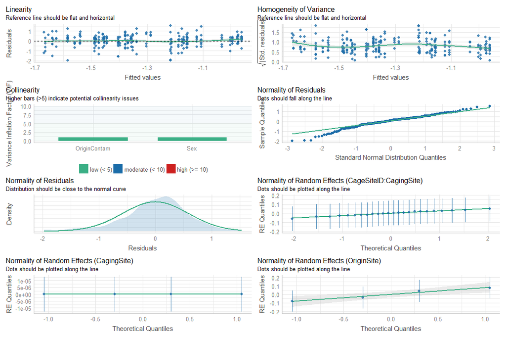

```r
dat2 = dat2[is.na(dat2$Sex) == F, ]
modSex <-
 lme4::lmer(
    DeltaCtGpx.p ~ OriginContam + Sex +
      (1 | CagingSite /  CageSiteID) + (1| OriginSite),
    data = dat2,
    na.action = na.exclude
  )
performance::check_model(modSex)
```

```r
car::Anova(modSex, type = "3")
```

```
## Analysis of Deviance Table (Type III Wald chisquare tests)
##
## Response: DeltaCtGpx.p
##                 Chisq Df Pr(>Chisq)
## (Intercept)  112.5356  1    < 2e-16 ***
## OriginContam   6.4537  1    0.01107 *
## Sex            5.2931  1    0.02141 *
## ---
## Signif. codes:  0 '***' 0.001 '**' 0.01 '*' 0.05 '.' 0.1 ' ' 1
```

```r
summary(modSex)
```

```
## Linear mixed model fit by REML ['lmerMod']
## Formula: DeltaCtGpx.p ~ OriginContam + Sex + (1 | CagingSite/CageSiteID) +
##     (1 | OriginSite)
##    Data: dat2
##
## REML criterion at convergence: 452.3
##
## Scaled residuals:
##     Min      1Q  Median      3Q     Max
## -3.3444 -0.4585  0.1213  0.5956  2.5866
##
## Random effects:
##  Groups                Name        Variance  Std.Dev.
##  CageSiteID:CagingSite (Intercept) 5.543e-03 7.445e-02
##  CagingSite            (Intercept) 4.261e-11 6.527e-06
##  OriginSite            (Intercept) 1.214e-02 1.102e-01
##  Residual                          3.508e-01 5.923e-01
## Number of obs: 245, groups:
## CageSiteID:CagingSite, 24; CagingSite, 4; OriginSite, 4
##
## Fixed effects:
##                Estimate Std. Error t value
## (Intercept)    -1.07457    0.10130 -10.608
## OriginContamLC -0.34854    0.13720  -2.540
## SexM           -0.18119    0.07875  -2.301
##
## Correlation of Fixed Effects:
##             (Intr) OrgCLC
## OrignCntmLC -0.673
## SexM        -0.309  0.017
## optimizer (nloptwrap) convergence code: 0 (OK)
## boundary (singular) fit: see ?isSingular
```

```r
modGpx <- modSex
RmodGpx <- MuMIn::r.squaredGLMM(modGpx)
```

The sex effect is significant. The modSex is thus the best model. Here, there is no interaction, and hence no posthoc test nor parallelism test to conduct

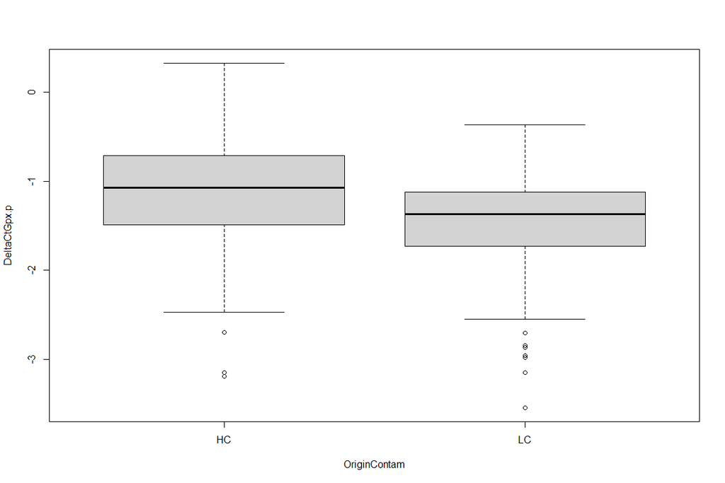

```r
boxplot(DeltaCtGpx.p ~ OriginContam, data = dat2)
```

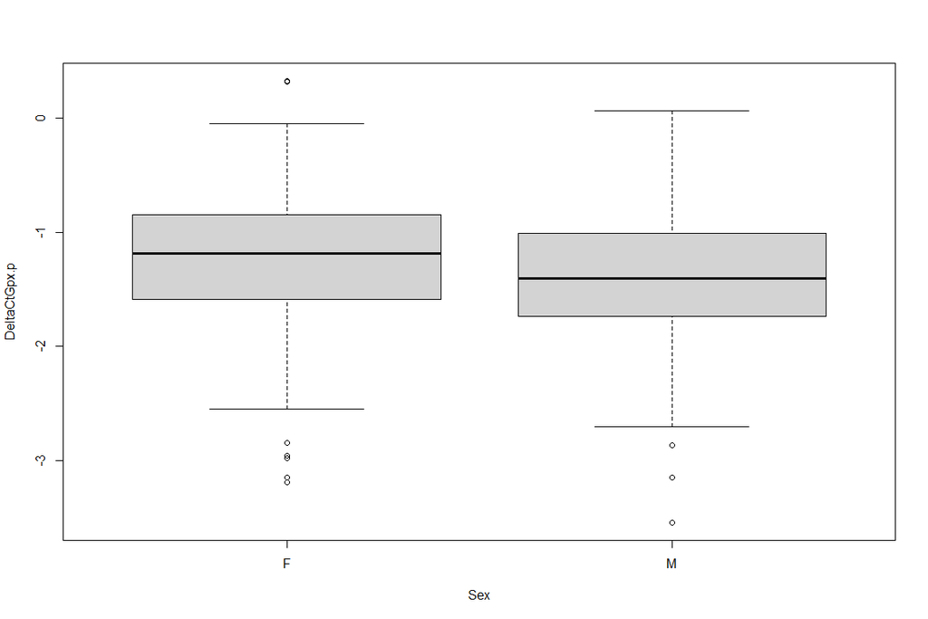

```r
boxplot(DeltaCtGpx.p ~ Sex, data = dat2)
```

```r
# compute mean and Se for LC and HC groups
meanVal <-
  data.frame(
    mean = c(mean(dat2$DeltaCtGpx.p[which(dat2$OriginContam == "LC")]),
             mean(dat2$DeltaCtGpx.p[which(dat2$OriginContam == "HC")])),
    Se = c(
      sd(dat2$DeltaCtGpx.p[which(dat2$OriginContam == "LC")]) / sqrt(length(dat2$DeltaCtGpx.p[which(dat2$OriginContam == "LC")])),
      sd(dat2$DeltaCtGpx.p[which(dat2$OriginContam == "HC")]) / sqrt(length(dat2$DeltaCtGpx.p[which(dat2$OriginContam == "HC")]))
    ),
    row.names = c("LC", "HC"),
    n = c(length(dat2$DeltaCtGpx.p[which(dat2$OriginContam == "LC")]),
    length(dat2$DeltaCtGpx.p[which(dat2$OriginContam == "HC")]))
  )

kableExtra::kable_classic(
  kableExtra::kbl(meanVal),
  bootstrap_options = c("striped", "hover", "condensed", "responsive"),
  full_width = F,
  html_font = "arial",
  font_size = 10
)
```

|  | mean | Se | n |
| --- | --- | --- | --- |
| LC | -1.490080 | 0.0533207 | 117 |
| HC | -1.149969 | 0.0560095 | 128 |

### 5.16.4 Casp3

#### 5.16.4.1 Check the data

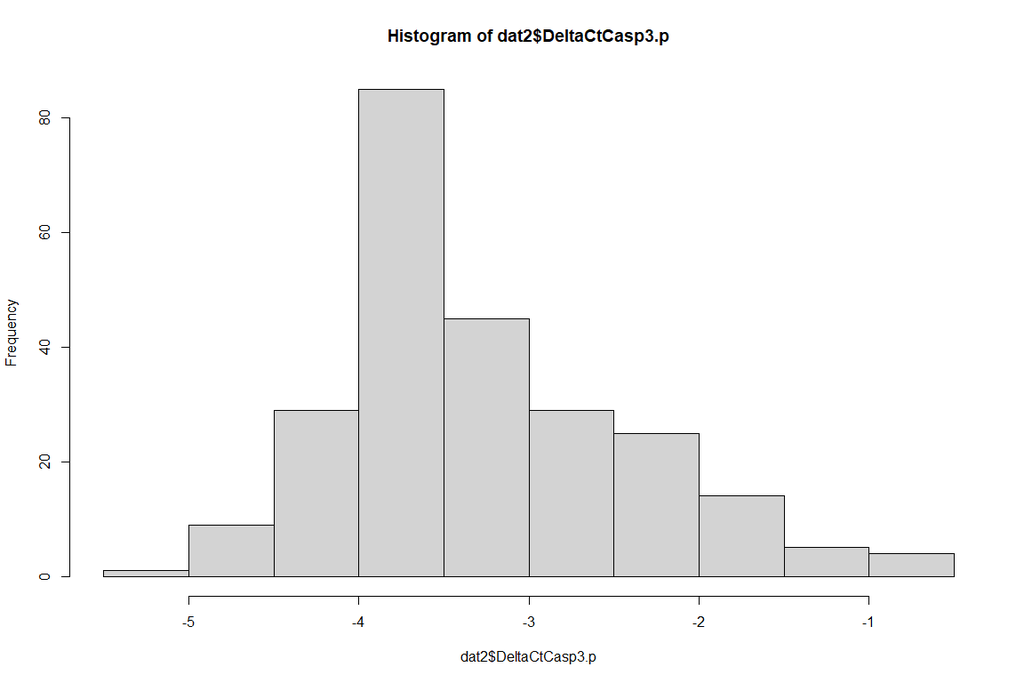

```r
dat2 = dat1[is.na(dat1$DeltaCtCasp3) == F, ]
# transform variable to approx. normality
dat2$DeltaCtCasp3.p <-
  bimixt::boxcox(dat2$DeltaCtCasp3, car::powerTransform(dat2$DeltaCtMtl)$lambda)
hist(dat2$DeltaCtCasp3.p)
```

#### 5.16.4.2 Visualize

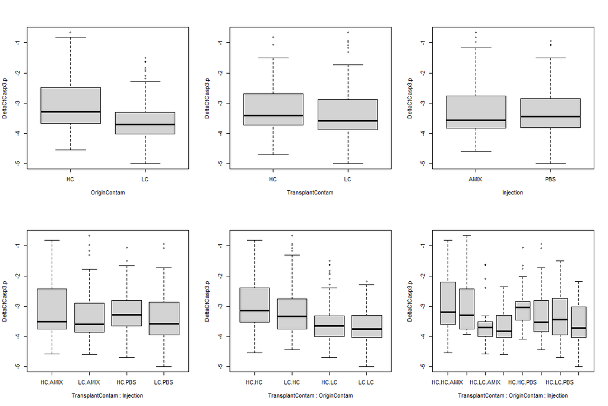

```r
par(mfrow=c(2,3))
boxplot(DeltaCtCasp3.p ~ OriginContam, data = dat2)
boxplot(DeltaCtCasp3.p ~ TransplantContam, data = dat2)
boxplot(DeltaCtCasp3.p ~ Injection, data = dat2)
boxplot(DeltaCtCasp3.p ~ TransplantContam * Injection, data = dat2)
boxplot(DeltaCtCasp3.p ~ TransplantContam * OriginContam, data = dat2)
boxplot(DeltaCtCasp3.p ~ TransplantContam * OriginContam * Injection, data = dat2)
```

#### 5.16.4.3 Build the full model

```r
modfull <-
 lme4::lmer(
    DeltaCtCasp3.p ~ (TransplantContam + OriginContam + Injection) ^ 3 +  SizeEnd +
      (1 | CagingSite /  CageSiteID) + (1| OriginSite),
    data = dat2,
    na.action = na.exclude
  )
car::Anova(modfull, type = "3")
```

```
## Analysis of Deviance Table (Type III Wald chisquare tests)
##
## Response: DeltaCtCasp3.p
##                                            Chisq Df Pr(>Chisq)
## (Intercept)                             209.1082  1  < 2.2e-16 ***
## TransplantContam                          0.0021  1   0.963343
## OriginContam                             10.4111  1   0.001253 **
## Injection                                 0.2313  1   0.630533
## SizeEnd                                  43.1668  1  5.027e-11 ***
## TransplantContam:OriginContam             0.0000  1   0.999188
## TransplantContam:Injection                0.4093  1   0.522341
## OriginContam:Injection                    1.7747  1   0.182800
## TransplantContam:OriginContam:Injection   0.0092  1   0.923781
## ---
## Signif. codes:  0 '***' 0.001 '**' 0.01 '*' 0.05 '.' 0.1 ' ' 1
```

```r
summary(modfull)
```

```
## Linear mixed model fit by REML ['lmerMod']
## Formula: DeltaCtCasp3.p ~ (TransplantContam + OriginContam + Injection)^3 +
##     SizeEnd + (1 | CagingSite/CageSiteID) + (1 | OriginSite)
##    Data: dat2
##
## REML criterion at convergence: 548.2
##
## Scaled residuals:
##      Min       1Q   Median       3Q      Max
## -2.18169 -0.63883 -0.09077  0.59191  2.29276
##
## Random effects:
##  Groups                Name        Variance Std.Dev.
##  CageSiteID:CagingSite (Intercept) 0.001552 0.03939
##  CagingSite            (Intercept) 0.000000 0.00000
##  OriginSite            (Intercept) 0.001942 0.04407
##  Residual                          0.511377 0.71511
## Number of obs: 246, groups:
## CageSiteID:CagingSite, 24; CagingSite, 4; OriginSite, 4
##
## Fixed effects:
##                                                  Estimate Std. Error t value
## (Intercept)                                    -5.0390380  0.3484674 -14.461
## TransplantContamLC                              0.0081695  0.1777545   0.046
## OriginContamLC                                 -0.5997254  0.1858674  -3.227
## InjectionPBS                                   -0.0867806  0.1804259  -0.481
## SizeEnd                                         0.2100963  0.0319774   6.570
## TransplantContamLC:OriginContamLC              -0.0002577  0.2531360  -0.001
## TransplantContamLC:InjectionPBS                -0.1619011  0.2530731  -0.640
## OriginContamLC:InjectionPBS                     0.3492433  0.2621585   1.332
## TransplantContamLC:OriginContamLC:InjectionPBS -0.0350206  0.3660468  -0.096
##
## Correlation of Fixed Effects:
##             (Intr) TrnCLC OrgCLC InjPBS SizEnd TrCLC:OCLC TCLC:I OCLC:I
## TrnsplntCLC -0.300
## OrignCntmLC -0.303  0.479
## InjectinPBS -0.258  0.484  0.463
## SizeEnd     -0.929  0.049  0.048  0.013
## TrnCLC:OCLC  0.156 -0.699 -0.690 -0.339  0.025
## TrnCLC:IPBS  0.165 -0.688 -0.329 -0.713  0.011  0.484
## OrgCLC:IPBS  0.179 -0.333 -0.657 -0.688 -0.010  0.482      0.490
## TCLC:OCLC:I -0.111  0.476  0.470  0.493 -0.011 -0.680     -0.691 -0.716
## optimizer (nloptwrap) convergence code: 0 (OK)
## boundary (singular) fit: see ?isSingular
```

#### 5.16.4.4 Refining the model

```r
mod2 <-
 lme4::lmer(
    DeltaCtCasp3.p ~ (TransplantContam + OriginContam + Injection) ^ 2 +  SizeEnd +
      (1 | CagingSite /  CageSiteID) + (1| OriginSite),
    data = dat2,
    na.action = na.exclude
  )
car::Anova(mod2, type = "3")
```

```
## Analysis of Deviance Table (Type III Wald chisquare tests)
##
## Response: DeltaCtCasp3.p
##                                  Chisq Df Pr(>Chisq)
## (Intercept)                   211.8814  1  < 2.2e-16 ***
## TransplantContam                0.0109  1  0.9170049
## OriginContam                   12.9746  1  0.0003158 ***
## Injection                       0.2494  1  0.6175203
## SizeEnd                        43.0676  1  5.288e-11 ***
## TransplantContam:OriginContam   0.0082  1  0.9278250
## TransplantContam:Injection      0.9595  1  0.3273181
## OriginContam:Injection          3.2908  1  0.0696711 .
## ---
## Signif. codes:  0 '***' 0.001 '**' 0.01 '*' 0.05 '.' 0.1 ' ' 1
```

```r
summary(mod2)
```

```
## Linear mixed model fit by REML ['lmerMod']
## Formula: DeltaCtCasp3.p ~ (TransplantContam + OriginContam + Injection)^2 +
##     SizeEnd + (1 | CagingSite/CageSiteID) + (1 | OriginSite)
##    Data: dat2
##
## REML criterion at convergence: 548.1
##
## Scaled residuals:
##      Min       1Q   Median       3Q      Max
## -2.19213 -0.63792 -0.09036  0.59237  2.28990
##
## Random effects:
##  Groups                Name        Variance Std.Dev.
##  CageSiteID:CagingSite (Intercept) 0.001766 0.04203
##  CagingSite            (Intercept) 0.000000 0.00000
##  OriginSite            (Intercept) 0.002009 0.04482
##  Residual                          0.509045 0.71347
## Number of obs: 246, groups:
## CageSiteID:CagingSite, 24; CagingSite, 4; OriginSite, 4
##
## Fixed effects:
##                                   Estimate Std. Error t value
## (Intercept)                       -5.04030    0.34627 -14.556
## TransplantContamLC                 0.01628    0.15623   0.104
## OriginContamLC                    -0.59139    0.16418  -3.602
## InjectionPBS                      -0.07823    0.15665  -0.499
## SizeEnd                            0.20981    0.03197   6.563
## TransplantContamLC:OriginContamLC -0.01681    0.18557  -0.091
## TransplantContamLC:InjectionPBS   -0.17869    0.18242  -0.980
## OriginContamLC:InjectionPBS        0.33126    0.18261   1.814
##
## Correlation of Fixed Effects:
##             (Intr) TrnCLC OrgCLC InjPBS SizEnd TCLC:O TCLC:I
## TrnsplntCLC -0.283
## OrignCntmLC -0.286  0.330
## InjectinPBS -0.235  0.325  0.300
## SizeEnd     -0.936  0.062  0.060  0.021
## TrnCLC:OCLC  0.110 -0.583 -0.572 -0.006  0.023
## TrnCLC:IPBS  0.123 -0.565 -0.006 -0.592  0.004  0.026
## OrgCLC:IPBS  0.144  0.012 -0.519 -0.552 -0.026 -0.010 -0.009
## optimizer (nloptwrap) convergence code: 0 (OK)
## boundary (singular) fit: see ?isSingular
```

#### 5.16.4.5 Refining the model

```r
mod3 <-
 lme4::lmer(
    DeltaCtCasp3.p ~ TransplantContam + (OriginContam + Injection)^2 +  SizeEnd +
      (1 | CagingSite /  CageSiteID) + (1| OriginSite),
    data = dat2,
    na.action = na.exclude
  )
car::Anova(mod3, type = "3")
```

```
## Analysis of Deviance Table (Type III Wald chisquare tests)
##
## Response: DeltaCtCasp3.p
##                           Chisq Df Pr(>Chisq)
## (Intercept)            211.6011  1  < 2.2e-16 ***
## TransplantContam         0.6898  1    0.40622
## OriginContam            19.4837  1  1.015e-05 ***
## Injection                1.7977  1    0.17999
## SizeEnd                 42.4736  1  7.164e-11 ***
## OriginContam:Injection   3.2660  1    0.07073 .
## ---
## Signif. codes:  0 '***' 0.001 '**' 0.01 '*' 0.05 '.' 0.1 ' ' 1
```

```r
summary(mod3)
```

```
## Linear mixed model fit by REML ['lmerMod']
## Formula: DeltaCtCasp3.p ~ TransplantContam + (OriginContam + Injection)^2 +
##     SizeEnd + (1 | CagingSite/CageSiteID) + (1 | OriginSite)
##    Data: dat2
##
## REML criterion at convergence: 545.9
##
## Scaled residuals:
##     Min      1Q  Median      3Q     Max
## -2.1546 -0.6130 -0.1134  0.5822  2.2985
##
## Random effects:
##  Groups                Name        Variance Std.Dev.
##  CageSiteID:CagingSite (Intercept) 0.000000 0.00000
##  CagingSite            (Intercept) 0.000000 0.00000
##  OriginSite            (Intercept) 0.002616 0.05114
##  Residual                          0.508083 0.71280
## Number of obs: 246, groups:
## CageSiteID:CagingSite, 24; CagingSite, 4; OriginSite, 4
##
## Fixed effects:
##                             Estimate Std. Error t value
## (Intercept)                 -4.98732    0.34285 -14.547
## TransplantContamLC          -0.07621    0.09176  -0.831
## OriginContamLC              -0.59881    0.13566  -4.414
## InjectionPBS                -0.16913    0.12614  -1.341
## SizeEnd                      0.20914    0.03209   6.517
## OriginContamLC:InjectionPBS  0.32963    0.18240   1.807
##
## Correlation of Fixed Effects:
##             (Intr) TrnCLC OrgCLC InjPBS SizEnd
## TrnsplntCLC -0.258
## OrignCntmLC -0.277  0.002
## InjectinPBS -0.204 -0.007  0.453
## SizeEnd     -0.952  0.132  0.089  0.029
## OrgCLC:IPBS  0.147  0.003 -0.634 -0.692 -0.026
## optimizer (nloptwrap) convergence code: 0 (OK)
## boundary (singular) fit: see ?isSingular
```

#### 5.16.4.6 Refining the model

```r
mod4 <-
 lme4::lmer(
    DeltaCtCasp3.p ~  TransplantContam + OriginContam + Injection +  SizeEnd +
      (1 | CagingSite /  CageSiteID) + (1| OriginSite),
    data = dat2,
    na.action = na.exclude
  )
car::Anova(mod4, type = "3")
```

```
## Analysis of Deviance Table (Type III Wald chisquare tests)
##
## Response: DeltaCtCasp3.p
##                     Chisq Df Pr(>Chisq)
## (Intercept)      220.7014  1  < 2.2e-16 ***
## TransplantContam   0.6933  1     0.4050
## OriginContam      17.4701  1  2.919e-05 ***
## Injection          0.0156  1     0.9005
## SizeEnd           42.3555  1  7.610e-11 ***
## ---
## Signif. codes:  0 '***' 0.001 '**' 0.01 '*' 0.05 '.' 0.1 ' ' 1
```

```r
summary(mod4)
```

```
## Linear mixed model fit by REML ['lmerMod']
## Formula: DeltaCtCasp3.p ~ TransplantContam + OriginContam + Injection +
##     SizeEnd + (1 | CagingSite/CageSiteID) + (1 | OriginSite)
##    Data: dat2
##
## REML criterion at convergence: 547.6
##
## Scaled residuals:
##     Min      1Q  Median      3Q     Max
## -2.2414 -0.6378 -0.1475  0.6448  2.3176
##
## Random effects:
##  Groups                Name        Variance Std.Dev.
##  CageSiteID:CagingSite (Intercept) 0.000000 0.00000
##  CagingSite            (Intercept) 0.000000 0.00000
##  OriginSite            (Intercept) 0.002793 0.05285
##  Residual                          0.512812 0.71611
## Number of obs: 246, groups:
## CageSiteID:CagingSite, 24; CagingSite, 4; OriginSite, 4
##
## Fixed effects:
##                    Estimate Std. Error t value
## (Intercept)        -5.07491    0.34161 -14.856
## TransplantContamLC -0.07676    0.09218  -0.833
## OriginContamLC     -0.44336    0.10607  -4.180
## InjectionPBS       -0.01144    0.09152  -0.125
## SizeEnd             0.21029    0.03231   6.508
##
## Correlation of Fixed Effects:
##             (Intr) TrnCLC OrgCLC InjPBS
## TrnsplntCLC -0.260
## OrignCntmLC -0.241  0.004
## InjectinPBS -0.143 -0.008  0.025
## SizeEnd     -0.959  0.133  0.093  0.015
## optimizer (nloptwrap) convergence code: 0 (OK)
## boundary (singular) fit: see ?isSingular
```

#### 5.16.4.7 Refining the model

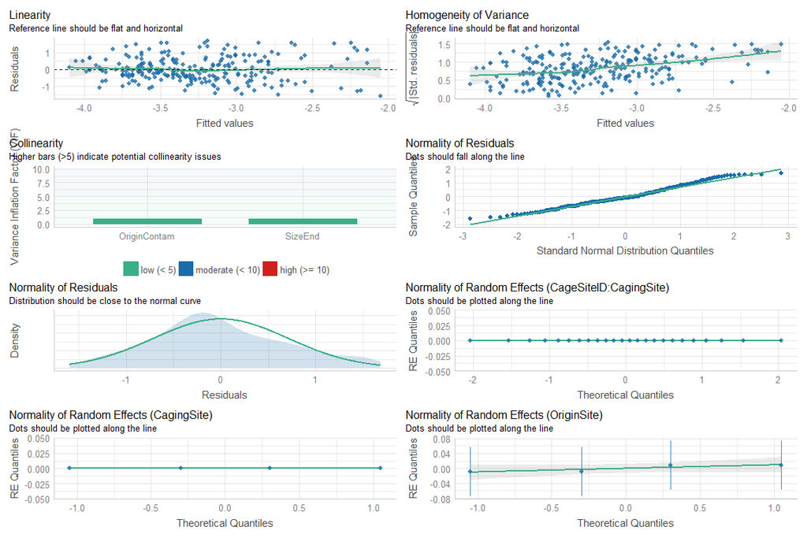

```r
mod5 <-
 lme4::lmer(
    DeltaCtCasp3.p ~  OriginContam +  SizeEnd +
      (1 | CagingSite /  CageSiteID) + (1| OriginSite),
    data = dat2,
    na.action = na.exclude
  )
performance::check_model(mod5)
```

```r
car::Anova(mod5, type = "3")
```

```
## Analysis of Deviance Table (Type III Wald chisquare tests)
##
## Response: DeltaCtCasp3.p
##                Chisq Df Pr(>Chisq)
## (Intercept)  270.215  1  < 2.2e-16 ***
## OriginContam  20.109  1  7.314e-06 ***
## SizeEnd       48.992  1  2.570e-12 ***
## ---
## Signif. codes:  0 '***' 0.001 '**' 0.01 '*' 0.05 '.' 0.1 ' ' 1
```

```r
summary(mod5)
```

```
## Linear mixed model fit by REML ['lmerMod']
## Formula:
## DeltaCtCasp3.p ~ OriginContam + SizeEnd + (1 | CagingSite/CageSiteID) +
##     (1 | OriginSite)
##    Data: dat2
##
## REML criterion at convergence: 542.4
##
## Scaled residuals:
##     Min      1Q  Median      3Q     Max
## -2.2329 -0.6460 -0.1196  0.6673  2.3653
##
## Random effects:
##  Groups                Name        Variance Std.Dev.
##  CageSiteID:CagingSite (Intercept) 0.000000 0.0000
##  CagingSite            (Intercept) 0.000000 0.0000
##  OriginSite            (Intercept) 0.001289 0.0359
##  Residual                          0.510566 0.7145
## Number of obs: 246, groups:
## CageSiteID:CagingSite, 24; CagingSite, 4; OriginSite, 4
##
## Fixed effects:
##                Estimate Std. Error t value
## (Intercept)    -5.19004    0.31573 -16.438
## OriginContamLC -0.44163    0.09848  -4.484
## SizeEnd         0.21743    0.03106   6.999
##
## Correlation of Fixed Effects:
##             (Intr) OrgCLC
## OrignCntmLC -0.245
## SizeEnd     -0.976  0.098
## optimizer (nloptwrap) convergence code: 0 (OK)
## boundary (singular) fit: see ?isSingular
```

```r
modCasp3 <- mod5
RmodCasp3 <- MuMIn::r.squaredGLMM(modCasp3)
```

Casp3 expression is significantly different according to fish origin. More specifically, HC fish have higher Casp3 expression than LC fish. Also, the bigger the fish, the higher the level of Casp3 expression.

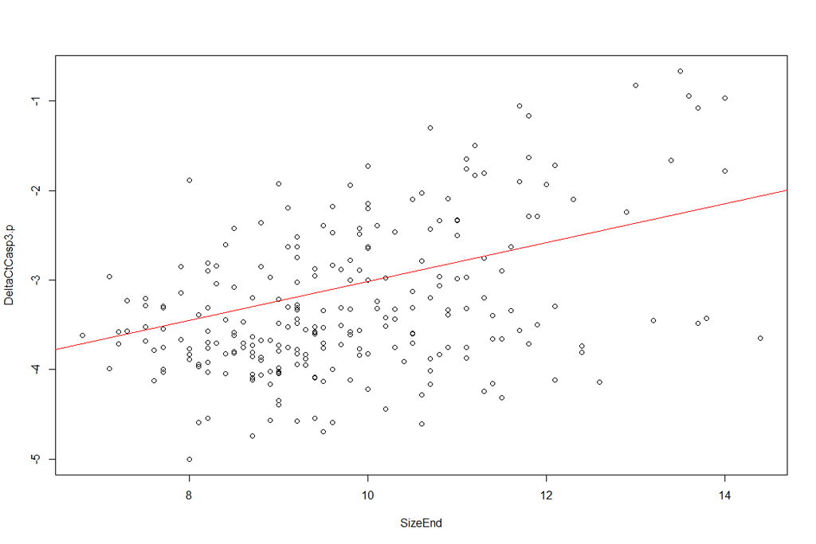

```r
plot(DeltaCtCasp3.p ~ SizeEnd, data = dat2)
abline(a = -5.19004, b = 0.21743, col = "red")
```

Now that we have identified the best model, add sex as covariate to check whether results are sensitive NB: sample size is reduced when adding sex variable within the model, for this reason the sex effect on results is checked on the final model

#### 5.16.4.8 Test for the sex effect

```r
dat2 = dat2[is.na(dat2$Sex) == F, ]
modSex <-
 lme4::lmer(
    DeltaCtCasp3.p ~ OriginContam + SizeEnd + Sex +
      (1 | CagingSite /  CageSiteID) + (1| OriginSite),
    data = dat2,
    na.action = na.exclude
  )
car::Anova(modSex, type = "3")
```

```
## Analysis of Deviance Table (Type III Wald chisquare tests)
##
## Response: DeltaCtCasp3.p
##                 Chisq Df Pr(>Chisq)
## (Intercept)  251.6319  1  < 2.2e-16 ***
## OriginContam  17.5314  1  2.826e-05 ***
## SizeEnd       44.7003  1  2.296e-11 ***
## Sex            0.0736  1     0.7862
## ---
## Signif. codes:  0 '***' 0.001 '**' 0.01 '*' 0.05 '.' 0.1 ' ' 1
```

```r
summary(modSex)
```

```
## Linear mixed model fit by REML ['lmerMod']
## Formula:
## DeltaCtCasp3.p ~ OriginContam + SizeEnd + Sex + (1 | CagingSite/CageSiteID) +
##     (1 | OriginSite)
##    Data: dat2
##
## REML criterion at convergence: 544
##
## Scaled residuals:
##     Min      1Q  Median      3Q     Max
## -2.2358 -0.6397 -0.1252  0.6708  2.3654
##
## Random effects:
##  Groups                Name        Variance Std.Dev.
##  CageSiteID:CagingSite (Intercept) 0.00000  0.0000
##  CagingSite            (Intercept) 0.00000  0.0000
##  OriginSite            (Intercept) 0.00255  0.0505
##  Residual                          0.51416  0.7170
## Number of obs: 245, groups:
## CageSiteID:CagingSite, 24; CagingSite, 4; OriginSite, 4
##
## Fixed effects:
##                Estimate Std. Error t value
## (Intercept)    -5.16841    0.32582 -15.863
## OriginContamLC -0.44057    0.10522  -4.187
## SizeEnd         0.21420    0.03204   6.686
## SexM            0.02565    0.09455   0.271
##
## Correlation of Fixed Effects:
##             (Intr) OrgCLC SizEnd
## OrignCntmLC -0.250
## SizeEnd     -0.968  0.095
## SexM        -0.051  0.021 -0.066
## optimizer (nloptwrap) convergence code: 0 (OK)
## boundary (singular) fit: see ?isSingular
```

The sex effect is not significant. The mod5 is thus the best model. Here, there is no interaction, and hence no posthoc test nor parallelism test to conduct

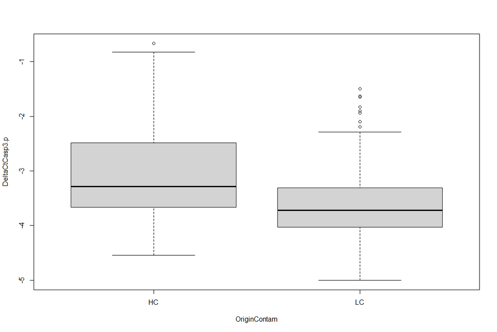

```r
boxplot(DeltaCtCasp3.p ~ OriginContam, data = dat2)
```

```r
# compute mean and Se for LC and HC groups
meanVal <-
  data.frame(
    mean = c(mean(dat2$DeltaCtCasp3.p[which(dat2$OriginContam == "LC")]),
             mean(dat2$DeltaCtCasp3.p[which(dat2$OriginContam == "HC")])),
    Se = c(
      sd(dat2$DeltaCtCasp3.p[which(dat2$OriginContam == "LC")]) / sqrt(length(dat2$DeltaCtCasp3.p[which(dat2$OriginContam == "LC")])),
      sd(dat2$DeltaCtCasp3.p[which(dat2$OriginContam == "HC")]) / sqrt(length(dat2$DeltaCtCasp3.p[which(dat2$OriginContam == "HC")]))
    ),
    row.names = c("LC", "HC"),
    n = c(length(dat2$DeltaCtCasp3.p[which(dat2$OriginContam == "LC")]),
    length(dat2$DeltaCtCasp3.p[which(dat2$OriginContam == "HC")]))
  )

kableExtra::kable_classic(
  kableExtra::kbl(meanVal),
  bootstrap_options = c("striped", "hover", "condensed", "responsive"),
  full_width = F,
  html_font = "arial",
  font_size = 10
)
```

|  | mean | Se | n |
| --- | --- | --- | --- |
| LC | -3.542152 | 0.0677479 | 117 |
| HC | -3.030752 | 0.0741425 | 128 |

### 5.16.5 Pcx

#### 5.16.5.1 Check the data

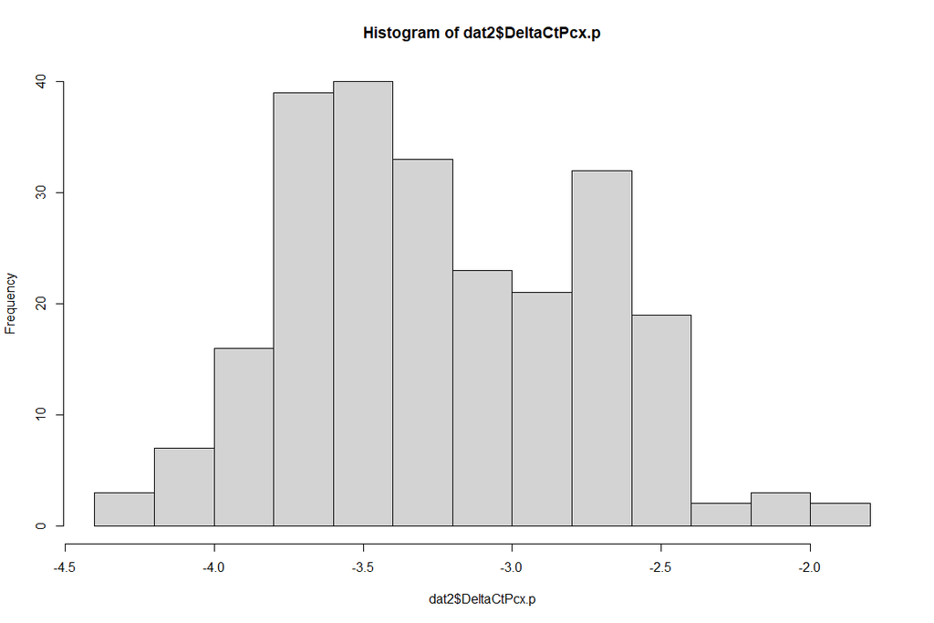

```r
dat2 = dat1[is.na(dat1$DeltaCtPcx) == F, ]
# transform variable to approx. normality
dat2$DeltaCtPcx.p <-
  bimixt::boxcox(dat2$DeltaCtPcx, car::powerTransform(dat2$DeltaCtMtl)$lambda)
hist(dat2$DeltaCtPcx.p)
```

#### 5.16.5.2 Visualize

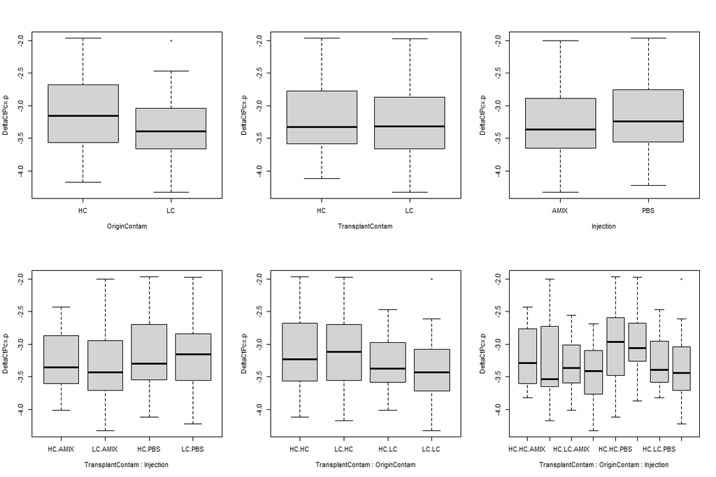

```r
par(mfrow=c(2,3))
boxplot(DeltaCtPcx.p ~ OriginContam, data = dat2)
boxplot(DeltaCtPcx.p ~ TransplantContam, data = dat2)
boxplot(DeltaCtPcx.p ~ Injection, data = dat2)
boxplot(DeltaCtPcx.p ~ TransplantContam * Injection, data = dat2)
boxplot(DeltaCtPcx.p ~ TransplantContam * OriginContam, data = dat2)
boxplot(DeltaCtPcx.p ~ TransplantContam * OriginContam * Injection, data = dat2)
```

#### 5.16.5.3 Build the full model

```r
modfull <-
 lme4::lmer(
    DeltaCtPcx.p ~ (TransplantContam + OriginContam + Injection) ^ 3 +  SizeEnd +
      (1 | CagingSite /  CageSiteID) + (1| OriginSite),
    data = dat2,
    na.action = na.exclude
  )
car::Anova(modfull, type = "3")
```

```
## Analysis of Deviance Table (Type III Wald chisquare tests)
##
## Response: DeltaCtPcx.p
##                                            Chisq Df Pr(>Chisq)
## (Intercept)                             107.6861  1     <2e-16 ***
## TransplantContam                          0.0189  1     0.8905
## OriginContam                              0.0681  1     0.7941
## Injection                                 2.2942  1     0.1299
## SizeEnd                                   1.4059  1     0.2357
## TransplantContam:OriginContam             0.6035  1     0.4372
## TransplantContam:Injection                0.3826  1     0.5362
## OriginContam:Injection                    0.5533  1     0.4570
## TransplantContam:OriginContam:Injection   0.0928  1     0.7606
## ---
## Signif. codes:  0 '***' 0.001 '**' 0.01 '*' 0.05 '.' 0.1 ' ' 1
```

```r
summary(modfull)
```

```
## Linear mixed model fit by REML ['lmerMod']
## Formula: DeltaCtPcx.p ~ (TransplantContam + OriginContam + Injection)^3 +
##     SizeEnd + (1 | CagingSite/CageSiteID) + (1 | OriginSite)
##    Data: dat2
##
## REML criterion at convergence: 267.4
##
## Scaled residuals:
##     Min      1Q  Median      3Q     Max
## -2.5255 -0.6242  0.0045  0.6279  3.6097
##
## Random effects:
##  Groups                Name        Variance Std.Dev.
##  CageSiteID:CagingSite (Intercept) 0.007666 0.08755
##  CagingSite            (Intercept) 0.000000 0.00000
##  OriginSite            (Intercept) 0.105554 0.32489
##  Residual                          0.151573 0.38932
## Number of obs: 240, groups:
## CageSiteID:CagingSite, 24; CagingSite, 4; OriginSite, 4
##
## Fixed effects:
##                                                Estimate Std. Error t value
## (Intercept)                                    -3.49927    0.33721 -10.377
## TransplantContamLC                              0.01544    0.11217   0.138
## OriginContamLC                                 -0.08953    0.34302  -0.261
## InjectionPBS                                    0.14892    0.09832   1.515
## SizeEnd                                         0.02767    0.02334   1.186
## TransplantContamLC:OriginContamLC              -0.12166    0.15660  -0.777
## TransplantContamLC:InjectionPBS                 0.08742    0.14132   0.619
## OriginContamLC:InjectionPBS                    -0.10626    0.14285  -0.744
## TransplantContamLC:OriginContamLC:InjectionPBS -0.06149    0.20181  -0.305
##
## Correlation of Fixed Effects:
##             (Intr) TrnCLC OrgCLC InjPBS SizEnd TrCLC:OCLC TCLC:I OCLC:I
## TrnsplntCLC -0.225
## OrignCntmLC -0.518  0.155
## InjectinPBS -0.149  0.418  0.136
## SizeEnd     -0.696  0.099  0.016  0.015
## TrnCLC:OCLC  0.116 -0.710 -0.225 -0.299 -0.006
## TrnCLC:IPBS  0.113 -0.622 -0.095 -0.696 -0.024  0.444
## OrgCLC:IPBS  0.101 -0.288 -0.194 -0.688 -0.008  0.424      0.479
## TCLC:OCLC:I -0.075  0.435  0.137  0.487  0.011 -0.611     -0.700 -0.708
## optimizer (nloptwrap) convergence code: 0 (OK)
## boundary (singular) fit: see ?isSingular
```

#### 5.16.5.4 Refining the model

```r
mod2 <-
 lme4::lmer(
    DeltaCtPcx.p ~ (TransplantContam + OriginContam + Injection) ^ 2 +  SizeEnd +
      (1 | CagingSite /  CageSiteID) + (1| OriginSite),
    data = dat2,
    na.action = na.exclude
  )
car::Anova(mod2, type = "3")
```

```
## Analysis of Deviance Table (Type III Wald chisquare tests)
##
## Response: DeltaCtPcx.p
##                                  Chisq Df Pr(>Chisq)
## (Intercept)                   109.0217  1    < 2e-16 ***
## TransplantContam                0.0903  1    0.76375
## OriginContam                    0.0490  1    0.82480
## Injection                       3.6415  1    0.05636 .
## SizeEnd                         1.4181  1    0.23372
## TransplantContam:OriginContam   1.4858  1    0.22286
## TransplantContam:Injection      0.3234  1    0.56958
## OriginContam:Injection          1.8527  1    0.17347
## ---
## Signif. codes:  0 '***' 0.001 '**' 0.01 '*' 0.05 '.' 0.1 ' ' 1
```

```r
summary(mod2)
```

```
## Linear mixed model fit by REML ['lmerMod']
## Formula: DeltaCtPcx.p ~ (TransplantContam + OriginContam + Injection)^2 +
##     SizeEnd + (1 | CagingSite/CageSiteID) + (1 | OriginSite)
##    Data: dat2
##
## REML criterion at convergence: 266.1
##
## Scaled residuals:
##     Min      1Q  Median      3Q     Max
## -2.5506 -0.6470  0.0109  0.6336  3.5963
##
## Random effects:
##  Groups                Name        Variance  Std.Dev.
##  CageSiteID:CagingSite (Intercept) 7.646e-03 8.744e-02
##  CagingSite            (Intercept) 9.086e-11 9.532e-06
##  OriginSite            (Intercept) 1.055e-01 3.248e-01
##  Residual                          1.510e-01 3.885e-01
## Number of obs: 240, groups:
## CageSiteID:CagingSite, 24; CagingSite, 4; OriginSite, 4
##
## Fixed effects:
##                                   Estimate Std. Error t value
## (Intercept)                       -3.50685    0.33586 -10.441
## TransplantContamLC                 0.03030    0.10083   0.301
## OriginContamLC                    -0.07519    0.33964  -0.221
## InjectionPBS                       0.16352    0.08569   1.908
## SizeEnd                            0.02774    0.02329   1.191
## TransplantContamLC:OriginContamLC -0.15083    0.12374  -1.219
## TransplantContamLC:InjectionPBS    0.05727    0.10070   0.569
## OriginContamLC:InjectionPBS       -0.13707    0.10070  -1.361
##
## Correlation of Fixed Effects:
##             (Intr) TrnCLC OrgCLC InjPBS SizEnd TCLC:O TCLC:I
## TrnsplntCLC -0.214
## OrignCntmLC -0.514  0.107
## InjectinPBS -0.129  0.262  0.080
## SizeEnd     -0.696  0.104  0.014  0.011
## TrnCLC:OCLC  0.089 -0.623 -0.180 -0.001  0.001
## TrnCLC:IPBS  0.085 -0.493  0.001 -0.569 -0.023  0.028
## OrgCLC:IPBS  0.068  0.032 -0.138 -0.557  0.000 -0.015 -0.033
## optimizer (nloptwrap) convergence code: 0 (OK)
## boundary (singular) fit: see ?isSingular
```

#### 5.16.5.5 Refining the model

```r
mod3 <-
 lme4::lmer(
    DeltaCtPcx.p ~ TransplantContam + (OriginContam + Injection)^2 +  SizeEnd +
      (1 | CagingSite /  CageSiteID) + (1| OriginSite),
    data = dat2,
    na.action = na.exclude
  )
car::Anova(mod3, type = "3")
```

```
## Analysis of Deviance Table (Type III Wald chisquare tests)
##
## Response: DeltaCtPcx.p
##                           Chisq Df Pr(>Chisq)
## (Intercept)            110.3238  1  < 2.2e-16 ***
## TransplantContam         0.0756  1   0.783360
## OriginContam             0.2075  1   0.648767
## Injection                7.4937  1   0.006191 **
## SizeEnd                  1.4519  1   0.228225
## OriginContam:Injection   1.8522  1   0.173526
## ---
## Signif. codes:  0 '***' 0.001 '**' 0.01 '*' 0.05 '.' 0.1 ' ' 1
```

```r
summary(mod3)
```

```
## Linear mixed model fit by REML ['lmerMod']
## Formula: DeltaCtPcx.p ~ TransplantContam + (OriginContam + Injection)^2 +
##     SizeEnd + (1 | CagingSite/CageSiteID) + (1 | OriginSite)
##    Data: dat2
##
## REML criterion at convergence: 262.8
##
## Scaled residuals:
##     Min      1Q  Median      3Q     Max
## -2.6471 -0.6634  0.0107  0.5713  3.5715
##
## Random effects:
##  Groups                Name        Variance Std.Dev.
##  CageSiteID:CagingSite (Intercept) 0.007977 0.08932
##  CagingSite            (Intercept) 0.000000 0.00000
##  OriginSite            (Intercept) 0.103693 0.32201
##  Residual                          0.150707 0.38821
## Number of obs: 240, groups:
## CageSiteID:CagingSite, 24; CagingSite, 4; OriginSite, 4
##
## Fixed effects:
##                             Estimate Std. Error t value
## (Intercept)                 -3.48672    0.33196 -10.504
## TransplantContamLC          -0.01731    0.06297  -0.275
## OriginContamLC              -0.15097    0.33145  -0.455
## InjectionPBS                 0.19271    0.07040   2.737
## SizeEnd                      0.02804    0.02327   1.205
## OriginContamLC:InjectionPBS -0.13685    0.10055  -1.361
##
## Correlation of Fixed Effects:
##             (Intr) TrnCLC OrgCLC InjPBS SizEnd
## TrnsplntCLC -0.194
## OrignCntmLC -0.509 -0.004
## InjectinPBS -0.100 -0.018  0.104
## SizeEnd     -0.702  0.150  0.015 -0.003
## OrgCLC:IPBS  0.073  0.011 -0.144 -0.700 -0.001
## optimizer (nloptwrap) convergence code: 0 (OK)
## boundary (singular) fit: see ?isSingular
```

#### 5.16.5.6 Refining the model

```r
mod4 <-
 lme4::lmer(
    DeltaCtPcx.p ~  TransplantContam + OriginContam + Injection +  SizeEnd +
      (1 | CagingSite /  CageSiteID) + (1| OriginSite),
    data = dat2,
    na.action = na.exclude
  )
car::Anova(mod4, type = "3")
```

```
## Analysis of Deviance Table (Type III Wald chisquare tests)
##
## Response: DeltaCtPcx.p
##                     Chisq Df Pr(>Chisq)
## (Intercept)      108.8221  1     <2e-16 ***
## TransplantContam   0.0672  1     0.7954
## OriginContam       0.4344  1     0.5099
## Injection          6.2241  1     0.0126 *
## SizeEnd            1.4435  1     0.2296
## ---
## Signif. codes:  0 '***' 0.001 '**' 0.01 '*' 0.05 '.' 0.1 ' ' 1
```

```r
summary(mod4)
```

```
## Linear mixed model fit by REML ['lmerMod']
## Formula: DeltaCtPcx.p ~ TransplantContam + OriginContam + Injection +
##     SizeEnd + (1 | CagingSite/CageSiteID) + (1 | OriginSite)
##    Data: dat2
##
## REML criterion at convergence: 261.9
##
## Scaled residuals:
##     Min      1Q  Median      3Q     Max
## -2.5499 -0.6893  0.0111  0.6220  3.4685
##
## Random effects:
##  Groups                Name        Variance Std.Dev.
##  CageSiteID:CagingSite (Intercept) 0.008103 0.09002
##  CagingSite            (Intercept) 0.000000 0.00000
##  OriginSite            (Intercept) 0.103298 0.32140
##  Residual                          0.151211 0.38886
## Number of obs: 240, groups:
## CageSiteID:CagingSite, 24; CagingSite, 4; OriginSite, 4
##
## Fixed effects:
##                    Estimate Std. Error t value
## (Intercept)        -3.45390    0.33109 -10.432
## TransplantContamLC -0.01639    0.06320  -0.259
## OriginContamLC     -0.21581    0.32744  -0.659
## InjectionPBS        0.12562    0.05035   2.495
## SizeEnd             0.02800    0.02331   1.201
##
## Correlation of Fixed Effects:
##             (Intr) TrnCLC OrgCLC InjPBS
## TrnsplntCLC -0.196
## OrignCntmLC -0.505 -0.002
## InjectinPBS -0.070 -0.015  0.005
## SizeEnd     -0.705  0.150  0.015 -0.005
## optimizer (nloptwrap) convergence code: 0 (OK)
## boundary (singular) fit: see ?isSingular
```

#### 5.16.5.7 Refining the model

```r
mod5 <-
 lme4::lmer(
    DeltaCtPcx.p ~  Injection +
      (1 | CagingSite /  CageSiteID) + (1| OriginSite),
    data = dat2,
    na.action = na.exclude
  )

car::Anova(mod5, type = "3")
```

```
## Analysis of Deviance Table (Type III Wald chisquare tests)
##
## Response: DeltaCtPcx.p
##                Chisq Df Pr(>Chisq)
## (Intercept) 410.9888  1    < 2e-16 ***
## Injection     6.2643  1    0.01232 *
## ---
## Signif. codes:  0 '***' 0.001 '**' 0.01 '*' 0.05 '.' 0.1 ' ' 1
```

```r
summary(mod5)
```

```
## Linear mixed model fit by REML ['lmerMod']
## Formula: DeltaCtPcx.p ~ Injection + (1 | CagingSite/CageSiteID) + (1 |
##     OriginSite)
##    Data: dat2
##
## REML criterion at convergence: 254.3
##
## Scaled residuals:
##     Min      1Q  Median      3Q     Max
## -2.4705 -0.6975 -0.0188  0.6402  3.4955
##
## Random effects:
##  Groups                Name        Variance Std.Dev.
##  CageSiteID:CagingSite (Intercept) 0.008078 0.08988
##  CagingSite            (Intercept) 0.000000 0.00000
##  OriginSite            (Intercept) 0.099706 0.31576
##  Residual                          0.150697 0.38820
## Number of obs: 240, groups:
## CageSiteID:CagingSite, 24; CagingSite, 4; OriginSite, 4
##
## Fixed effects:
##              Estimate Std. Error t value
## (Intercept)  -3.29796    0.16268 -20.273
## InjectionPBS  0.12580    0.05026   2.503
##
## Correlation of Fixed Effects:
##             (Intr)
## InjectinPBS -0.146
## optimizer (nloptwrap) convergence code: 0 (OK)
## boundary (singular) fit: see ?isSingular
```

Pcx expression is significantly different according to the immune challenge. More specifically, immune challenged fish injected with the antigen mixture (AMIX) have a lower Pcx gene expression compare to the fish injected with the control saline solution (PBS).

Now that we have identified the best model, add sex as covariate to check whether results are sensitive NB: sample size is reduced when adding sex variable within the model, for this reason the sex effect on results is checked on the final model

#### 5.16.5.8 Test for the sex effect

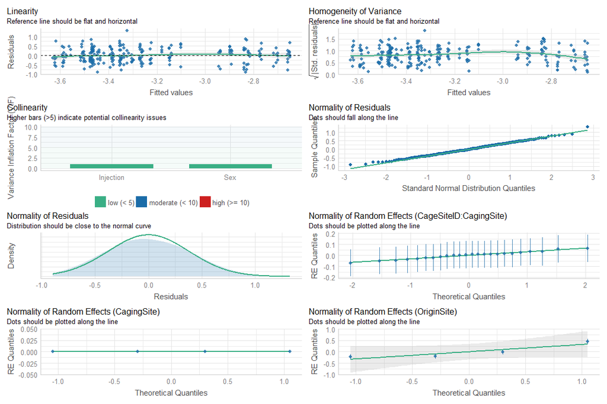

```r
dat2 = dat2[is.na(dat2$Sex) == F, ]
modSex <-
 lme4::lmer(
    DeltaCtPcx.p ~ Injection + Sex +
      (1 | CagingSite /  CageSiteID) + (1| OriginSite),
    data = dat2,
    na.action = na.exclude
  )
performance::check_model(modSex)
```

```r
car::Anova(modSex, type = "3")
```

```
## Analysis of Deviance Table (Type III Wald chisquare tests)
##
## Response: DeltaCtPcx.p
##                Chisq Df Pr(>Chisq)
## (Intercept) 392.0753  1    < 2e-16 ***
## Injection     5.9462  1    0.01475 *
## Sex           4.9243  1    0.02648 *
## ---
## Signif. codes:  0 '***' 0.001 '**' 0.01 '*' 0.05 '.' 0.1 ' ' 1
```

```r
summary(modSex)
```

```
## Linear mixed model fit by REML ['lmerMod']
## Formula: DeltaCtPcx.p ~ Injection + Sex + (1 | CagingSite/CageSiteID) +
##     (1 | OriginSite)
##    Data: dat2
##
## REML criterion at convergence: 250.6
##
## Scaled residuals:
##     Min      1Q  Median      3Q     Max
## -2.3234 -0.6714 -0.0291  0.7023  3.4292
##
## Random effects:
##  Groups                Name        Variance Std.Dev.
##  CageSiteID:CagingSite (Intercept) 0.004934 0.07024
##  CagingSite            (Intercept) 0.000000 0.00000
##  OriginSite            (Intercept) 0.100530 0.31706
##  Residual                          0.148851 0.38581
## Number of obs: 239, groups:
## CageSiteID:CagingSite, 24; CagingSite, 4; OriginSite, 4
##
## Fixed effects:
##              Estimate Std. Error t value
## (Intercept)  -3.25501    0.16439 -19.801
## InjectionPBS  0.12242    0.05021   2.438
## SexM         -0.11662    0.05255  -2.219
##
## Correlation of Fixed Effects:
##             (Intr) InjPBS
## InjectinPBS -0.156
## SexM        -0.135  0.083
## optimizer (nloptwrap) convergence code: 0 (OK)
## boundary (singular) fit: see ?isSingular
```

```r
modPcx <- modSex
RmodPcx <- MuMIn::r.squaredGLMM(modPcx)
```

The sex effect is significant. The modSex is thus the best model. Here, there is no interaction, and hence no posthoc test nor parallelism test to conduct

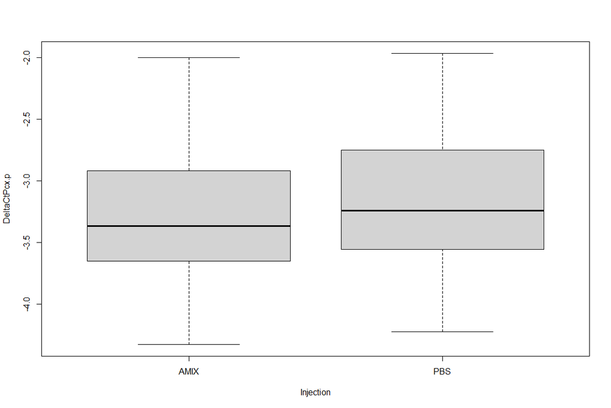

```r
boxplot(DeltaCtPcx.p ~ Injection, data = dat2)
```

```r
# compute mean and Se for LC and HC groups
meanVal <-
  data.frame(
    mean = c(mean(dat2$DeltaCtPcx.p[which(dat2$Injection == "PBS")]),
             mean(dat2$DeltaCtPcx.p[which(dat2$Injection == "AMIX")])),
    Se = c(
      sd(dat2$DeltaCtPcx.p[which(dat2$Injection == "PBS")]) / sqrt(length(dat2$DeltaCtPcx.p[which(dat2$Injection == "PBS")])),
      sd(dat2$DeltaCtPcx.p[which(dat2$Injection == "AMIX")]) / sqrt(length(dat2$DeltaCtPcx.p[which(dat2$Injection == "AMIX")]))
    ),
    row.names = c("PBS", "AMIX"),
    n = c(length(dat2$DeltaCtPcx.p[which(dat2$Injection == "PBS")]),
    length(dat2$DeltaCtPcx.p[which(dat2$Injection == "AMIX")]))
  )

kableExtra::kable_classic(
  kableExtra::kbl(meanVal),
  bootstrap_options = c("striped", "hover", "condensed", "responsive"),
  full_width = F,
  html_font = "arial",
  font_size = 10
)
```

|  | mean | Se | n |
| --- | --- | --- | --- |
| PBS | -3.171033 | 0.0463890 | 114 |
| AMIX | -3.307949 | 0.0419337 | 125 |

### 5.16.6 Pygl

#### 5.16.6.1 Check the data

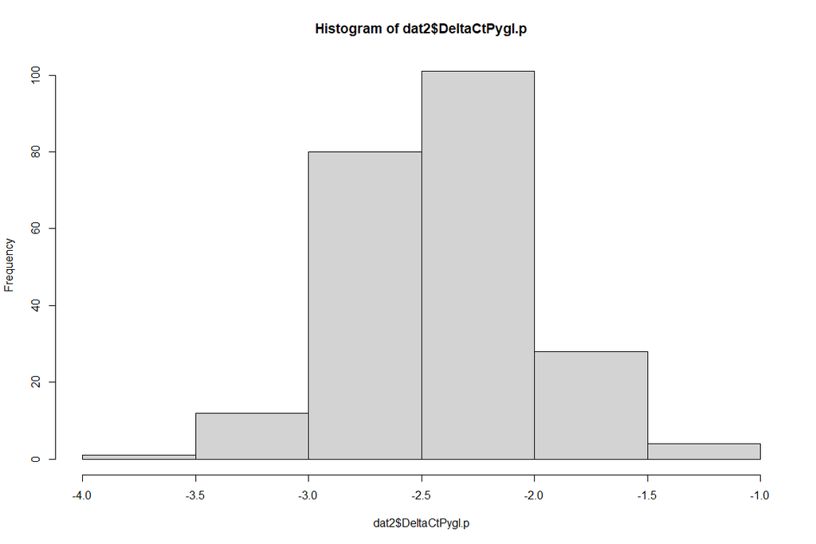

```r
dat2 = dat1[is.na(dat1$DeltaCtPygl) == F, ]
# transform variable to approx. normality
dat2$DeltaCtPygl.p <-
  bimixt::boxcox(dat2$DeltaCtPygl, car::powerTransform(dat2$DeltaCtMtl)$lambda)
hist(dat2$DeltaCtPygl.p)
```

#### 5.16.6.2 Visualize

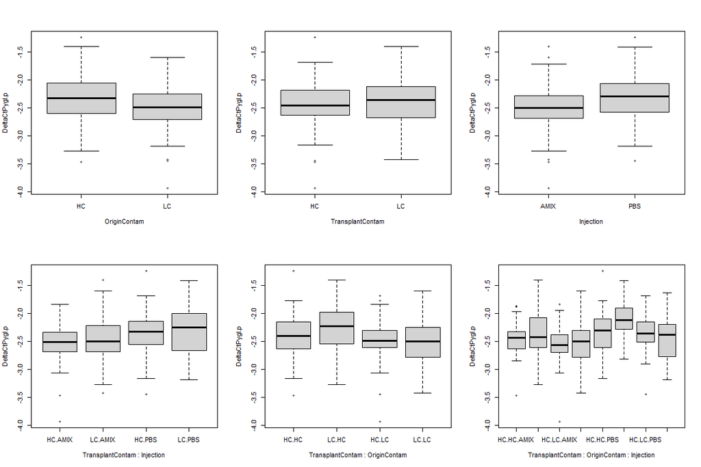

```r
par(mfrow=c(2,3))
boxplot(DeltaCtPygl.p ~ OriginContam, data = dat2)
boxplot(DeltaCtPygl.p ~ TransplantContam, data = dat2)
boxplot(DeltaCtPygl.p ~ Injection, data = dat2)
boxplot(DeltaCtPygl.p ~ TransplantContam * Injection, data = dat2)
boxplot(DeltaCtPygl.p ~ TransplantContam * OriginContam, data = dat2)
boxplot(DeltaCtPygl.p ~ TransplantContam * OriginContam * Injection, data = dat2)
```

#### 5.16.6.3 Build the full model

```r
modfull <-
 lme4::lmer(
    DeltaCtPygl.p ~ (TransplantContam + OriginContam + Injection) ^ 3 +  SizeEnd +
      (1 | CagingSite /  CageSiteID) + (1| OriginSite),
    data = dat2,
    na.action = na.exclude
  )
car::Anova(modfull, type = "3")
```

```
## Analysis of Deviance Table (Type III Wald chisquare tests)
##
## Response: DeltaCtPygl.p
##                                            Chisq Df Pr(>Chisq)
## (Intercept)                             124.1855  1     <2e-16 ***
## TransplantContam                          1.2894  1     0.2562
## OriginContam                              0.4564  1     0.4993
## Injection                                 1.5179  1     0.2179
## SizeEnd                                   1.2137  1     0.2706
## TransplantContam:OriginContam             0.3061  1     0.5801
## TransplantContam:Injection                0.8515  1     0.3561
## OriginContam:Injection                    0.1938  1     0.6598
## TransplantContam:OriginContam:Injection   1.9743  1     0.1600
## ---
## Signif. codes:  0 '***' 0.001 '**' 0.01 '*' 0.05 '.' 0.1 ' ' 1
```

```r
summary(modfull)
```

```
## Linear mixed model fit by REML ['lmerMod']
## Formula: DeltaCtPygl.p ~ (TransplantContam + OriginContam + Injection)^3 +
##     SizeEnd + (1 | CagingSite/CageSiteID) + (1 | OriginSite)
##    Data: dat2
##
## REML criterion at convergence: 221.1
##
## Scaled residuals:
##     Min      1Q  Median      3Q     Max
## -3.7762 -0.4925  0.0060  0.6019  2.7845
##
## Random effects:
##  Groups                Name        Variance Std.Dev.
##  CageSiteID:CagingSite (Intercept) 0.005033 0.07094
##  CagingSite            (Intercept) 0.000000 0.00000
##  OriginSite            (Intercept) 0.007040 0.08390
##  Residual                          0.134533 0.36679
## Number of obs: 226, groups:
## CageSiteID:CagingSite, 24; CagingSite, 4; OriginSite, 4
##
## Fixed effects:
##                                                Estimate Std. Error t value
## (Intercept)                                    -2.70225    0.24249 -11.144
## TransplantContamLC                              0.12416    0.10934   1.136
## OriginContamLC                                 -0.09012    0.13340  -0.676
## InjectionPBS                                    0.12528    0.10168   1.232
## SizeEnd                                         0.02411    0.02189   1.102
## TransplantContamLC:OriginContamLC              -0.08167    0.14760  -0.553
## TransplantContamLC:InjectionPBS                 0.13129    0.14228   0.923
## OriginContamLC:InjectionPBS                     0.06204    0.14095   0.440
## TransplantContamLC:OriginContamLC:InjectionPBS -0.27621    0.19658  -1.405
##
## Correlation of Fixed Effects:
##             (Intr) TrnCLC OrgCLC InjPBS SizEnd TrCLC:OCLC TCLC:I OCLC:I
## TrnsplntCLC -0.370
## OrignCntmLC -0.334  0.387
## InjectinPBS -0.240  0.430  0.346
## SizeEnd     -0.920  0.177  0.060  0.056
## TrnCLC:OCLC  0.214 -0.729 -0.547 -0.315 -0.066
## TrnCLC:IPBS  0.201 -0.646 -0.249 -0.717 -0.072  0.474
## OrgCLC:IPBS  0.173 -0.310 -0.480 -0.721 -0.040  0.436      0.517
## TCLC:OCLC:I -0.140  0.467  0.346  0.518  0.047 -0.633     -0.723 -0.718
## optimizer (nloptwrap) convergence code: 0 (OK)
## boundary (singular) fit: see ?isSingular
```

#### 5.16.6.4 Refining the model

```r
mod2 <-
 lme4::lmer(
    DeltaCtPygl.p ~ (TransplantContam + OriginContam + Injection) ^ 2 +  SizeEnd +
      (1 | CagingSite /  CageSiteID) + (1| OriginSite),
    data = dat2,
    na.action = na.exclude
  )
car::Anova(mod2, type = "3")
```

```
## Analysis of Deviance Table (Type III Wald chisquare tests)
##
## Response: DeltaCtPygl.p
##                                  Chisq Df Pr(>Chisq)
## (Intercept)                   130.7321  1    < 2e-16 ***
## TransplantContam                4.0936  1    0.04305 *
## OriginContam                    0.0409  1    0.83976
## Injection                       5.2326  1    0.02217 *
## SizeEnd                         1.3619  1    0.24321
## TransplantContam:OriginContam   3.4698  1    0.06250 .
## TransplantContam:Injection      0.0183  1    0.89242
## OriginContam:Injection          0.6638  1    0.41521
## ---
## Signif. codes:  0 '***' 0.001 '**' 0.01 '*' 0.05 '.' 0.1 ' ' 1
```

```r
summary(mod2)
```

```
## Linear mixed model fit by REML ['lmerMod']
## Formula: DeltaCtPygl.p ~ (TransplantContam + OriginContam + Injection)^2 +
##     SizeEnd + (1 | CagingSite/CageSiteID) + (1 | OriginSite)
##    Data: dat2
##
## REML criterion at convergence: 221.7
##
## Scaled residuals:
##     Min      1Q  Median      3Q     Max
## -3.8555 -0.4702  0.0152  0.5567  2.6701
##
## Random effects:
##  Groups                Name        Variance Std.Dev.
##  CageSiteID:CagingSite (Intercept) 0.004984 0.07060
##  CagingSite            (Intercept) 0.000000 0.00000
##  OriginSite            (Intercept) 0.007048 0.08395
##  Residual                          0.135180 0.36767
## Number of obs: 226, groups:
## CageSiteID:CagingSite, 24; CagingSite, 4; OriginSite, 4
##
## Fixed effects:
##                                   Estimate Std. Error t value
## (Intercept)                       -2.75029    0.24054 -11.434
## TransplantContamLC                 0.19585    0.09680   2.023
## OriginContamLC                    -0.02533    0.12528  -0.202
## InjectionPBS                       0.19937    0.08716   2.287
## SizeEnd                            0.02557    0.02191   1.167
## TransplantContamLC:OriginContamLC -0.21294    0.11432  -1.863
## TransplantContamLC:InjectionPBS   -0.01332    0.09847  -0.135
## OriginContamLC:InjectionPBS       -0.08014    0.09836  -0.815
##
## Correlation of Fixed Effects:
##             (Intr) TrnCLC OrgCLC InjPBS SizEnd TCLC:O TCLC:I
## TrnsplntCLC -0.348
## OrignCntmLC -0.307  0.272
## InjectinPBS -0.198  0.248  0.208
## SizeEnd     -0.924  0.176  0.047  0.038
## TrnCLC:OCLC  0.163 -0.633 -0.451  0.021 -0.047
## TrnCLC:IPBS  0.145 -0.506  0.001 -0.579 -0.055  0.030
## OrgCLC:IPBS  0.104  0.041 -0.356 -0.587 -0.009 -0.035 -0.005
## optimizer (nloptwrap) convergence code: 0 (OK)
## boundary (singular) fit: see ?isSingular
```

#### 5.16.6.5 Refining the model

```r
mod3 <-
 lme4::lmer(
    DeltaCtPygl.p ~ (TransplantContam + OriginContam)^2 + Injection +  SizeEnd +
      (1 | CagingSite /  CageSiteID) + (1| OriginSite),
    data = dat2,
    na.action = na.exclude
  )
car::Anova(mod3, type = "3")
```

```
## Analysis of Deviance Table (Type III Wald chisquare tests)
##
## Response: DeltaCtPygl.p
##                                  Chisq Df Pr(>Chisq)
## (Intercept)                   133.3751  1  < 2.2e-16 ***
## TransplantContam                5.3113  1   0.021187 *
## OriginContam                    0.2787  1   0.597543
## Injection                       9.4640  1   0.002095 **
## SizeEnd                         1.3406  1   0.246924
## TransplantContam:OriginContam   3.5640  1   0.059047 .
## ---
## Signif. codes:  0 '***' 0.001 '**' 0.01 '*' 0.05 '.' 0.1 ' ' 1
```

```r
summary(mod3)
```

```
## Linear mixed model fit by REML ['lmerMod']
## Formula: DeltaCtPygl.p ~ (TransplantContam + OriginContam)^2 + Injection +
##     SizeEnd + (1 | CagingSite/CageSiteID) + (1 | OriginSite)
##    Data: dat2
##
## REML criterion at convergence: 216.8
##
## Scaled residuals:
##     Min      1Q  Median      3Q     Max
## -3.8260 -0.4845  0.0207  0.5715  2.7511
##
## Random effects:
##  Groups                Name        Variance Std.Dev.
##  CageSiteID:CagingSite (Intercept) 0.005119 0.07155
##  CagingSite            (Intercept) 0.000000 0.00000
##  OriginSite            (Intercept) 0.006988 0.08360
##  Residual                          0.134274 0.36643
## Number of obs: 226, groups:
## CageSiteID:CagingSite, 24; CagingSite, 4; OriginSite, 4
##
## Fixed effects:
##                                   Estimate Std. Error t value
## (Intercept)                       -2.72511    0.23596 -11.549
## TransplantContamLC                 0.19237    0.08347   2.305
## OriginContamLC                    -0.06169    0.11686  -0.528
## InjectionPBS                       0.15064    0.04897   3.076
## SizeEnd                            0.02525    0.02181   1.158
## TransplantContamLC:OriginContamLC -0.21580    0.11431  -1.888
##
## Correlation of Fixed Effects:
##             (Intr) TrnCLC OrgCLC InjPBS SizEnd
## TrnsplntCLC -0.329
## OrignCntmLC -0.294  0.357
## InjectinPBS -0.094 -0.044 -0.002
## SizeEnd     -0.931  0.172  0.047  0.001
## TrnCLC:OCLC  0.166 -0.716 -0.498  0.031 -0.045
## optimizer (nloptwrap) convergence code: 0 (OK)
## boundary (singular) fit: see ?isSingular
```

#### 5.16.6.6 Refining the model

```r
mod4 <-
 lme4::lmer(
    DeltaCtPygl.p ~  TransplantContam + OriginContam + Injection +  SizeEnd +
      (1 | CagingSite /  CageSiteID) + (1| OriginSite),
    data = dat2,
    na.action = na.exclude
  )
car::Anova(mod4, type = "3")
```

```
## Analysis of Deviance Table (Type III Wald chisquare tests)
##
## Response: DeltaCtPygl.p
##                     Chisq Df Pr(>Chisq)
## (Intercept)      130.4728  1  < 2.2e-16 ***
## TransplantContam   1.7193  1   0.189788
## OriginContam       2.9271  1   0.087103 .
## Injection          9.7301  1   0.001813 **
## SizeEnd            1.2323  1   0.266962
## ---
## Signif. codes:  0 '***' 0.001 '**' 0.01 '*' 0.05 '.' 0.1 ' ' 1
```

```r
summary(mod4)
```

```
## Linear mixed model fit by REML ['lmerMod']
## Formula: DeltaCtPygl.p ~ TransplantContam + OriginContam + Injection +
##     SizeEnd + (1 | CagingSite/CageSiteID) + (1 | OriginSite)
##    Data: dat2
##
## REML criterion at convergence: 217.7
##
## Scaled residuals:
##     Min      1Q  Median      3Q     Max
## -3.6998 -0.5206  0.0379  0.5447  2.6484
##
## Random effects:
##  Groups                Name        Variance Std.Dev.
##  CageSiteID:CagingSite (Intercept) 0.007478 0.08648
##  CagingSite            (Intercept) 0.000000 0.00000
##  OriginSite            (Intercept) 0.006357 0.07973
##  Residual                          0.134472 0.36670
## Number of obs: 226, groups:
## CageSiteID:CagingSite, 24; CagingSite, 4; OriginSite, 4
##
## Fixed effects:
##                    Estimate Std. Error t value
## (Intercept)        -2.65959    0.23284 -11.422
## TransplantContamLC  0.08078    0.06161   1.311
## OriginContamLC     -0.17138    0.10017  -1.711
## InjectionPBS        0.15283    0.04900   3.119
## SizeEnd             0.02420    0.02180   1.110
##
## Correlation of Fixed Effects:
##             (Intr) TrnCLC OrgCLC InjPBS
## TrnsplntCLC -0.304
## OrignCntmLC -0.245  0.000
## InjectinPBS -0.101 -0.030  0.016
## SizeEnd     -0.938  0.190  0.028  0.002
## optimizer (nloptwrap) convergence code: 0 (OK)
## boundary (singular) fit: see ?isSingular
```

#### 5.16.6.7 Refining the model

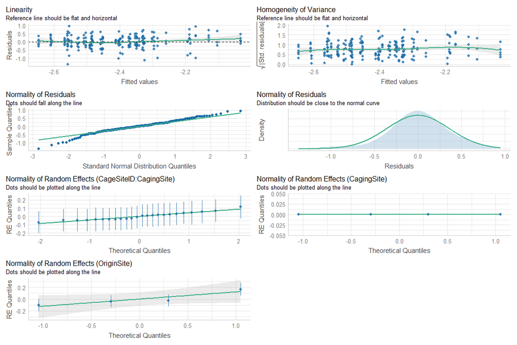

```r
mod5 <-
 lme4::lmer(
    DeltaCtPygl.p ~  Injection +
      (1 | CagingSite /  CageSiteID) + (1| OriginSite),
    data = dat2,
    na.action = na.exclude
  )
performance::check_model(mod5)
```

```r
car::Anova(mod5, type = "3")
```

```
## Analysis of Deviance Table (Type III Wald chisquare tests)
##
## Response: DeltaCtPygl.p
##                Chisq Df Pr(>Chisq)
## (Intercept) 1087.830  1  < 2.2e-16 ***
## Injection     10.084  1   0.001496 **
## ---
## Signif. codes:  0 '***' 0.001 '**' 0.01 '*' 0.05 '.' 0.1 ' ' 1
```

```r
summary(mod5)
```

```
## Linear mixed model fit by REML ['lmerMod']
## Formula: DeltaCtPygl.p ~ Injection + (1 | CagingSite/CageSiteID) + (1 |
##     OriginSite)
##    Data: dat2
##
## REML criterion at convergence: 209.9
##
## Scaled residuals:
##     Min      1Q  Median      3Q     Max
## -3.7510 -0.5203  0.0299  0.5532  2.5889
##
## Random effects:
##  Groups                Name        Variance Std.Dev.
##  CageSiteID:CagingSite (Intercept) 0.006913 0.08315
##  CagingSite            (Intercept) 0.000000 0.00000
##  OriginSite            (Intercept) 0.016728 0.12934
##  Residual                          0.134468 0.36670
## Number of obs: 226, groups:
## CageSiteID:CagingSite, 24; CagingSite, 4; OriginSite, 4
##
## Fixed effects:
##              Estimate Std. Error t value
## (Intercept)  -2.47089    0.07492 -32.982
## InjectionPBS  0.15549    0.04896   3.175
##
## Correlation of Fixed Effects:
##             (Intr)
## InjectinPBS -0.309
## optimizer (nloptwrap) convergence code: 0 (OK)
## boundary (singular) fit: see ?isSingular
```

```r
modPygl <- mod5
RmodPygl <- MuMIn::r.squaredGLMM(modPygl)
```

Pygl expression is significantly different according to the immune challenge. More specifically, immune challenged fish injected with the antigen mixture (AMIX) have a lower Pygl gene expression compare to the fish injected with the control saline solution (PBS).

Now that we have identified the best model, add sex as covariate to check whether results are sensitive NB: sample size is reduced when adding sex variable within the model, for this reason the sex effect on results is checked on the final model

#### 5.16.6.8 Test for the sex effect

```r
dat2 = dat2[is.na(dat2$Sex) == F, ]
modSex <-
 lme4::lmer(
    DeltaCtPygl.p ~ Injection + Sex +
      (1 | CagingSite /  CageSiteID) + (1| OriginSite),
    data = dat2,
    na.action = na.exclude
  )

car::Anova(modSex, type = "3")
```

```
## Analysis of Deviance Table (Type III Wald chisquare tests)
##
## Response: DeltaCtPygl.p
##                Chisq Df Pr(>Chisq)
## (Intercept) 978.8302  1  < 2.2e-16 ***
## Injection     9.7481  1   0.001795 **
## Sex           0.2304  1   0.631264
## ---
## Signif. codes:  0 '***' 0.001 '**' 0.01 '*' 0.05 '.' 0.1 ' ' 1
```

```r
summary(modSex)
```

```
## Linear mixed model fit by REML ['lmerMod']
## Formula: DeltaCtPygl.p ~ Injection + Sex + (1 | CagingSite/CageSiteID) +
##     (1 | OriginSite)
##    Data: dat2
##
## REML criterion at convergence: 213.8
##
## Scaled residuals:
##     Min      1Q  Median      3Q     Max
## -3.6951 -0.5427  0.0298  0.5821  2.5559
##
## Random effects:
##  Groups                Name        Variance Std.Dev.
##  CageSiteID:CagingSite (Intercept) 0.00643  0.08019
##  CagingSite            (Intercept) 0.00000  0.00000
##  OriginSite            (Intercept) 0.01703  0.13050
##  Residual                          0.13576  0.36846
## Number of obs: 225, groups:
## CageSiteID:CagingSite, 24; CagingSite, 4; OriginSite, 4
##
## Fixed effects:
##              Estimate Std. Error t value
## (Intercept)  -2.46144    0.07867 -31.286
## InjectionPBS  0.15460    0.04952   3.122
## SexM         -0.02499    0.05207  -0.480
##
## Correlation of Fixed Effects:
##             (Intr) InjPBS
## InjectinPBS -0.323
## SexM        -0.285  0.095
## optimizer (nloptwrap) convergence code: 0 (OK)
## boundary (singular) fit: see ?isSingular
```

The sex effect is not significant. The mod5 is thus the best model. Here, there is no interaction, and hence no posthoc test nor parallelism test to conduct

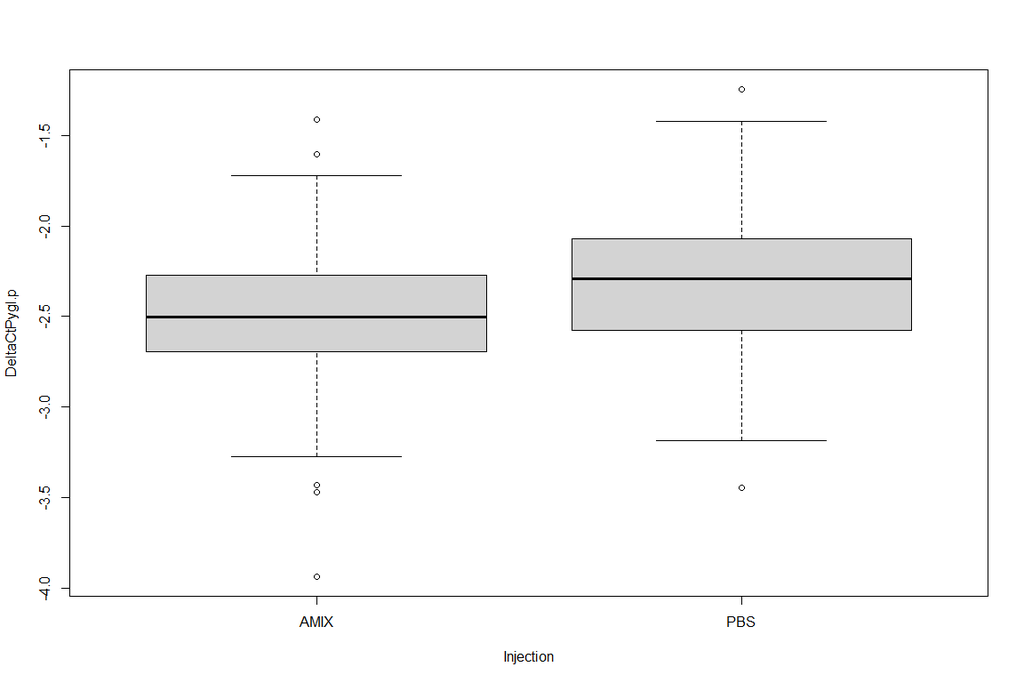

```r
boxplot(DeltaCtPygl.p ~ Injection, data = dat2)
```

```r
# compute mean and Se for LC and HC groups
meanVal <-
  data.frame(
    mean = c(mean(dat2$DeltaCtPygl.p[which(dat2$Injection == "PBS")]),
             mean(dat2$DeltaCtPygl.p[which(dat2$Injection == "AMIX")])),
    Se = c(
      sd(dat2$DeltaCtPygl.p[which(dat2$Injection == "PBS")]) / sqrt(length(dat2$DeltaCtPygl.p[which(dat2$Injection == "PBS")])),
      sd(dat2$DeltaCtPygl.p[which(dat2$Injection == "AMIX")]) / sqrt(length(dat2$DeltaCtPygl.p[which(dat2$Injection == "AMIX")]))
    ),
    row.names = c("PBS", "AMIX"),
    n = c(length(dat2$DeltaCtPygl.p[which(dat2$Injection == "PBS")]),
    length(dat2$DeltaCtPygl.p[which(dat2$Injection == "AMIX")]))
  )

kableExtra::kable_classic(
  kableExtra::kbl(meanVal),
  bootstrap_options = c("striped", "hover", "condensed", "responsive"),
  full_width = F,
  html_font = "arial",
  font_size = 10
)
```

|  | mean | Se | n |
| --- | --- | --- | --- |
| PBS | -2.323065 | 0.0396051 | 107 |
| AMIX | -2.486398 | 0.0343619 | 118 |

### 5.16.7 CqActb (β-actin)

#### 5.16.7.1 Check the data

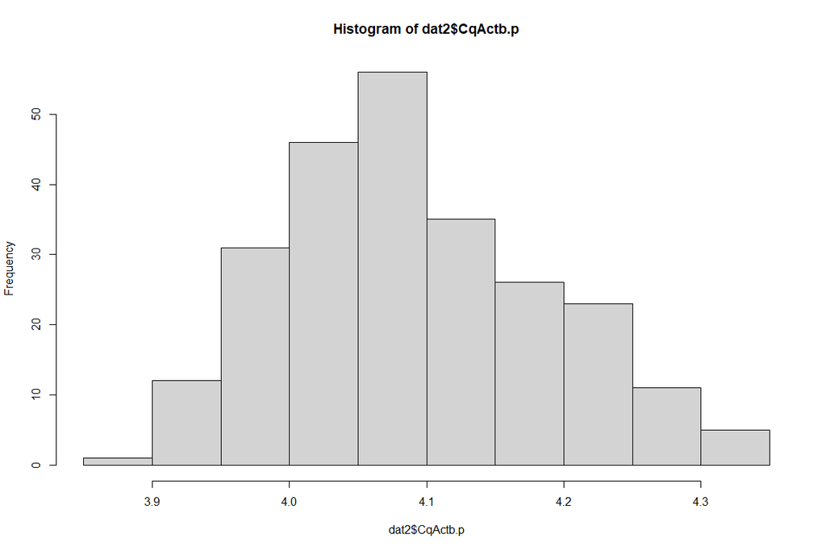

```r
dat2 = dat1[is.na(dat1$CqActb) == F, ]
# transform variable to approx. normality
dat2$CqActb.p <-
  bimixt::boxcox(dat2$CqActb, car::powerTransform(dat2$DeltaCtMtl)$lambda)
hist(dat2$CqActb.p)
```

#### 5.16.7.2 Visualize

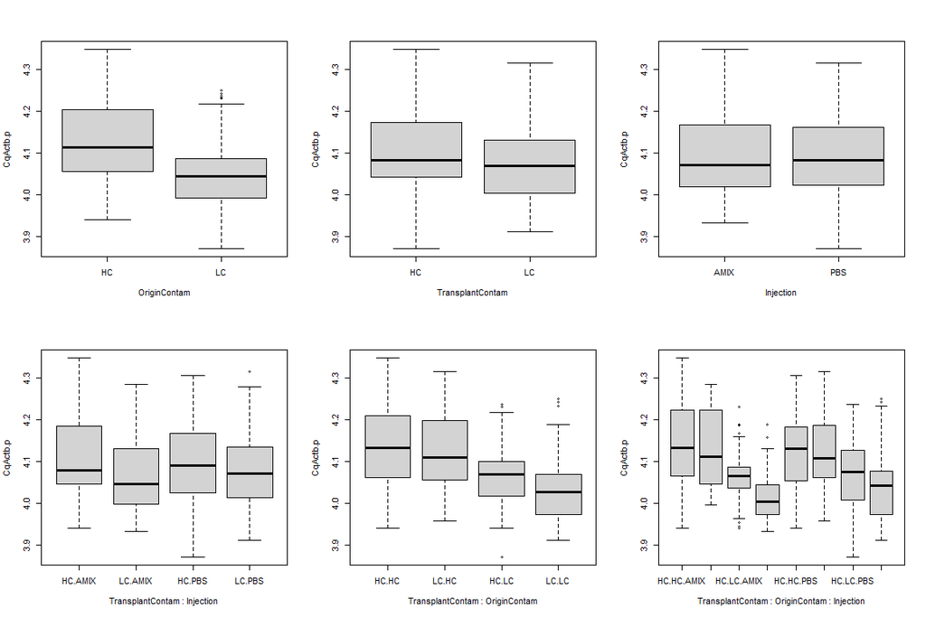

```r
par(mfrow=c(2,3))
boxplot(CqActb.p ~ OriginContam, data = dat2)
boxplot(CqActb.p ~ TransplantContam, data = dat2)
boxplot(CqActb.p ~ Injection, data = dat2)
boxplot(CqActb.p ~ TransplantContam * Injection, data = dat2)
boxplot(CqActb.p ~ TransplantContam * OriginContam, data = dat2)
boxplot(CqActb.p ~ TransplantContam * OriginContam * Injection, data = dat2)
```

#### 5.16.7.3 Build the full model

```r
modfull <-
 lme4::lmer(
    CqActb.p ~ (TransplantContam + OriginContam + Injection) ^ 3 +  SizeEnd +
      (1 | CagingSite /  CageSiteID) + (1| OriginSite),
    data = dat2,
    na.action = na.exclude
  )
car::Anova(modfull, type = "3")
```

```
## Analysis of Deviance Table (Type III Wald chisquare tests)
##
## Response: CqActb.p
##                                             Chisq Df Pr(>Chisq)
## (Intercept)                             4800.4064  1    < 2e-16 ***
## TransplantContam                           0.8446  1    0.35808
## OriginContam                               1.6791  1    0.19504
## Injection                                  1.3007  1    0.25409
## SizeEnd                                    5.3729  1    0.02045 *
## TransplantContam:OriginContam              0.9971  1    0.31800
## TransplantContam:Injection                 0.2766  1    0.59897
## OriginContam:Injection                     0.7924  1    0.37337
## TransplantContam:OriginContam:Injection    0.1447  1    0.70368
## ---
## Signif. codes:  0 '***' 0.001 '**' 0.01 '*' 0.05 '.' 0.1 ' ' 1
```

```r
summary(modfull)
```

```
## Linear mixed model fit by REML ['lmerMod']
## Formula: CqActb.p ~ (TransplantContam + OriginContam + Injection)^3 +
##     SizeEnd + (1 | CagingSite/CageSiteID) + (1 | OriginSite)
##    Data: dat2
##
## REML criterion at convergence: -535
##
## Scaled residuals:
##     Min      1Q  Median      3Q     Max
## -3.4702 -0.6521  0.0416  0.5684  2.5732
##
## Random effects:
##  Groups                Name        Variance  Std.Dev.
##  CageSiteID:CagingSite (Intercept) 2.614e-05 5.112e-03
##  CagingSite            (Intercept) 4.127e-12 2.031e-06
##  OriginSite            (Intercept) 3.204e-03 5.661e-02
##  Residual                          5.145e-03 7.173e-02
## Number of obs: 246, groups:
## CageSiteID:CagingSite, 24; CagingSite, 4; OriginSite, 4
##
## Fixed effects:
##                                                 Estimate Std. Error t value
## (Intercept)                                     4.049539   0.058448  69.285
## TransplantContamLC                             -0.016481   0.017934  -0.919
## OriginContamLC                                 -0.077057   0.059466  -1.296
## InjectionPBS                                   -0.020642   0.018099  -1.140
## SizeEnd                                         0.009387   0.004050   2.318
## TransplantContamLC:OriginContamLC              -0.025505   0.025541  -0.999
## TransplantContamLC:InjectionPBS                 0.013351   0.025388   0.526
## OriginContamLC:InjectionPBS                     0.023410   0.026298   0.890
## TransplantContamLC:OriginContamLC:InjectionPBS  0.013967   0.036720   0.380
##
## Correlation of Fixed Effects:
##             (Intr) TrnCLC OrgCLC InjPBS SizEnd TrCLC:OCLC TCLC:I OCLC:I
## TrnsplntCLC -0.188
## OrignCntmLC -0.518  0.151
## InjectinPBS -0.155  0.481  0.145
## SizeEnd     -0.696  0.051  0.015  0.011
## TrnCLC:OCLC  0.085 -0.699 -0.217 -0.337  0.033
## TrnCLC:IPBS  0.102 -0.684 -0.103 -0.713  0.004  0.481
## OrgCLC:IPBS  0.105 -0.331 -0.206 -0.688 -0.005  0.479      0.490
## TCLC:OCLC:I -0.066  0.473  0.147  0.493 -0.009 -0.676     -0.691 -0.716
## optimizer (nloptwrap) convergence code: 0 (OK)
## boundary (singular) fit: see ?isSingular
```

#### 5.16.7.4 Refining the model

```r
mod2 <-
 lme4::lmer(
    CqActb.p ~ (TransplantContam + OriginContam + Injection) ^ 2 +  SizeEnd +
      (1 | CagingSite /  CageSiteID) + (1| OriginSite),
    data = dat2,
    na.action = na.exclude
  )
car::Anova(mod2, type = "3")
```

```
## Analysis of Deviance Table (Type III Wald chisquare tests)
##
## Response: CqActb.p
##                                   Chisq Df Pr(>Chisq)
## (Intercept)                   4832.5358  1    < 2e-16 ***
## TransplantContam                 1.5556  1    0.21232
## OriginContam                     1.8664  1    0.17188
## Injection                        2.3380  1    0.12625
## SizeEnd                          5.3960  1    0.02018 *
## TransplantContam:OriginContam    1.0097  1    0.31497
## TransplantContam:Injection       1.1990  1    0.27351
## OriginContam:Injection           2.7838  1    0.09522 .
## ---
## Signif. codes:  0 '***' 0.001 '**' 0.01 '*' 0.05 '.' 0.1 ' ' 1
```

```r
summary(mod2)
```

```
## Linear mixed model fit by REML ['lmerMod']
## Formula: CqActb.p ~ (TransplantContam + OriginContam + Injection)^2 +
##     SizeEnd + (1 | CagingSite/CageSiteID) + (1 | OriginSite)
##    Data: dat2
##
## REML criterion at convergence: -539.6
##
## Scaled residuals:
##     Min      1Q  Median      3Q     Max
## -3.4962 -0.6592  0.0368  0.5907  2.6011
##
## Random effects:
##  Groups                Name        Variance  Std.Dev.
##  CageSiteID:CagingSite (Intercept) 0.0000298 0.005459
##  CagingSite            (Intercept) 0.0000000 0.000000
##  OriginSite            (Intercept) 0.0032064 0.056625
##  Residual                          0.0051237 0.071580
## Number of obs: 246, groups:
## CageSiteID:CagingSite, 24; CagingSite, 4; OriginSite, 4
##
## Fixed effects:
##                                    Estimate Std. Error t value
## (Intercept)                        4.051127   0.058276  69.516
## TransplantContamLC                -0.019717   0.015809  -1.247
## OriginContamLC                    -0.080383   0.058838  -1.366
## InjectionPBS                      -0.024034   0.015718  -1.529
## SizeEnd                            0.009389   0.004042   2.323
## TransplantContamLC:OriginContamLC -0.018944   0.018852  -1.005
## TransplantContamLC:InjectionPBS    0.020043   0.018304   1.095
## OriginContamLC:InjectionPBS        0.030569   0.018322   1.668
##
## Correlation of Fixed Effects:
##             (Intr) TrnCLC OrgCLC InjPBS SizEnd TCLC:O TCLC:I
## TrnsplntCLC -0.179
## OrignCntmLC -0.515  0.094
## InjectinPBS -0.141  0.323  0.084
## SizeEnd     -0.697  0.062  0.017  0.018
## TrnCLC:OCLC  0.054 -0.584 -0.162 -0.006  0.036
## TrnCLC:IPBS  0.077 -0.560 -0.002 -0.592 -0.002  0.025
## OrgCLC:IPBS  0.083  0.012 -0.145 -0.552 -0.017 -0.010 -0.009
## optimizer (nloptwrap) convergence code: 0 (OK)
## boundary (singular) fit: see ?isSingular
```

#### 5.16.7.5 Refining the model

```r
mod3 <-
 lme4::lmer(
    CqActb.p ~ TransplantContam + OriginContam + Injection +  SizeEnd +
      (1 | CagingSite /  CageSiteID) + (1| OriginSite),
    data = dat2,
    na.action = na.exclude
  )
car::Anova(mod3, type = "3")
```

```
## Analysis of Deviance Table (Type III Wald chisquare tests)
##
## Response: CqActb.p
##                      Chisq Df Pr(>Chisq)
## (Intercept)      4897.3886  1    < 2e-16 ***
## TransplantContam    4.1955  1    0.04053 *
## OriginContam        1.7623  1    0.18434
## Injection           0.0097  1    0.92168
## SizeEnd             5.7249  1    0.01673 *
## ---
## Signif. codes:  0 '***' 0.001 '**' 0.01 '*' 0.05 '.' 0.1 ' ' 1
```

```r
summary(mod3)
```

```
## Linear mixed model fit by REML ['lmerMod']
## Formula: CqActb.p ~ TransplantContam + OriginContam + Injection + SizeEnd +
##     (1 | CagingSite/CageSiteID) + (1 | OriginSite)
##    Data: dat2
##
## REML criterion at convergence: -553
##
## Scaled residuals:
##     Min      1Q  Median      3Q     Max
## -3.3786 -0.6177 -0.0041  0.6109  2.6272
##
## Random effects:
##  Groups                Name        Variance  Std.Dev.
##  CageSiteID:CagingSite (Intercept) 1.954e-05 0.004421
##  CagingSite            (Intercept) 0.000e+00 0.000000
##  OriginSite            (Intercept) 3.162e-03 0.056233
##  Residual                          5.176e-03 0.071946
## Number of obs: 246, groups:
## CageSiteID:CagingSite, 24; CagingSite, 4; OriginSite, 4
##
## Fixed effects:
##                      Estimate Std. Error t value
## (Intercept)         4.0407558  0.0577405  69.981
## TransplantContamLC -0.0193609  0.0094523  -2.048
## OriginContamLC     -0.0756946  0.0570200  -1.328
## InjectionPBS        0.0009043  0.0091975   0.098
## SizeEnd             0.0097049  0.0040561   2.393
##
## Correlation of Fixed Effects:
##             (Intr) TrnCLC OrgCLC InjPBS
## TrnsplntCLC -0.178
## OrignCntmLC -0.508  0.001
## InjectinPBS -0.085 -0.007  0.005
## SizeEnd     -0.707  0.137  0.021  0.012
## optimizer (nloptwrap) convergence code: 0 (OK)
## boundary (singular) fit: see ?isSingular
```

#### 5.16.7.6 Refining the model

```r
mod4 <-
 lme4::lmer(
    CqActb.p ~  TransplantContam + SizeEnd +
      (1 | CagingSite /  CageSiteID) + (1| OriginSite),
    data = dat2,
    na.action = na.exclude
  )
car::Anova(mod4, type = "3")
```

```
## Analysis of Deviance Table (Type III Wald chisquare tests)
##
## Response: CqActb.p
##                      Chisq Df Pr(>Chisq)
## (Intercept)      6027.3927  1    < 2e-16 ***
## TransplantContam    4.2031  1    0.04035 *
## SizeEnd             5.6332  1    0.01762 *
## ---
## Signif. codes:  0 '***' 0.001 '**' 0.01 '*' 0.05 '.' 0.1 ' ' 1
```

```r
summary(mod4)
```

```
## Linear mixed model fit by REML ['lmerMod']
## Formula: CqActb.p ~ TransplantContam + SizeEnd + (1 | CagingSite/CageSiteID) +
##     (1 | OriginSite)
##    Data: dat2
##
## REML criterion at convergence: -562.7
##
## Scaled residuals:
##     Min      1Q  Median      3Q     Max
## -3.3849 -0.6200 -0.0148  0.6192  2.6233
##
## Random effects:
##  Groups                Name        Variance  Std.Dev.
##  CageSiteID:CagingSite (Intercept) 2.177e-05 0.004666
##  CagingSite            (Intercept) 0.000e+00 0.000000
##  OriginSite            (Intercept) 3.999e-03 0.063237
##  Residual                          5.153e-03 0.071785
## Number of obs: 246, groups:
## CageSiteID:CagingSite, 24; CagingSite, 4; OriginSite, 4
##
## Fixed effects:
##                     Estimate Std. Error t value
## (Intercept)         4.004158   0.051576  77.636
## TransplantContamLC -0.019377   0.009452  -2.050
## SizeEnd             0.009624   0.004055   2.373
##
## Correlation of Fixed Effects:
##             (Intr) TrnCLC
## TrnsplntCLC -0.199
## SizeEnd     -0.779  0.137
## optimizer (nloptwrap) convergence code: 0 (OK)
## boundary (singular) fit: see ?isSingular
```

Now that we have identified the best model, add sex as covariate to check whether results are sensitive NB: sample size is reduced when adding sex variable within the model, for this reason the sex effect on results is checked on the final model

#### 5.16.7.7 Test for the sex effect

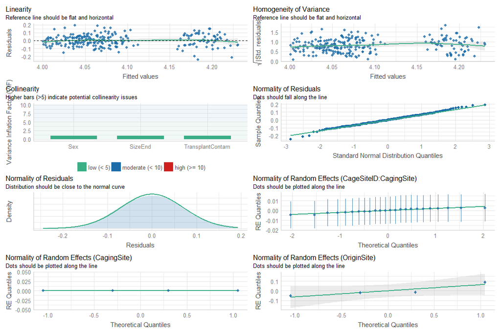

```r
dat2 = dat2[is.na(dat2$Sex) == F, ]
modSex <-
 lme4::lmer(
    CqActb.p ~  TransplantContam + SizeEnd + Sex +
      (1 | CagingSite /  CageSiteID) + (1| OriginSite),
    data = dat2,
    na.action = na.exclude
  )
performance::check_model(modSex)
```

```r
car::Anova(modSex, type = "3")
```

```
## Analysis of Deviance Table (Type III Wald chisquare tests)
##
## Response: CqActb.p
##                      Chisq Df Pr(>Chisq)
## (Intercept)      6037.4561  1    < 2e-16 ***
## TransplantContam    3.8189  1    0.05068 .
## SizeEnd             6.0967  1    0.01354 *
## Sex                 1.1895  1    0.27544
## ---
## Signif. codes:  0 '***' 0.001 '**' 0.01 '*' 0.05 '.' 0.1 ' ' 1
```

```r
summary(modSex)
```

```
## Linear mixed model fit by REML ['lmerMod']
## Formula:
## CqActb.p ~ TransplantContam + SizeEnd + Sex + (1 | CagingSite/CageSiteID) +
##     (1 | OriginSite)
##    Data: dat2
##
## REML criterion at convergence: -553
##
## Scaled residuals:
##     Min      1Q  Median      3Q     Max
## -3.3943 -0.6446  0.0074  0.6235  2.6828
##
## Random effects:
##  Groups                Name        Variance  Std.Dev.
##  CageSiteID:CagingSite (Intercept) 0.0000548 0.007403
##  CagingSite            (Intercept) 0.0000000 0.000000
##  OriginSite            (Intercept) 0.0039459 0.062816
##  Residual                          0.0051468 0.071741
## Number of obs: 245, groups:
## CageSiteID:CagingSite, 24; CagingSite, 4; OriginSite, 4
##
## Fixed effects:
##                     Estimate Std. Error t value
## (Intercept)         4.003488   0.051524  77.701
## TransplantContamLC -0.019078   0.009763  -1.954
## SizeEnd             0.010094   0.004088   2.469
## SexM               -0.010466   0.009596  -1.091
##
## Correlation of Fixed Effects:
##             (Intr) TrnCLC SizEnd
## TrnsplntCLC -0.199
## SizeEnd     -0.778  0.136
## SexM         0.024 -0.041 -0.117
## optimizer (nloptwrap) convergence code: 0 (OK)
## boundary (singular) fit: see ?isSingular
```

```r
modActb <- modSex
RmodActb <- MuMIn::r.squaredGLMM(modActb)
```

## 5.17 Summary of the best models for gene expression (Table 4 from the manuscript)

The following table report the results of the best models tested above, this table correspond to the Table 4 in the manuscript. The table report the marginal and conditional Rsquared (R2m and R2c respectively).

|  |  | Estimate | Std. Error | t or z value | df | Chisq | p.value |
| --- | --- | --- | --- | --- | --- | --- | --- |
| **Mtl - Metallothionein \| n = 245 \| R2m = 0.113 \| R2c = 0.191** |  |  |  |  |  |  |  |
| Metal sequestration | Intercept | 1.325 | 0.2367 | 5.597 | 1 | 31.33 | <0.0001 |
|  | Origin | -0.7395 | 0.3267 | -2.263 | 1 | 5.123 | <0.05 |
|  | Sex | -0.2866 | 0.1392 | -2.058 | 1 | 4.237 | <0.05 |
| **Cat - Catalase \| n = 245 \| R2m = 0.0582 \| R2c = 0.523** |  |  |  |  |  |  |  |
| Antioxidant - Cat | Intercept | -3.176 | 0.2213 | -14.35 | 1 | 205.9 | <0.0001 |
|  | Imm. challenge | 0.1011 | 0.03811 | 2.653 | 1 | 7.04 | <0.01 |
|  | Size | 0.05157 | 0.0169 | 3.05 | 1 | 9.305 | <0.01 |
|  | Sex | -0.09578 | 0.03967 | -2.414 | 1 | 5.829 | <0.05 |
| **Gpx - Glutathione peroxidase \| n = 245 \| R2m = 0.0918 \| R2c = 0.135** |  |  |  |  |  |  |  |
| Antioxidant - Gpx | Intercept | -1.075 | 0.1013 | -10.61 | 1 | 112.5 | <0.0001 |
|  | Origin | -0.3485 | 0.1372 | -2.54 | 1 | 6.454 | <0.05 |
|  | Sex | -0.1812 | 0.07875 | -2.301 | 1 | 5.293 | <0.05 |
| **Casp3 - Caspase 3 \| n = 246 \| R2m = 0.253 \| R2c = 0.255** |  |  |  |  |  |  |  |
| Apoptosis effector | Intercept | -5.19 | 0.3157 | -16.44 | 1 | 270.2 | <0.0001 |
|  | Origin | -0.4416 | 0.09848 | -4.484 | 1 | 20.11 | <0.0001 |
|  | Size | 0.2174 | 0.03106 | 6.999 | 1 | 48.99 | <0.0001 |
| **Pcx - Pyruvate carboxylase \| n = 239 \| R2m = 0.0289 \| R2c = 0.432** |  |  |  |  |  |  |  |
| Energy metabolism (oxaloacetate synthesis & gluconeogenesis) | Intercept | -3.255 | 0.1644 | -19.8 | 1 | 392.1 | <0.0001 |
|  | Imm. challenge | 0.1224 | 0.05021 | 2.438 | 1 | 5.946 | <0.05 |
|  | Sex | -0.1166 | 0.05255 | -2.219 | 1 | 4.924 | <0.05 |
| **Pygl - Glycogen phosphorylase \| n = 226 \| R2m = 0.0369 \| R2c = 0.181** |  |  |  |  |  |  |  |
| Energy metabolism (glycogen breakdown to produce glucose) | Intercept | -2.471 | 0.07492 | -32.98 | 1 | 1088 | <0.0001 |
|  | Imm. challenge | 0.1555 | 0.04896 | 3.175 | 1 | 10.08 | <0.01 |

# 7 References

Costantini, D., Dell’Omo, G., 2006. Effects of T-cell-mediated immune response on avian oxidative stress. Comp. Biochem. Physiol. A. Mol. Integr. Physiol. 145, 137–142. https://doi.org/10.1016/j.cbpa.2006.06.002.

Jacquin, L., Reader, S.M., Boniface, A., Mateluna, J., Patalas, I., Pérez-Jvostov, F., Hendry, A.P., 2016. Parallel and nonparallel behavioural evolution in response to parasitism and predation in Trinidadian guppies. J. Evol. Biol. 29, 1406–1422. https://doi.org/10.1111/jeb.12880.

Petitjean, Q., Jacquin, L., Riem, L., Pitout, M., Perrault, A., Cousseau, M., Laffaille, P., Jean, S., 2020a. Intraspecific variability of responses to combined metal contamination and immune challenge among wild fish populations. Environ. Pollut. 116042. https://doi.org/10.1016/j.envpol.2020.116042.

Petitjean, Q., Jean, S., Côte, J., Larcher, T., Angelier, F., Ribout, C., Perrault, A., Laffaille, P., Jacquin, L., 2020b. Direct and indirect effects of multiple environmental stressors on fish health in human-altered rivers. Sci. Total Environ. 742, 140657. https://doi.org/10.1016/j.scitotenv.2020.140657.